# SENDAs Agreement 1 Update 2010-2022

First step of deduplication process. Exploratory data analysis was conducted, addressing issues such as data entry errors, missing values, and the conversion of the date of birth into the age at the time of the first discharge for each individual.

Author

Andrés González Santa Cruz

Published

September 27, 2025

# Data Loading and Exploration

## Loading Packages and uniting databases

Proceed to load the necessary packages.

```r
# invisible("Only run from Ubuntu")
# if (!(Sys.getenv("RSTUDIO_SESSION_TYPE") == "server" || file.exists("/.dockerenv"))) {
#   if(Sys.info()["sysname"]!="Windows"){
#     Sys.setenv(RETICULATE_PYTHON = "/home/fondecytacc/.pyenv/versions/3.11.5/bin/python")
#   }
# }

#clean enviroment
rm(list = ls()); gc()

time_before_dedup1<-Sys.time()

#:#:#:#:#:#:#:#:#:#:#:#:#:#:#:#:#:#:#:#:#:#:#:#:#:#:#:#:#:#:#:#:#:#:#:#:
#:#:#:#:#:#:#:#:#:#:#:#:#:#:#:#:#:#:#:#:#:#:#:#:#:#:#:#:#:#:#:#:#:#:#:#:#:#:#:#:
#:#:#:#:#:#:#:#:#:#:#:#:#:#:#:#:#:#:#:#:#:#:#:#:#:#:#:#:#:#:#:#:#:#:#:#:
# --- Bootstrap reticulate con ruta relativa a getwd() ---
suppressPackageStartupMessages(library(reticulate))

# Busca .mamba_root/envs/py311/python.exe desde getwd() hacia padres
find_python_rel <- function(start = getwd(),
                            rel = file.path(".mamba_root","envs","py311","python.exe")) {
  cur <- normalizePath(start, winslash = "/", mustWork = FALSE)
  repeat {
    cand <- normalizePath(file.path(cur, rel), winslash = "/", mustWork = FALSE)
    if (file.exists(cand)) return(cand)
    parent <- dirname(cur)
    if (identical(parent, cur)) return(NA_character_)  # llegó a la raíz
    cur <- parent
  }
}

py <- find_python_rel()

if (is.na(py)) {
  stop("No se encontró Python relativo a getwd() (buscando '.mamba_root/envs/py311/python.exe').\n",
       "Directorio actual: ", getwd())
}

# Forzar ese intérprete
Sys.unsetenv(c("RETICULATE_CONDAENV","RETICULATE_PYTHON_FALLBACK"))
Sys.setenv(RETICULATE_PYTHON = py)
reticulate::use_python(py, required=T)

py_config()  # verificación


#_#_#_#_#_#_#_#_#_#_#_#_#_#_#_#_#_#_#_#_#_#_#_#_#_#_#_#_#_#_#_#_#_#_#_#_
#_#_#_#_#_#_#_#_#_#_#_#_#_#_#_#_#_#_#_#_#_#_#_#_#_#_#_#_#_#_#_#_#_#_#_#_

# tidy, robust, and commented
load_ndp <- function(date_tag,
                     base_name,
                     input_subdir,
                     out_subdir,
                     load_into    = .GlobalEnv) {

  # Are we in RStudio Server or Docker?
  is_server <- Sys.getenv("RSTUDIO_SESSION_TYPE") == "server" || file.exists("/.dockerenv")

  # Project root = current WD without a trailing "/cons"
  # Safer than gsub everywhere
  wd <- getwd()
  project_root <- sub("(/)?cons/?$", "", wd)

  # Build dirs
  out_dir  <- file.path(project_root, out_subdir)
  in_dir   <- if (is_server) file.path(getwd(), input_subdir) else out_dir

  # Filenames (choose one canonical extension spelling)
  rdata_file   <- sprintf("%s_%s.Rdata", base_name, date_tag)
  seven_z_part <- sprintf("%s_%s.Rdata.7z.001", base_name, date_tag)
  enc_file     <- sprintf("%s_%s.Rdata.enc",  base_name, date_tag)  # only if you actually encrypt to .enc

  # Optional: Windows drive-based Google Drive/E: fallback (only on Windows)
  envpath <- NULL
  if (.Platform$OS.type == "windows") {
    drv <- toupper(substr(normalizePath(project_root, winslash = "\\", mustWork = FALSE), 1, 1))
    envpath <- if (identical(drv, "G")) {
      "G:/Mi unidad/Alvacast/SISTRAT 2023/"
    } else {
      "E:/Mi unidad/Alvacast/SISTRAT 2023/"
    }
  }
  # message("envpath: ", envpath %||% "<none>")

  # Ensure dirs exist (won't error if already present)
  dir.create(out_dir, recursive = TRUE, showWarnings = FALSE)

  # Helper: load Rdata into the specified environment
  load_rdata <- function(path) {
    stopifnot(file.exists(path))
    loaded <- load(path, envir = load_into)
    message("Loaded objects: ", paste(loaded, collapse = ", "))
    invisible(loaded)
  }

  if (!is_server) {
    # Desktop workflow: expect plain .Rdata in out_dir
    local_rdata <- file.path(out_dir, rdata_file)
    if (!file.exists(local_rdata)) {
      stop("Rdata file not found: ", local_rdata)
    }
    return(load_rdata(local_rdata))

  } else {
    # Server/Docker workflow: expect compressed/encrypted parts in _input
    seven_z_path <- file.path(in_dir, seven_z_part)
    enc_path     <- file.path(in_dir, enc_file)
    out_rdata    <- file.path(out_dir, rdata_file)

    if (file.exists(seven_z_path)) {
      # Extract 7z multi-part to out_dir using password
      pass <- Sys.getenv("PASS_PPIO", unset = NA_character_)
      if (is.na(pass) || pass == "") stop("Missing PASS_PPIO env var for 7z decryption.")
      # 7z command: x (extract), -p<pass>, -o<outdir>
      args <- c("x", shQuote(seven_z_path), sprintf("-p%s", pass), paste0("-o", shQuote(out_dir)))
      status <- system2("7z", args = args, stdout = TRUE, stderr = TRUE)
      # Optional: check extraction result
      if (!file.exists(out_rdata)) {
        stop("Extraction finished but target not found: ", out_rdata, "\n7z output:\n", paste(status, collapse = "\n"))
      }
      return(load_rdata(out_rdata))

    } else if (file.exists(enc_path)) {
      # If you truly have a raw .enc, you need a decryption step here (not loadable as-is).
      stop("Found encrypted file but no extractor defined for .enc: ", enc_path)

    } else if (file.exists(out_rdata)) {
      # Already extracted earlier
      return(load_rdata(out_rdata))

    } else {
      stop("No input found in: ", in_dir,
           "\nTried: ", seven_z_path, " and ", enc_path,
           "\nAlso looked for already-extracted: ", out_rdata)
    }
  }
}

load_ndp(date_tag = "2025_09_27",
                     base_name = "22_ndp",
                     input_subdir = "_input",
                     out_subdir   = file.path("data", "20241015_out"),
                     load_into    = .GlobalEnv)
```

```
          used (Mb) gc trigger (Mb) max used (Mb)
Ncells  607621 32.5    1282490 68.5  1164779 62.3
Vcells 1246965  9.6    8388608 64.0  2184548 16.7
python:         G:/My Drive/Alvacast/SISTRAT 2023/.mamba_root/envs/py311/python.exe
libpython:      G:/My Drive/Alvacast/SISTRAT 2023/.mamba_root/envs/py311/python311.dll
pythonhome:     G:/My Drive/Alvacast/SISTRAT 2023/.mamba_root/envs/py311
version:        3.11.5 | packaged by conda-forge | (main, Aug 27 2023, 03:23:48) [MSC v.1936 64 bit (AMD64)]
Architecture:   64bit
numpy:           [NOT FOUND]

NOTE: Python version was forced by RETICULATE_PYTHON
```

```r
#https://github.com/rstudio/renv/issues/544
#renv falls back to copying rather than symlinking, which is evidently very slow in this configuration.
renv::settings$use.cache(FALSE)

#only use explicit dependencies (in DESCRIPTION)
renv::settings$snapshot.type("implicit")

#check if rstools is installed
try(installr::install.Rtools(check_r_update=F))
```

Installing package into ‘G:/My Drive/Alvacast/SISTRAT 2023/renv/library/windows/R-4.4/x86_64-w64-mingw32’ (as ‘lib’ is unspecified)

```r
if(!quarto::quarto_version()>="1.7.29"){
stop("You need to install a recent quarto version")   # la publicada el 28-abr-2025
}

#change repository to CL
local({
  r <- getOption("repos")
  r["CRAN"] <- "https://cran.dcc.uchile.cl/"
  options(repos=r)
})

if(!require(pacman)){install.packages("pacman");require(pacman)}
```

Cargando paquete requerido: pacman

```r
if(!require(pak)){install.packages("pak");require(pak)}
```

Cargando paquete requerido: pak

```r
pacman::p_unlock(lib.loc = .libPaths()) #para no tener problemas reinstalando paquetes
```

No 00LOCK detected in: G:/My Drive/Alvacast/SISTRAT 2023/renv/library/windows/R-4.4/x86_64-w64-mingw32 No 00LOCK detected in: C:/Program Files/R/R-4.4.1/library

```r
if(Sys.info()["sysname"]=="Windows"){
if (getRversion() != "4.4.1") { stop("Requires R version 4.4.1; Actual: ", getRversion()) }
}

#check docker
check_docker_running <- function() {
  # Try running 'docker info' to check if Docker is running
  system("docker info", intern = TRUE, ignore.stderr = TRUE)
}

install_docker <- function() {
  # Open the Docker Desktop download page in the browser for installation
  browseURL("https://www.docker.com/products/docker-desktop")
}

# Main logic
if (inherits(try(check_docker_running(), silent = TRUE), "try-error")) {
  liftr::install_docker()
} else {
  message("Docker is running.")
}
```

Warning in system(“docker info”, intern = TRUE, ignore.stderr = TRUE): el comando ejecutado ‘docker info’ tiene el estatus 1

Docker is running.

```r
#_#_#_#_#_#_#_#_#_#_#_#_#_#_#_#_#_#_#_#_#_#_#_#_#_#_#_#_#_#_#_#_#_#_#_#_#_#_#_#_
#PACKAGES#######################################################################
#_#_#_#_#_#_#_#_#_#_#_#_#_#_#_#_#_#_#_#_#_#_#_#_#_#_#_#_#_#_#_#_#_#_#_#_#_#_#_#_

unlink("*_cache", recursive=T)

# ----------------------------------------------------------------------
# 2. Use a single pak::pkg_install() call for most CRAN packages
# ----------------------------------------------------------------------

paks <-
  c(#"git",
    # To connect to github
    "gh", #interface for  GitHub API from R
    #
    "gitcreds", # manages Git credentials (usernames, passwords, tokens)
    #
    "usethis", # simplifies common project setup tasks for R developers
    # Package to bring packages in development
    "devtools",
    # Package administration
    "renv",
    # To manipulate data
    "knitr", "pander", "DT",
    # Join
    "fuzzyjoin",
    # For tables
    "tidyverse", "janitor",
    # For contingency tables
    "kableExtra",
    # For connections with python
    "reticulate",
    # To manipulate big data
    "polars", "sqldf",
    # To bring big databases
    "nanoparquet",
    # Interface for R and RStudio in R
    "installr", "rmarkdown", "quarto", "yaml", #"rstudioapi",
    # Time handling
    "clock",
    # Combine plots
    "ggpubr",
    # Parallelized iterative processing
    "furrr",
    # Work like a tibble with a data.table database
    "tidytable",
    # Split database into training and testing
    "caret",
    # Impute missing data
    "missRanger", "mice",
    # To modularize tasks
    "job",
    # For PhantomJS install checks
    "webshot"
  )

# dplyr
# janitor
# reshape2
# tidytable
# arrow
# boot
# broom
# car
# caret
# data.table
# DiagrammeR
# DiagrammeRsvg
# dplyr
# epiR
# epitools
# ggplot2
# glue
# htmlwidgets
# knitr
# lubridate
# naniar
# parallel
# polycor
# pROC
# psych
# readr
# rio
# rsvg
# scales
# stringr
# tableone
# rmarkdown
# biostat3
# codebook
# finalfit
# Hmisc
# kableExtra
# knitr
# devtools
# tidyr
# stringi
# stringr
# muhaz
# sqldf
# compareGroups
# survminer
# lubridate
# ggfortify
# car
# fuzzyjoin
# compareGroups
# caret
# job
# htmltools
# nanoparquet
# ggpubr
# polars
# installr
# clock
# pander
# reshape
# mice
# missRanger
# VIM
# withr
# biostat3
# broom
# glue
# finalfit
# purrr
# sf


# pak::pkg_install(paks)

pak::pak_sitrep()
# pak::sysreqs_check_installed(unique(unlist(paks)))
#pak::lockfile_create(unique(unlist(paks)),  "dependencies_duplicates24.lock", dependencies=T)
#pak::lockfile_install("dependencies_duplicates24.lock")
#https://rdrr.io/cran/pak/man/faq.html
#pak::cache_delete()

library(tidytable)
```

Adjuntando el paquete: ‘tidytable’

The following objects are masked from ‘package:stats’:

```
dt, filter, lag
```

The following object is masked from ‘package:base’:

```
%in%
```

```r
library(polars)
```

Warning: package ‘polars’ was built under R version 4.4.3

```r
library(ggplot2)
library(readr)
```

Adjuntando el paquete: ‘readr’

The following object is masked *by* ‘.GlobalEnv’:

```
parse_date
```

```r
# ----------------------------------------------------------------------
# 3. Activate polars code completion (safe to try even if it fails)
# ----------------------------------------------------------------------
try(polars_code_completion_activate())
```

Using code completion in ‘native’ mode.

```r
# ----------------------------------------------------------------------
# 4. BPMN from GitHub (not on CRAN, so install via devtools if missing)
# ----------------------------------------------------------------------
if (!requireNamespace("bpmn", quietly = TRUE)) {
  devtools::install_github("bergant/bpmn")
}

# ----------------------------------------------------------------------
# 5. PhantomJS Check (use webshot if PhantomJS is missing)
# ----------------------------------------------------------------------
if (!webshot::is_phantomjs_installed()) {
  webshot::install_phantomjs()
}

#_#_#_#_#_#_#_#_#_#_#_#_#_#_#_#_#_#_#_#_#_#_#_#_#_#_#_#_#_#_#_#_#_#_#_#_#_#_#_#_
#FUNCTIONS######################################################################
#_#_#_#_#_#_#_#_#_#_#_#_#_#_#_#_#_#_#_#_#_#_#_#_#_#_#_#_#_#_#_#_#_#_#_#_#_#_#_#_


#WINDOWS do not restrict memory size
if(.Platform$OS.type == "windows") withAutoprint({
  memory.size()
  memory.size(TRUE)
  memory.limit()
})
```

Warning: ‘memory.size()’ is no longer supported

Warning: ‘memory.size()’ is no longer supported

Warning: ‘memory.limit()’ is no longer supported

```r
memory.limit(size=56000)
```

Warning: ‘memory.limit()’ is no longer supported

```r
#:#:#:#:#:#:#:#:#:#:#:#:#:#:#:#:#:#:#:#:#:#:#:#:#:#:#:#:#:#:#:#:#:#:#:#:#:#:#:#:#:#:#:#:#:#:#:#:#:#:#:#:#:#:#:
# NO MORE DEBUGS
options(error = NULL)        # si antes tenías options(error = recover) o browser)
options(browserNLdisabled = FALSE)

#:#:#:#:#:#:#:#:#:#:#:#:#:#:#:#:#:#:#:#:#:#:#:#:#:#:#:#:#:#:#:#:#:#:#:#:#:#:#:#:#:#:#:#:#:#:#:#:#:#:#:#:#:#:#:
# CORRECT PROBLEMATIC DATES
# 1) Smart parser for messy date strings
parse_date_smart <- function(x) {
    x <- x %>%
        stringr::str_squish() %>%
        stringr::str_replace_all("[^0-9/\\-\\.]", "") %>%   # keep digits and common seps
        na_if("") %>%
        na_if("00000000") %>%
        na_if("00/00/0000") %>%
        na_if("0")

    # try ymd, then dmy, then mdy (quietly)
    y <- suppressWarnings(lubridate::ymd(x))
    y <- coalesce(y, suppressWarnings(lubridate::dmy(x)))
    y <- coalesce(y, suppressWarnings(lubridate::mdy(x)))
    as.Date(y)
}

# 2) Birth-date validity (range + age cap)
is_valid_birth <- function(d, ref_date = Sys.Date(),
                           min_year = 1900, max_age = 100) {
    if (is.null(d)) return(rep(FALSE, length(d)))
    d_ok <- !is.na(d) &
        d >= as.Date(sprintf("%d-01-01", min_year)) &
        d <= ref_date &
        (as.integer(lubridate::time_length(lubridate::interval(d, ref_date), "years")) <= max_age)
    d_ok
}

# 3) Generic applier: uses 'row' from the problems table to update df[[target_col]]
apply_date_corrections <- function(df, problems,
                                   target_col = "birth_date",
                                   row_col    = "row",
                                   actual_col = "actual") {
    n <- nrow(df)

    corr <- problems %>%
        transmute(
            .row   = !!sym(row_col),
            parsed = parse_date_smart(!!sym(actual_col))
        ) %>%
        filter(.row >= 1, .row <= n) %>%
        mutate(valid = is_valid_birth(parsed)) %>%
        filter(valid)

    if (nrow(corr)) {
        df[[target_col]][corr$.row] <- corr$parsed
    }
    df
}
#:#:#:#:#:#:#:#:#:#:#:#:#:#:#:#:#:#:#:#:#:#:#:#:#:#:#:#:#:#:#:#:#:#:#:#:#:#:#:#:#:#:#:#:#:#:#:#:#:#:#:#:#:#:#:
#NAs are replaced with "" in knitr kable
options(knitr.kable.NA = '')

pander::panderOptions('big.mark', ',')
pander::panderOptions('decimal.mark', '.')

#:#:#:#:#:#:#:#:#:#:#:#:#:#:#:#:#:#:#:#:#:#:#:#:#:#:#:#:#:#:#:#:#:#:#:#:#:#:#:#:#:#:#:#:#:#:#:#:#:#:#:#:#:#:#:
#
#to format rows in bold
format_cells <- function(df, rows ,cols, value = c("italics", "bold", "strikethrough")){

  # select the correct markup
  # one * for italics, two ** for bold
  map <- setNames(c("*", "**", "~~"), c("italics", "bold", "strikethrough"))
  markup <- map[value]

  for (r in rows){
    for(c in cols){

      # Make sure values are not factors
      df[[c]] <- as.character( df[[c]])

      # Update formatting
      df[r, c] <- ifelse(nchar(df[r, c])==0,"",paste0(markup, gsub(" ", "", df[r, c]), markup))
    }
  }

  return(df)
}
#To produce line breaks in messages and warnings
knitr::knit_hooks$set(
   error = function(x, options) {
     paste('\n\n<div class="alert alert-danger" style="font-size: small !important;">',
           gsub('##', '\n', gsub('^##\ Error', '**Error**', x)),
           '</div>', sep = '\n')
   },
   warning = function(x, options) {
     paste('\n\n<div class="alert alert-warning" style="font-size: small !important;">',
           gsub('##', '\n', gsub('^##\ Warning:', '**Warning**', x)),
           '</div>', sep = '\n')
   },
   message = function(x, options) {
     paste('<div class="message" style="font-size: small !important;">',
           gsub('##', '\n', x),
           '</div>', sep = '\n')
   }
)

#:#:#:#:#:#:#:#:#:#:#:#:#:#:#:#:#:#:#:#:#:#:#:#:#:#:#:#:#:#:#:#:#:#:#:#:#:#:#:#:#:#:#:#:#:#:#:#:#:#:#:#:#:#:#:

sum_dates <- function(x){

  cbind.data.frame(
min= as.Date(min(unclass(as.Date(x)), na.rm=T), origin = "1970-01-01"),
p001= as.Date(quantile(unclass(as.Date(x)), .001, na.rm=T), origin = "1970-01-01"),
p005= as.Date(quantile(unclass(as.Date(x)), .005, na.rm=T), origin = "1970-01-01"),
p025= as.Date(quantile(unclass(as.Date(x)), .025, na.rm=T), origin = "1970-01-01"),
p25= as.Date(quantile(unclass(as.Date(x)), .25, na.rm=T), origin = "1970-01-01"),
p50= as.Date(quantile(unclass(as.Date(x)), .5, na.rm=T), origin = "1970-01-01"),
p75= as.Date(quantile(unclass(as.Date(x)), .75, na.rm=T), origin = "1970-01-01"),
p975= as.Date(quantile(unclass(as.Date(x)), .975, na.rm=T), origin = "1970-01-01"),
p995= as.Date(quantile(unclass(as.Date(x)), .995, na.rm=T), origin = "1970-01-01"),
p999= as.Date(quantile(unclass(as.Date(x)), .999, na.rm=T), origin = "1970-01-01"),
max= as.Date(max(unclass(as.Date(x)), na.rm=T), origin = "1970-01-01")
  )
}

#:#:#:#:#:#:#:#:#:#:#:#:#:#:#:#:#:#:#:#:#:#:#:#:#:#:#:#:#:#:#:#:#:#:#:#:#:#:#:#:#:#:#:#:#:#:#:#:#:#:#:#:#:#:#:

# Define the function adapted for Polars
sum_dates_polars <- function(df, date_col) {
  # Create the list of quantiles
  quantiles <- c(0.001, 0.005, 0.025, 0.25, 0.5, 0.75, 0.975, 0.995, 0.999)
  # Create expressions to calculate min and max
  expr_list <- list(
    pl$col(date_col)$min()$alias("min"),
    pl$col(date_col)$max()$alias("max")
  )
  # Add expressions for quantiles
  for (q in quantiles) {
    expr_list <- append(expr_list, pl$col(date_col)$quantile(q)$alias(paste0("p", sub("\\.", "", as.character(q)))))
  }
  # Apply the expressions and return a DataFrame with the results
  df$select(expr_list)
}

# Custom function for sampling with a seed
sample_n_with_seed <- function(data, size, seed) {
  set.seed(seed)
  dplyr::sample_n(data, size)
}

# Function to get the most frequent value
most_frequent <- function(x) {
  uniq_vals <- unique(x)
  freq_vals <- sapply(uniq_vals, function(val) sum(x == val))
  most_freq <- uniq_vals[which(freq_vals == max(freq_vals))]

  if (length(most_freq) == 1) {
    return(most_freq)
  } else {
    return(NA)
  }
}
#_#_#_#_#_#_#_#_#_#_#_#_#_#_#_#_#_#_#_#_#_#_#_#_#_#_#_#_#_#_#_#_#_#_#_#_#_#_#_#_
#CONFIG #######################################################################
#_#_#_#_#_#_#_#_#_#_#_#_#_#_#_#_#_#_#_#_#_#_#_#_#_#_#_#_#_#_#_#_#_#_#_#_#_#_#_#_

options(scipen=2) #display numbers rather scientific number

#_#_#_#_#_#_#_#_#_#_#_#_#_#_#_#_#_#_#_#_#_#_#_#_#_#_#_#_#_#_#_#_#_#_#_#_#_#_#_#_
```

[output not shown]

**Note**

To assess the main goals of the study, we first focused on **distinguishing each user** across the yearly datasets obtained from SENDA (1). Next, we **separated each user’s treatments** (2). Finally, we **normalized, standardized, and cleaned each treatment** (3). Although these stages may appear conceptually separate and sequential, they are interdependent (e.g., some variables needed to be standardized to identify duplicate entries). Throughout this document, we use the terms **“rows”**, **“cases”**, **“observations”** or **“treatment episodes”** interchangeably to refer to entries in the dataset.

## 0. Correct dates

In this section, we address missing or inconsistent dates within the dataset. First, we add a row number to uniquely identify each observation, especially useful for tracking deleted rows. Then, we replace missing birth dates with a default value, recording the manual correction in an observation column (`OBS`). Next, for missing admission dates, we attempt to replace them with corresponding SENDA dates where available, again updating `OBS`. Finally, we handle problematic discharge dates by examining rows with missing or unusual values and making targeted corrections. Specifically, we use conditional logic to update discharge dates based on unique `hash_key` and `adm_date` combinations, ensuring consistency in treatment timelines. Any remaining issues with discharge date parsing are logged for further review, and prior versions of the discharge date column are removed to maintain consistency.

```r
cat("HASH_KEY for hash_key\n")
colnames(SISTRAT23_c1_2010_2024_df2)[colnames(SISTRAT23_c1_2010_2024_df2) == "HASH_KEY"] <- "hash_key"

cat(paste0("Added row number (rn) to identify deleted observations: ",formatC(nrow(SISTRAT23_c1_2010_2024_df2), big.mark=",")," in total\n"))
SISTRAT23_c1_2010_2024_df2$rn <-1:nrow(SISTRAT23_c1_2010_2024_df2)

#_#_#_#_#_#_#_#_#_#_#_#_#_#_#_#_#_#_#_#_#_#_#_#_#_#_#_#_#_#_
cat("check problems with values in each variable of the dataset\n")
colnames_c1oct<-
setdiff(names(SISTRAT23_c1_2010_2024_df2), c("rn", "edad", "birth_date", "hash_key", "codigo_identificacion", "dias_en_tratamiento", "n_meses_en_tratamiento", "edad_inicio_consumo", "edad_inicio_sustancia_principal", "id_centro", "adm_date", "senda_adm_date", "discharge_date", "fecha_ultimo_tratamiento", "fecha_ingreso_a_tratamiento", "fecha_ingreso_a_convenio_senda", "fecha_egreso_de_tratamiento", "n_meses_en_senda", "dias_en_senda"))

unique_values_list_c1_duplicates24 <- setNames(
  lapply(colnames_c1oct, function(col_name) {
    SISTRAT23_c1_2010_2024_df2 |>
      select(all_of(col_name)) |>
      distinct() |>
      pull()
  }),
  colnames_c1oct
)

unique_values_list_c1_duplicates24_df<- list_to_df(unique_values_list_c1_duplicates24)

#_#_#_#_#_#_#_#_#_#_#_#_#_#_#_#_#_#_#_#_#_#_#_#_#_#_#_#_#_#_
#_#_#_#_#_#_#_#_#_#_#_#_#_#_#_#_#_#_#_#_#_#_#_#_#_#_#_#_#_#_
#_#_#_#_#_#_#_#_#_#_#_#_#_#_#_#_#_#_#_#_#_#_#_#_#_#_#_#_#_#_

invisible("problems with birth, adm or disch date")
#glimpse(slice(SISTRAT23_c1_2010_2022_df,problems_birth_date_c1$row))

invisible("replace missing birth date")

SISTRAT23_c1_2010_2024_df2 <- apply_date_corrections(
    df        = SISTRAT23_c1_2010_2024_df2,
    problems  = problems_birth_date_c1,
    target_col = "birth_date"     # change if your column is named differently
)

invisible("Rest of hashes without valid SENDA ID")
hashes_wrong_senda_id<- (SISTRAT23_c1_2010_2024_df2[problems_birth_date_c1$row,] |> tidytable::filter(grepl("000000", codigo_identificacion)) |> pull(hash_key))
invisible("2025-08-22: didnt find it in other databases")

SISTRAT23_c1_2010_2024_df2 <-
SISTRAT23_c1_2010_2024_df2|>
  tidytable::mutate(
    birth_date = tidytable::case_when(
      hash_key %in% hashes_wrong_senda_id &
        between(edad, 17, 89) ~ adm_date - lubridate::years(edad),
      TRUE ~ birth_date
    )
  )

#Apply OBSERVATION where date changed
SISTRAT23_c1_2010_2024_df2$OBS <- ifelse(
  SISTRAT23_c1_2010_2024_df2$rn %in% problems_birth_date_c1$row[!is.na(SISTRAT23_c1_2010_2024_df2$birth_date[problems_birth_date_c1$row])],
  "0.a.Corrected birth date manually",
  ""
)

message(paste0("2025-09-27: ",
               nrow( filter(SISTRAT23_c1_2010_2024_df2,
                            is.na(birth_date)) ) , "\n"))
```

2025-09-27: 2

```r
SISTRAT23_c1_2010_2024_df2$edad[!is.na(SISTRAT23_c1_2010_2024_df2$birth_date[problems_birth_date_c1$row])] <- ifelse(
  SISTRAT23_c1_2010_2024_df2$rn %in% problems_adm_date_c1$row,
  "0.b.Replaced birth date manually (w/ SENDA adm date)",
  SISTRAT23_c1_2010_2024_df2$OBS
)
```

Warning in SISTRAT23_c1_2010_2024_df2$edad[!is.na(SISTRAT23_c1_2010_2024_df2$birth_date[problems_birth_date_c1$row])] <- ifelse(SISTRAT23_c1_2010_2024_df2$rn %in% : número de elementos para sustituir no es un múltiplo de la longitud del reemplazo

```r
SISTRAT23_c1_2010_2024_df2[problems_birth_date_c1$row,c("codigo_identificacion", "birth_date", "edad")] |> knitr::kable("markdown", caption= "Missing birth date")

#_#_#_#_#_#_#_#_#_#_#_#_#_#_#_#_#_#_#_#_#_#_#_#_#_#_#_#_#_#_
#_#_#_#_#_#_#_#_#_#_#_#_#_#_#_#_#_#_#_#_#_#_#_#_#_#_#_#_#_#_
cat("replace missing admission date with SENDA admission date\n")
if (is.na(SISTRAT23_c1_2010_2024_df2$adm_date[problems_adm_date_c1$row]))  {
  SISTRAT23_c1_2010_2024_df2$adm_date[problems_adm_date_c1$row] <- SISTRAT23_c1_2010_2024_df2$senda_adm_date[problems_adm_date_c1$row]
}

SISTRAT23_c1_2010_2024_df2$OBS <- ifelse(
  SISTRAT23_c1_2010_2024_df2$rn %in% problems_adm_date_c1$row,
  "0.b.Replaced birth date manually (w/ SENDA adm date)",
  SISTRAT23_c1_2010_2024_df2$OBS
)

SISTRAT23_c1_2010_2024_df2$edad <-
  as.numeric(SISTRAT23_c1_2010_2024_df2$edad)
```

Warning: NAs introducidos por coerción

```r
#_#_#_#_#_#_#_#_#_#_#_#_#_#_#_#_#_#_#_#_#_#_#_#_#_#_#_#_#_#_
cat("try to replace missing discharge dates manually\n")
# cbind.data.frame(rn= problems_discharge_date$row, SISTRAT23_c1_2010_2022_df[problems_discharge_date$row, c("hash_key", "adm_date", "birth_date", "fecha_egresode_tratamiento","diasen_tratamiento","discharge_date")]) %>% View()

# SISTRAT23_c1_2010_2022_df %>%
#     tidytable::mutate(rn=tidytable::row_number()) %>%
#     tidytable::filter(hash_key %in% unique(SISTRAT23_c1_2010_2022_df$hash_key[problems_discharge_date$row])) %>%
#     tidytable::select(rn, hash_key, adm_date, birth_date, fecha_egresode_tratamiento, diasen_tratamiento, discharge_date) %>% View()

#readr::parse_date(discharge_date, format="%d-%m-%Y")
# as.Date("2009-12-30")-as.Date("2009-06-30")
SISTRAT23_c1_2010_2024_df_prev00<-
SISTRAT23_c1_2010_2024_df2 |>
  tidytable::mutate(disch_date = tidytable::case_when(
    #rn== 1294
    hash_key=="c4795829b6ea9cfc50b988c85deb391fa041d99a0ebca6b68a1378f37e3eb420" & adm_date=="2009-06-30" ~ "2019-12-30",
    #rn== 1934
    hash_key=="23874d59570adaac6690c85481b869570c10c2f8931fc20636037cdff04af067" & adm_date=="2008-07-02" ~ "2009-05-13",
    #rn== 1938
    hash_key=="5a16413f76625a09585c89fd3ea4fb05d1ea5cbfbc18247a9fb6e7e21534562d" & adm_date=="2008-07-23" ~ "2009-04-14",
    #rn== 2602
    hash_key=="11b143acdce4bf1d3a72acd4a703ea8c38543fd02585b4f3b0433e227929ed3c" & adm_date=="2008-03-04" ~ "2009-09-15",
    #rn== 2603
    hash_key=="986ded00e6ca834805a169ed528655e22f819bf5104d1729b2e1453f20f38065" & adm_date=="2008-12-05" ~ "2009-06-02",
    #rn== 2604
    hash_key=="d402a1e13f25b2411ca346b0dc84b9fffa45887e628abf09262777b6deae85aa" & adm_date=="2009-06-09" ~ "2009-06-09",
    #rn== 2896
    hash_key=="0d248b372c7224ae2cc1cabb750d6201150175b5d65ec0397ff2127d32b6b675" & adm_date=="2009-02-05" ~ "2009-03-09",
    #rn== 3198
    hash_key== "6eb67e1ead556eb1dbd21951747440057a17a872b33b468a37c9bf781219cef8" & adm_date=="2009-10-07" ~ "2010-04-10",
    #rn== 3260
    hash_key=="e0acff1477306ee93abfca7e251cc6d23db916b390a9fe506fbbefc371ce1d43" & adm_date=="2009-12-07" ~ "2010-06-01",
    #rn== 5175
    hash_key=="eb13b44585501a35df9ce6d262ca6e69e4aa34063af219e19cc95e7609e38cdf" & adm_date=="2010-04-26" ~ "2011-05-03",
    #rn== 5760
    hash_key=="058e8b2c02f98d488a78d78d80435e516c6628cd7edb87ecaf9f8c981d9614ba" & adm_date=="2010-05-03" ~ "2010-10-04",      #rn== 6354
    hash_key=="4d42363412d6a435dd2762bbee7f9b4fe4117ff4c94d55e10472342156238ccb" & adm_date=="2010-06-17" ~ "2010-07-01",
    #rn== 5760
    hash_key=="058e8b2c02f98d488a78d78d80435e516c6628cd7edb87ecaf9f8c981d9614ba" & adm_date=="2010-05-03" ~ "2010-10-04",
    #rn== 8176
    hash_key=="228fc5b7b88c5f544f71f9ecfbad4d1750470b717f869a7aa9f01b0169a5d890" & adm_date=="2010-07-01" ~ "2011-01-13",
    #rn== 8756
    hash_key=="7ebe4155bb7741beef0f30ce47ecbc735bd1f7137d22e81ba21d5f12f8398fa2" & adm_date=="2010-10-04" ~ "2011-01-31",
    #rn== 5760
    hash_key=="058e8b2c02f98d488a78d78d80435e516c6628cd7edb87ecaf9f8c981d9614ba" & adm_date=="2010-05-03" ~ "2010-10-04",
    #rn== 9092
    hash_key=="93478aa27b121dbad91cb8e36ef60caa42fce6ca5b99478a77e9b8478df600f3" & adm_date=="2010-11-23" ~ "2011-01-14",
    #rn== 9171
    hash_key=="6500209f17b52ab4e00a140f7c8f0a10d9b073f81ac9443203f0a1b84c4dc1e8" & adm_date=="2010-11-25" ~ "2011-06-10",
    #rn== 9177
    hash_key=="4d6e97bfc2aeb15a8c6457ad1c84335de48b5456177b9749159ec2974537634f" & adm_date=="2010-11-25" ~ "2011-06-20",
    #rn== 9444
    hash_key=="1d5a63a966cea8241228f0057a38ef4e63e0fb353dda174dc95d4393e4cdcefa" & adm_date=="2010-12-02" ~ "2011-06-10",
    #rn== 10424
    hash_key=="eb13b44585501a35df9ce6d262ca6e69e4aa34063af219e19cc95e7609e38cdf" & adm_date=="2010-04-26" ~ "2011-05-03",
    #rn== 11482
    hash_key=="228fc5b7b88c5f544f71f9ecfbad4d1750470b717f869a7aa9f01b0169a5d890" & adm_date=="2010-07-01" ~ "2011-01-13",
    #rn== 12097
    hash_key=="6500209f17b52ab4e00a140f7c8f0a10d9b073f81ac9443203f0a1b84c4dc1e8" & adm_date=="2010-11-25" ~ "2011-06-10",      #rn== 12102
    hash_key=="4d6e97bfc2aeb15a8c6457ad1c84335de48b5456177b9749159ec2974537634f" & adm_date=="2010-11-25" ~ "2011-06-20",      #rn== 12301
    hash_key=="1d5a63a966cea8241228f0057a38ef4e63e0fb353dda174dc95d4393e4cdcefa" & adm_date=="2010-12-02" ~ "2011-06-10",      #rn== 13086
    hash_key=="c75bb8c43963dbad7a1b311497073a58b0e97bb82c5c63a4bc7ae4d1c9014592" & adm_date=="2011-01-13" ~ "2011-07-10",
    #rn== 13644
    hash_key=="f40999d751e9eb84f5ed6d832d96a1de872599c181e28dd420507c58d7464ccf" & adm_date=="2011-02-08" ~ "2011-08-04",
    #rn== 14099
    hash_key=="dbe7ddec7591332da15c3c4a1d4a2a1559d455a67b6c31a390ea546ea259c045" & adm_date=="2011-02-10" ~ "2011-05-03",
    #rn== 14339
    hash_key=="05ff2bf96ef3a294c09b39cf91c19f7a74b080487f13f62c449812f14cefff37" & adm_date=="2011-03-22" ~ "2011-07-31",
    #rn== 15403
    hash_key=="bdf81829448433489a21d8ac17de96f3765707798d8e2beb7653414f43f272aa" & adm_date=="2011-04-15" ~ "2011-06-12",
    #rn== 16016
    hash_key=="0bd45263c5217ae4324c23ca4bfec945d4100276fcac4e3e66ad5b6f5341d3fd" & adm_date=="2011-05-20" ~ "2011-06-01",
    #rn== 16150
    hash_key=="d6d0aaa21c50981871615a6b8886d1f69a3d0f125165f63f6a1c54729be5eea2" & adm_date=="2011-05-23" ~ "2011-06-05",
    #rn== 16413
    hash_key=="4728851a593a1490d73682e45945fe0f253d0f18dfc12aa1d2d21deef206c39c" & adm_date=="2011-04-18" ~ "2011-08-30",
    #rn== 16742
    hash_key=="caafb47faaab3c9637821a50ce4dcef33b8e3a9fc275f0ef76f0c93681eb15ba" & adm_date=="2011-06-06" ~ "2011-07-04",
    #rn== 16745
    hash_key=="18096679bef8db59dbd0ca3be91fa36d7d9dcbbf06b85be2662f410d0146d1a2" & adm_date=="2011-06-17" ~ "2011-07-31",
    #rn== 16755
    hash_key=="40d3ff594c6c3ddd96e37e5e53fbd22030916a99a4f04cf6283ad188058f2a5b" & adm_date=="2011-06-23" ~ "2011-07-07",
    #rn== 17500
    hash_key=="667766680894eb203756044682c8445365bb0a831012ec49341b080390133d5d" & adm_date=="2011-06-20" ~ "2011-08-02",
    #rn== 30449
    hash_key=="60e3066c438a10246353d3a3bce07a58fbfda39465aa84debd48cede21319a94" & adm_date=="2012-10-16" ~ "2013-08-13",
    #rn== 34193
    hash_key=="60e3066c438a10246353d3a3bce07a58fbfda39465aa84debd48cede21319a94" & adm_date=="2012-10-16" ~ "2013-08-13",
    #rn== 35638
    hash_key=="08a5dc9a016c0525d7ceea954a8078391701ea9743b71bc2a012f0949952029f" & adm_date=="2013-01-07" ~ "2013-07-17",
    #rn== 36161
    hash_key=="71049ebb5d958e0647c01c4398c91ff3e02275f7dc5e2fefee5bc263a7653c96" & adm_date=="2013-01-28" ~ "2013-08-12",
    #rn== 36415
    hash_key=="52e218f6406835e8624ffe71595152560ec44a02a7580d673019eefa88df7a61" & adm_date=="2013-01-29" ~ "2013-04-02",
    #rn== 37116
    hash_key=="22c282462adfb8e48b3a6b697d533244c9c656a6b31ff87d0180679d9f5ce98d" & adm_date=="2013-02-08" ~ "2013-08-02",
    #rn== 37958
    hash_key=="221d71ae6c4dba4aee931b3ee518d47fd3972fed3fbf7f4d44c676bedca786c4" & adm_date=="2013-03-18" ~ "2013-07-10",
    #rn== 38907
    hash_key=="877ea9b68dde038d9f63d04d4e65d1eb27ac3f46af22e310c7c2114feb7f871b" & adm_date=="2013-04-18" ~ "2013-07-31",
    #rn== 38908
    hash_key=="14af0ddf318fb49877b16491b0fb7df491d98bd32dd854bdbec526f898dd9946" & adm_date=="2013-04-18" ~ "2013-06-17",
    #rn== 38909
    hash_key=="243a1044f746ae87432532552b4b93b6978fb3b18fa3a4305a11b2af698eb013" & adm_date=="2013-04-16" ~ "2013-07-27",
    #rn== 39617
    hash_key=="0e729e637c95d5d4486a7f822d14f0f1925ac358fff61d9bba9d7407b8e9abe7" & adm_date=="2013-04-29" ~ "2013-07-25",
    #rn== 39618
    hash_key=="289a7b6c884980dc60c9171bb05939bacf18a62551ebda723af75cbfc8308db9" & adm_date=="2013-05-08" ~ "2013-07-14",
    #rn== 39620
    hash_key=="cde086d548022a94e623bfc3d6b34202b28141ed2134ba35425ce4807e75f2fb" & adm_date=="2013-04-29" ~ "2013-07-02",
    #rn== 40045
    hash_key=="10fc40384411161967b222bf530a0378e0ae585bd69370d57d9c4fb49a1a34c3" & adm_date=="2013-05-22" ~ "2013-08-02",
    #rn== 40293
    hash_key=="67353760ae53ad8963176af0ec6cab9c4bdad13b9e53058e68e53f80b409b224" & adm_date=="2013-05-29" ~ "2013-08-07",
    #rn== 40599
    hash_key=="3ce639d4d0330242d1f7c1e6496e834ad3fa2b41bef89b09bc373e9dede8c981" & adm_date=="2013-05-02" ~ "2013-07-03",
    #rn== 41114
    hash_key=="5e6d9dcec9e717d4536f7cfa5cc0f713e7c2c7933058aeb9a37fec0a24da5151" & adm_date=="2013-06-06" ~ "2013-07-31",
    #rn== 41117
    hash_key=="e01e3218ba73e9d26178e7a6aceb86357695bc88117f1d7b89c8adbf55210528" & adm_date=="2013-06-05" ~ "2013-06-27",
    #rn== 42456
    hash_key=="421abbc2c85687aa87adec1c3146debf5ddea3ea71f65d708c2cf4d4dde86e38" & adm_date=="2013-07-02" ~ "2013-07-08",
    #rn== 42633
    hash_key=="567f1fd735550a9bc1a2ea8a838d87b69369caa106c2d0cd0a1b38581d09919f" & adm_date=="2013-07-09" ~ "2013-08-16",
    #rn== 42634
    hash_key=="7f259b5289b209cc669db813abfcd14519a21c4f69aaeb0190f094c61a52afad" & adm_date=="2013-06-28" ~ "2013-07-09",
    #rn== 42854
    hash_key=="49cca05a51baac5c836a053eac96674c775e2d7164209a04f09f8da34952b789" & adm_date=="2013-07-02" ~ "2013-08-02",
    #rn== 43076
    hash_key=="6adbbaff91e32138777abcf66a161d953722255c88368f9a5877d1ddfa48decd" & adm_date=="2013-08-06" ~ "2013-08-20",
    #rn== 43181
    hash_key=="02c866ee44e5a3a310cf18728753e3a4c3751d4ea4d61edc22d78606cde0fcc8" & adm_date=="2013-08-01" ~ "2013-08-16",
    #rn== 43182
    hash_key=="506be60207917af56fa39175f11ee5b3b874c0883245e37d0b2a79e0b24f08ad" & adm_date=="2013-08-01" ~ "2013-08-22",
    TRUE ~ as.character(discharge_date)
  )) |>
  tidytable::mutate(disch_date= readr::parse_date(disch_date, format="%Y-%m-%d"))|>
  tidytable::mutate(OBS = tidytable::case_when(
    hash_key == "c4795829b6ea9cfc50b988c85deb391fa041d99a0ebca6b68a1378f37e3eb420" & adm_date == "2009-06-30" ~ glue::glue("{OBS}; 0.c.Modify discharge date"),
    hash_key == "23874d59570adaac6690c85481b869570c10c2f8931fc20636037cdff04af067" & adm_date == "2008-07-02" ~ glue::glue("{OBS}; 0.c.Modify discharge date"),
    hash_key == "5a16413f76625a09585c89fd3ea4fb05d1ea5cbfbc18247a9fb6e7e21534562d" & adm_date == "2008-07-23" ~ glue::glue("{OBS}; 0.c.Modify discharge date"),
    hash_key == "11b143acdce4bf1d3a72acd4a703ea8c38543fd02585b4f3b0433e227929ed3c" & adm_date == "2008-03-04" ~ glue::glue("{OBS}; 0.c.Modify discharge date"),
    hash_key == "986ded00e6ca834805a169ed528655e22f819bf5104d1729b2e1453f20f38065" & adm_date == "2008-12-05" ~ glue::glue("{OBS}; 0.c.Modify discharge date"),
    hash_key == "d402a1e13f25b2411ca346b0dc84b9fffa45887e628abf09262777b6deae85aa" & adm_date == "2009-06-09" ~ glue::glue("{OBS}; 0.c.Modify discharge date"),
    hash_key == "0d248b372c7224ae2cc1cabb750d6201150175b5d65ec0397ff2127d32b6b675" & adm_date == "2009-02-05" ~ glue::glue("{OBS}; 0.c.Modify discharge date"),
    hash_key == "6eb67e1ead556eb1dbd21951747440057a17a872b33b468a37c9bf781219cef8" & adm_date == "2009-10-07" ~ glue::glue("{OBS}; 0.c.Modify discharge date"),
    hash_key == "e0acff1477306ee93abfca7e251cc6d23db916b390a9fe506fbbefc371ce1d43" & adm_date == "2009-12-07" ~ glue::glue("{OBS}; 0.c.Modify discharge date"),
    hash_key == "eb13b44585501a35df9ce6d262ca6e69e4aa34063af219e19cc95e7609e38cdf" & adm_date == "2010-04-26" ~ glue::glue("{OBS}; 0.c.Modify discharge date"),
    hash_key == "058e8b2c02f98d488a78d78d80435e516c6628cd7edb87ecaf9f8c981d9614ba" & adm_date == "2010-05-03" ~ glue::glue("{OBS}; 0.c.Modify discharge date"),
    hash_key == "4d42363412d6a435dd2762bbee7f9b4fe4117ff4c94d55e10472342156238ccb" & adm_date == "2010-06-17" ~ glue::glue("{OBS}; 0.c.Modify discharge date"),
    hash_key == "228fc5b7b88c5f544f71f9ecfbad4d1750470b717f869a7aa9f01b0169a5d890" & adm_date == "2010-07-01" ~ glue::glue("{OBS}; 0.c.Modify discharge date"),
    hash_key == "7ebe4155bb7741beef0f30ce47ecbc735bd1f7137d22e81ba21d5f12f8398fa2" & adm_date == "2010-10-04" ~ glue::glue("{OBS}; 0.c.Modify discharge date"),
    hash_key == "93478aa27b121dbad91cb8e36ef60caa42fce6ca5b99478a77e9b8478df600f3" & adm_date == "2010-11-23" ~ glue::glue("{OBS}; 0.c.Modify discharge date"),
```

```r
    hash_key == "6500209f17b52ab4e00a140f7c8f0a10d9b073f81ac9443203f0a1b84c4dc1e8" & adm_date == "2010-11-25" ~ glue::glue("{OBS}; 0.c.Modify discharge date"),
    hash_key == "4d6e97bfc2aeb15a8c6457ad1c84335de48b5456177b9749159ec2974537634f" & adm_date == "2010-11-25" ~ glue::glue("{OBS}; 0.c.Modify discharge date"),
    hash_key == "1d5a63a966cea8241228f0057a38ef4e63e0fb353dda174dc95d4393e4cdcefa" & adm_date == "2010-12-02" ~ glue::glue("{OBS}; 0.c.Modify discharge date"),
    hash_key == "c75bb8c43963dbad7a1b311497073a58b0e97bb82c5c63a4bc7ae4d1c9014592" & adm_date == "2011-01-13" ~ glue::glue("{OBS}; 0.c.Modify discharge date"),
    hash_key == "f40999d751e9eb84f5ed6d832d96a1de872599c181e28dd420507c58d7464ccf" & adm_date == "2011-02-08" ~ glue::glue("{OBS}; 0.c.Modify discharge date"),
    hash_key == "dbe7ddec7591332da15c3c4a1d4a2a1559d455a67b6c31a390ea546ea259c045" & adm_date == "2011-02-10" ~ glue::glue("{OBS}; 0.c.Modify discharge date"),
    hash_key == "05ff2bf96ef3a294c09b39cf91c19f7a74b080487f13f62c449812f14cefff37" & adm_date == "2011-03-22" ~ glue::glue("{OBS}; 0.c.Modify discharge date"),
    hash_key == "bdf81829448433489a21d8ac17de96f3765707798d8e2beb7653414f43f272aa" & adm_date == "2011-04-15" ~ glue::glue("{OBS}; 0.c.Modify discharge date"),
    hash_key == "0bd45263c5217ae4324c23ca4bfec945d4100276fcac4e3e66ad5b6f5341d3fd" & adm_date == "2011-05-20" ~ glue::glue("{OBS}; 0.c.Modify discharge date"),
    hash_key == "d6d0aaa21c50981871615a6b8886d1f69a3d0f125165f63f6a1c54729be5eea2" & adm_date == "2011-05-23" ~ glue::glue("{OBS}; 0.c.Modify discharge date"),
    hash_key == "4728851a593a1490d73682e45945fe0f253d0f18dfc12aa1d2d21deef206c39c" & adm_date == "2011-04-18" ~ glue::glue("{OBS}; 0.c.Modify discharge date"),
    hash_key == "caafb47faaab3c9637821a50ce4dcef33b8e3a9fc275f0ef76f0c93681eb15ba" & adm_date == "2011-06-06" ~ glue::glue("{OBS}; 0.c.Modify discharge date"),
    hash_key == "18096679bef8db59dbd0ca3be91fa36d7d9dcbbf06b85be2662f410d0146d1a2" & adm_date == "2011-06-17" ~ glue::glue("{OBS}; 0.c.Modify discharge date"),
    hash_key == "40d3ff594c6c3ddd96e37e5e53fbd22030916a99a4f04cf6283ad188058f2a5b" & adm_date == "2011-06-23" ~ glue::glue("{OBS}; 0.c.Modify discharge date"),
    hash_key == "667766680894eb203756044682c8445365bb0a831012ec49341b080390133d5d" & adm_date == "2011-06-20" ~ glue::glue("{OBS}; 0.c.Modify discharge date"),
    hash_key == "60e3066c438a10246353d3a3bce07a58fbfda39465aa84debd48cede21319a94" & adm_date == "2012-10-16" ~ glue::glue("{OBS}; 0.c.Modify discharge date"),
    hash_key == "08a5dc9a016c0525d7ceea954a8078391701ea9743b71bc2a012f0949952029f" & adm_date == "2013-01-07" ~ glue::glue("{OBS}; 0.c.Modify discharge date"),
    hash_key == "71049ebb5d958e0647c01c4398c91ff3e02275f7dc5e2fefee5bc263a7653c96" & adm_date == "2013-01-28" ~ glue::glue("{OBS}; 0.c.Modify discharge date"),
    hash_key == "52e218f6406835e8624ffe71595152560ec44a02a7580d673019eefa88df7a61" & adm_date == "2013-01-29" ~ glue::glue("{OBS}; 0.c.Modify discharge date"),
    hash_key == "22c282462adfb8e48b3a6b697d533244c9c656a6b31ff87d0180679d9f5ce98d" & adm_date == "2013-02-08" ~ glue::glue("{OBS}; 0.c.Modify discharge date"),
    hash_key == "221d71ae6c4dba4aee931b3ee518d47fd3972fed3fbf7f4d44c676bedca786c4" & adm_date == "2013-03-18" ~ glue::glue("{OBS}; 0.c.Modify discharge date"),
    hash_key == "877ea9b68dde038d9f63d04d4e65d1eb27ac3f46af22e310c7c2114feb7f871b" & adm_date == "2013-04-18" ~ glue::glue("{OBS}; 0.c.Modify discharge date"),
    hash_key == "14af0ddf318fb49877b16491b0fb7df491d98bd32dd854bdbec526f898dd9946" & adm_date == "2013-04-18" ~ glue::glue("{OBS}; 0.c.Modify discharge date"),
    hash_key == "243a1044f746ae87432532552b4b93b6978fb3b18fa3a4305a11b2af698eb013" & adm_date == "2013-04-16" ~ glue::glue("{OBS}; 0.c.Modify discharge date"),
    hash_key == "0e729e637c95d5d4486a7f822d14f0f1925ac358fff61d9bba9d7407b8e9abe7" & adm_date == "2013-04-29" ~ glue::glue("{OBS}; 0.c.Modify discharge date"),
    hash_key == "289a7b6c884980dc60c9171bb05939bacf18a62551ebda723af75cbfc8308db9" & adm_date == "2013-05-08" ~ glue::glue("{OBS}; 0.c.Modify discharge date"),
    hash_key == "cde086d548022a94e623bfc3d6b34202b28141ed2134ba35425ce4807e75f2fb" & adm_date == "2013-04-29" ~ glue::glue("{OBS}; 0.c.Modify discharge date"),
    hash_key == "10fc40384411161967b222bf530a0378e0ae585bd69370d57d9c4fb49a1a34c3" & adm_date == "2013-05-22" ~ glue::glue("{OBS}; 0.c.Modify discharge date"),
    hash_key == "67353760ae53ad8963176af0ec6cab9c4bdad13b9e53058e68e53f80b409b224" & adm_date == "2013-05-29" ~ glue::glue("{OBS}; 0.c.Modify discharge date"),
    hash_key == "3ce639d4d0330242d1f7c1e6496e834ad3fa2b41bef89b09bc373e9dede8c981" & adm_date == "2013-05-02" ~ glue::glue("{OBS}; 0.c.Modify discharge date"),
    hash_key == "5e6d9dcec9e717d4536f7cfa5cc0f713e7c2c7933058aeb9a37fec0a24da5151" & adm_date == "2013-06-06" ~ glue::glue("{OBS}; 0.c.Modify discharge date"),
    hash_key == "e01e3218ba73e9d26178e7a6aceb86357695bc88117f1d7b89c8adbf55210528" & adm_date == "2013-06-05" ~ glue::glue("{OBS}; 0.c.Modify discharge date"),
    hash_key == "421abbc2c85687aa87adec1c3146debf5ddea3ea71f65d708c2cf4d4dde86e38" & adm_date == "2013-07-02" ~ glue::glue("{OBS}; 0.c.Modify discharge date"),
    hash_key == "567f1fd735550a9bc1a2ea8a838d87b69369caa106c2d0cd0a1b38581d09919f" & adm_date == "2013-07-09" ~ glue::glue("{OBS}; 0.c.Modify discharge date"),
    hash_key == "7f259b5289b209cc669db813abfcd14519a21c4f69aaeb0190f094c61a52afad" & adm_date == "2013-06-28" ~ glue::glue("{OBS}; 0.c.Modify discharge date"),
    hash_key == "49cca05a51baac5c836a053eac96674c775e2d7164209a04f09f8da34952b789" & adm_date == "2013-07-02" ~ glue::glue("{OBS}; 0.c.Modify discharge date"),
    hash_key == "6adbbaff91e32138777abcf66a161d953722255c88368f9a5877d1ddfa48decd" & adm_date == "2013-08-06" ~ glue::glue("{OBS}; 0.c.Modify discharge date"),
    hash_key == "02c866ee44e5a3a310cf18728753e3a4c3751d4ea4d61edc22d78606cde0fcc8" & adm_date == "2013-08-01" ~ glue::glue("{OBS}; 0.c.Modify discharge date"),
    hash_key == "506be60207917af56fa39175f11ee5b3b874c0883245e37d0b2a79e0b24f08ad" & adm_date == "2013-08-01" ~ glue::glue("{OBS}; 0.c.Modify discharge date"),
    TRUE ~ OBS))|>
  tidytable::mutate(OBS= tidytable::case_when(
      hash_key %in% hashes_wrong_senda_id &
        between(edad, 17, 89) ~ glue::glue("{OBS}; 0.a*.Corrected birth date manually, but only using integer age"), TRUE ~ OBS))
#40d3ff594c6c3ddd96e37e5e53fbd22030916a99a4f04cf6283ad188058f2a5b
#2019-07-01
#60e3066c438a10246353d3a3bce07a58fbfda39465aa84debd48cede21319a94
#2019-07-01
#fecha_egresode_tratamiento  discharge_date
#
invisible("store problematic parsing")
problems_disch_date <- readr::problems(SISTRAT23_c1_2010_2024_df_prev00$disch_date)
```

```r
invisible("Eliminate column with previous transformations of discharge date")
SISTRAT23_c1_2010_2024_df_prev00$discharge_date<- NULL

if(nrow(problems_disch_date) >0){message("There are still problems with the discharge date")}

invisible("Eliminate spaces and ; sign if starts with one")
SISTRAT23_c1_2010_2024_df_prev00$OBS <- sub("^;\\s*", "", SISTRAT23_c1_2010_2024_df_prev00$OBS)
```

```
HASH_KEY for hash_key
Added row number (rn) to identify deleted observations: 259,395 in total
check problems with values in each variable of the dataset
```

Missing birth date

| codigo_identificacion | birth_date | edad |
| --- | --- | --- |
| RONA12/2/1946 | 1946-02-02 |  |
| LECA100000000 |  |  |
| DAES219940513 | 1994-05-13 |  |
| ALFI100000000 |  | 2025 |

```
replace missing admission date with SENDA admission date
try to replace missing discharge dates manually
```

The HASH key `60e3066c438a10246353d3a3bce07a58fbfda39465aa84debd48cede21319a94` has two observations with the same admission date but a missing `fecha_egreso_de_tratamiento`. However, the observation with a more recent retrieval date includes a discharge date. We kept this information as the valid one.

## 1. Drop duplicated entries

Many treatments span more than one year, meaning entries from different yearly datasets may correspond to the same treatment. We detected duplicate rows across nearly every variable, with the exception of the entry’s row number in the consolidated dataset and the dataset’s retrieval year.

```r
#create vector with variable names /wo noninformative ones
names_c1 <- setdiff(names(SISTRAT23_c1_2010_2024_df_prev00), c("codigo_identificacion","TABLE", "TABLE_rec", "fecha_egreso_de_tratamiento", "motivo_de_egreso.x", "tipo_centro_derivacion.x", "rn"))
#, "disch_date"

#Group by duplicated rows
tidytable::as_tidytable(SISTRAT23_c1_2010_2024_df_prev00)[, perfect_dup := .N, by = names_c1] %>%
  assign(x="SISTRAT23_c1_2010_2024_df_prev1",.,envir = .GlobalEnv)

#summarise duplicates and times
SISTRAT23_c1_2010_2024_df_prev1%>%
  tidytable::arrange(hash_key, adm_date, desc(TABLE_rec)) %>%
  tidytable::group_by(perfect_dup) %>%
  tidytable::summarise(n=n()) %>%
  tidytable::rename("Times in dataset"= perfect_dup, "Number of rows"=`n`) %>%
  as.data.frame() %>% #pander needs this
  pander::pander(style = 'rmarkdown', split.tables = Inf, caption = "Table 1. Duplicated cases in almost every variable (excluding TABLE, SENDA ID and row number)")
# 1                  1           104454
# 2                  2            98114
# 3                  3            16947
# 4                  4             2884
# 5                  5              470
# 6                  6              156
# 7                  7               28
# 8                  8                8

#- 2025-Aug
# | Times in dataset | Number of rows |
# |:----------------:|:--------------:|
# |        1         |    128,229     |
# |        2         |    110,676     |
# |        3         |     16,944     |
# |        4         |     2,884      |
# |        5         |      470       |
# |        6         |      156       |
# |        7         |       28       |
# |        8         |       8        |
```

Table 1. Duplicated cases in almost every variable (excluding TABLE, SENDA ID and row number)

| Times in dataset | Number of rows |
| --- | --- |
| 1 | 186,587 |
| 2 | 66,488 |
| 3 | 5,676 |
| 4 | 544 |
| 5 | 100 |

```r
tidytable::as_tidytable(SISTRAT23_c1_2010_2024_df_prev1)|>
  #order by retrieval date of each observation
  tidytable::arrange(desc(TABLE_rec))|>
  #add a column with details of the process of cleaning and formatting
  tidytable::mutate(OBS=case_when(perfect_dup>1 ~ "1.1. Duplicated Cases in Almost Every Variable", TRUE ~ ""))|>
  #select observations which are different in al relevant data
  tidytable::distinct(all_of(names_c1), .keep_all = TRUE)|>
  #order data by hash key, admission date and database of yearly retrieval dates.
  tidytable::arrange(hash_key, adm_date, desc(TABLE), desc(disch_date))|>
      (\(df) {
        (message(paste0("Deduplicated in almost every variable, Entries: ", nrow(df))))
        (message(paste0("Deduplicated in almost every variable, RUNs: ", tidytable::distinct(df, hash_key)|> nrow())))
        df
    })()|>
    # Assign to global environment
    assign(x="SISTRAT23_c1_2010_2024_df_prev1b", ., envir = .GlobalEnv)
```

Deduplicated in almost every variable, Entries: 221879

Deduplicated in almost every variable, RUNs: 121464

```r
#2025-08-13
#Deduplicated in almost every variable, Entries: 190061
#Deduplicated in almost every variable, RUNs: 121464
```

```r
# Inputs:
# - SISTRAT23_c1_2010_2024_df_prev1b  (has columns: id, hash_key, and names_c1)
# - names_c1: character vector of the 103 columns to compare
# Coerce comparison columns to character once (so NA==NA can be treated as equal)

# columns to compare (exclude identifiers just in case)
cols   <- setdiff(names_c1, c("hash_key", "rn"))
n_cols <- length(cols)

# keep only what we need & coerce to character once
df2 <- SISTRAT23_c1_2010_2024_df_prev1b|>
  tidytable::select(rn, hash_key, all_of(cols))|>
  tidytable::mutate(across(all_of(cols), as.character))|>
  tidytable::group_by(hash_key)|>
  tidytable::filter(n() > 1)|> # only groups with >1 row
  ungroup()

# pair rows within each hash_key, then compute % similarity
similarities_tt <- df2 %>%
  inner_join(df2, by = "hash_key", suffix = c(".x", ".y")) %>%
  filter(rn.x < rn.y) %>%
  mutate(
    matches = pmap_int(
      select(., all_of(paste0(cols, ".x")), all_of(paste0(cols, ".y"))),
      ~ sum(map2_lgl(.x, .y, ~ identical(.x, .y) | (is.na(.x) & is.na(.y))))
    ),
    percentage_similarity = matches / length(cols) * 100
  ) %>%
  select(
    hash_key,
    id1 = rn.x,
    id2 = rn.y,
    matches,
    percentage_similarity
  ) %>%
  arrange(desc(percentage_similarity), desc(matches), id1, id2)

# peek
similarities_tt <- similarities_tt|> tidytable::filter(percentage_similarity>=.8)


melt_ids_tt <- similarities_tt|>
  tidytable::pivot_longer(cols = c(id1, id2), names_to = "which_id", values_to = "rn")|>
  tidytable::arrange(hash_key, which_id)|>
  tidytable::select(rn)|>
  tidytable::distinct()

similar_rows_db<-
SISTRAT23_c1_2010_2024_df_prev1b|>
  tidytable::filter(rn %in% tidytable::pull(melt_ids_tt))|>
  #tidytable::select(rn, TABLE_rec, hash_key, birth_date, edad, adm_date, senda_adm_date, disch_date, motivo_de_egreso, id_centro, motivo_de_egreso_alta_administrativa, diagnostico_trs_consumo_sustancia, sustancia_principal, otras_sustancias_no1, otras_sustancias_no2, otras_sustancias_no3, diagnostico_trs_psiquiatrico_dsm_iv, diagnostico_trs_psiquiatrico_sub_dsm_iv, diagnostico_trs_psiquiatrico_cie_10, diagnostico_trs_psiquiatrico_sub_cie_10, diagnostico_trs_fisico, otros_problemas_de_atencion_de_salud_mental, compromiso_biopsicosocial, tiene_menores_de_edad_a_cargo)|>
  tidytable::left_join(tidytable::pivot_longer(similarities_tt,cols = c(id1, id2), names_to = "which_id", values_to = "rn")[,c("rn", "percentage_similarity")], by="rn")
```

### 1.b. Most frequent episodes by patients

Before analyzing these matches, we also need to ask ourselves if there is any HASH Key that might not be referring to a single patient. To do this, we examine a table showing the count of occurrences in the database.

```r
SISTRAT23_c1_2010_2024_df_prev1b|>
  janitor::tabyl(hash_key)|>
  arrange(desc(n))|>
  head(10)|>
  data.frame()|>
    mutate(
    hash_key = gsub(
      "(?<=^.{8}).{2}",   # lookbehind for first 8 chars, match the next 2
      "**",               # replace with two asterisks
      hash_key,
      perl = TRUE
    )
  ) |>
  tidytable::mutate(percent=scales::percent(percent, accuracy=0.01))|>
  knitr::kable('markdown', caption = "Table 2. Most frequent HASHs (masked 9th and 10th positions)")
# hash_key  n   percent
# 265141d6**1da3b6b3f24385df58fff31734290e1e156271cec46b48151dd9ab  17  0.01%
# 889f3c40**2d555db3ce0fec762972f1466c4fb772ef02e44ca579cd2dd6e249  15  0.01%
# 9550d492**e6f07553e11bb60f196e9d971081ceea9b200cb8d49bc9f3b8acf5  15  0.01%
# 96cc8140**189b3be9b3e1a35b3b18ebb58f2252b5e91b22a5347d098450f364  15  0.01%
# cac70802**74039c22857ef3b94355cc9aacef0af45d1bc79c5d1ad363a2fba3  15  0.01%
# dd290e90**7acadb698affd402df40d527389e7ec0fd0bee001b41d51d80d7e2  15  0.01%
# 06436b79**d835b3542ad3a09753bac01befad1d48a18047dc4358a6665b87b7  14  0.01%
# 363d31da**45038e8b644d1fe217d8dfff7dbb211d5009509212ddeaf3eb5875  14  0.01%
# 6a265e4b**1613507ab42ecac68f50f3d38dc4026db0c36571c0342785e9e243  14  0.01%
# 9de459eb**62c78daf7c8e853249e0ea65f05776872a789af2d0a26fd70d7330  14  0.01%
```

Table 2. Most frequent HASHs (masked 9th and 10th positions)

| hash_key | n | percent |
| --- | --- | --- |
| 265141d6**1da3b6b3f24385df58fff31734290e1e156271cec46b48151dd9ab | 20 | 0.01% |
| ea6485af**3da9c69ed341b5df6324b210ec3f7151d794c565d76576043473fc | 19 | 0.01% |
| 6a265e4b**1613507ab42ecac68f50f3d38dc4026db0c36571c0342785e9e243 | 17 | 0.01% |
| 889f3c40**2d555db3ce0fec762972f1466c4fb772ef02e44ca579cd2dd6e249 | 17 | 0.01% |
| 9550d492**e6f07553e11bb60f196e9d971081ceea9b200cb8d49bc9f3b8acf5 | 17 | 0.01% |
| 96cc8140**189b3be9b3e1a35b3b18ebb58f2252b5e91b22a5347d098450f364 | 17 | 0.01% |
| 9de459eb**62c78daf7c8e853249e0ea65f05776872a789af2d0a26fd70d7330 | 17 | 0.01% |
| dd290e90**7acadb698affd402df40d527389e7ec0fd0bee001b41d51d80d7e2 | 17 | 0.01% |
| 23107ad6**5ba01ac654117348f322aedf84ed5ba43c2fe396c6be1b464fa8d0 | 16 | 0.01% |
| 87c5e432**442ea0280e7b950408ced8f45c82f09c9148d6da285c3f1ad156b9 | 16 | 0.01% |

### 1.c. Focus on Duplicated Cases and Dates of Admission

We needed to differentiate between duplicated cases and unique admissions from 2010 to 2024 to focus on treatment date ranges within each patient.

The first step consist in selecting columns to count for data completeness checks. We identified numeric and categorical columns, but excluding specific columns created in the process (e.g., `rn`, `perfect_dup`, `OBS` and `hash_key`).

The second step consist in preparing the `hash_adm_date` dataset of duplicated entries with the same `hash_key` and `adm_date`. We also converted `adm_date` and `disch_date` to numeric values (`adm_date_num` and `disch_date_num`). Additionally, calculating `dit` as the difference between discharge and admission dates, representing the treatment duration.

The third step were created to identify entries sharing the same admission date for each patient and counting how many entries exist per combination of `hash_key` and `adm_date_num`, storing this as `ntot_hash_adm`, and filter for groups with more than one entry, as these indicate potential duplicates.

In the fourth step, we counted missing values in `dit` (days in treatment) within each group to track incomplete records. We also counted negative values in `dit` to flag data inconsistencies (e.g., discharge occurring before admission). Additionally, we added a sequential number for each row within the group (`n_ord_hash_adm_date`) to maintain the record order. Finally, we counted the unique treatment plans and programs in each group, storing these as `ndis_tipo_plan` and `ndis_tipo_prog`.

The fifth step involved calculating data completeness metrics for each entry by checking for missing values across the selected numeric and character columns, recorded in `n_col_miss`. Similarly, we calculated `n_col_empty` to count empty columns in character fields (e.g., empty strings). We then ranked entries to prioritize those with more complete data.

The final step involved filling missing `dit_trans` values with a default duration. This was based on a fixed reference date (“2025-05-28” in numeric form: `unclass(as.Date("2025-05-28"))` minus `adm_date_num`, ensuring all rows have consistent values for analysis. In previous years we had “2025-05-28” and “2019-11-13”.

Since some records showed inconsistencies in age, the average age (`avg_age`) within observations sharing the same hash and admission date was calculated to facilitate subsequent comparisons.

Remember that variables that contain `.x` at the end, come from databases with corrected information in discharge information (August 2025).

```r
# Select numeric columns
num_columns <- sapply(SISTRAT23_c1_2010_2024_df_prev1b, is.numeric)
num_column_names <- names(SISTRAT23_c1_2010_2024_df_prev1b)[num_columns]
num_column_names <- setdiff(num_column_names, c("rn", "perfect_dup"))
# Select character columns
char_columns <- sapply(SISTRAT23_c1_2010_2024_df_prev1b, is.character)
char_column_names <- names(SISTRAT23_c1_2010_2024_df_prev1b)[char_columns]
char_column_names <- setdiff(char_column_names, c("OBS", "TABLE", "TABLE_rec", "hash_key", "codigo_identificacion"))

invisible("Get a database of observations with the same HASH and admission date")
hash_adm_date <-
 SISTRAT23_c1_2010_2024_df_prev1b|>
  tidytable::mutate(adm_date_num=as.numeric(as.Date(adm_date)),
    disch_date_num= as.numeric(as.Date(disch_date)),
    dit= disch_date_num-adm_date_num)|>
  tidytable::mutate(dit_trans= ifelse(is.na(disch_date), unclass(as.Date("2025-05-28"))- adm_date_num, disch_date_num- adm_date_num))|>
  #add a counter of distinct combinations of hash_key and discharge dates
  tidytable::add_count(hash_key, adm_date_num, name = "ntot_hash_adm")|>
  tidytable::filter(ntot_hash_adm>1)|>
  tidytable::group_by(hash_key, adm_date_num)|>
  tidytable::mutate(
    #get the number of distinct centers
    ndis_tipo_plan= tidytable::n_distinct(tipo_de_plan),
    ndis_tipo_prog= tidytable::n_distinct(tipo_de_programa),
    #if there are different programs or tr. plans, 1, else, 0
    s1cab_plan_prog = tidytable::case_when(ndis_tipo_plan == 1 & ndis_tipo_prog == 1 ~ 0, ndis_tipo_plan > 1 | ndis_tipo_prog > 1 ~ 1, TRUE ~ 0))|>
  #filter days in treatment with missing values
  #tidytable::filter(is.na(dit)) |>
  tidytable::ungroup() |>
  tidytable::mutate_rowwise(
    n_col_miss = sum(map_lgl(c_across(any_of(num_column_names)), ~ is.na(.x)),na.rm=T) + sum(map_lgl(c_across(where(is.character)), ~ is.na(.x)),na.rm=T),#,
    n_col_empty = sum(sapply(c_across(any_of(char_column_names)), function(x) sum(is.na(x) | nchar(x) < 2)), na.rm = TRUE))|>
  tidytable::mutate(birth_date_num= as.numeric(birth_date)) |>
  tidytable::select(rn, TABLE_rec, hash_key, adm_date, adm_date_num, disch_date, tipo_de_plan, tipo_de_programa, id_centro, edad, motivo_de_egreso, ntot_hash_adm, dit, dit_trans, senda, s1cab_plan_prog, ndis_tipo_plan, ndis_tipo_prog, n_col_miss, n_col_empty, birth_date_num, edad_inicio_consumo, edad_inicio_sustancia_principal)

#:#:#:#:#:#:#:#:#:#:#:#:#:#:#:#:#:#:
#:#:#:#:#:#:#:#:#:
invisible("Export database to explore it")

wdpath<-
paste0(gsub("/cons","",gsub("cons","",paste0(getwd(),"/cons"))))
wdpath
rio::export(file=paste0(wdpath,"cons/_out/db1c_hash_adm_date25.xlsx"),hash_adm_date)

#:#:#:#:#:#:#:#:#:#:#:#:#:#:#:#:#:#:
#:#:#:#:#:#:#:#:#:
hash_adm_date|>
  data.frame()|>
  tidytable::mutate(adm_year= clock::get_year(adm_date))|>
  tidytable::group_by(hash_key, adm_date)|>
  tidytable::mutate(
    count_miss_disch_date = sum(is.na(disch_date), na.rm=T))|>
  tidytable::slice(1)|>
  tidytable::ungroup()|>
  tidytable::group_by(adm_year, ndis_tipo_plan, ndis_tipo_prog, count_miss_disch_date, s1cab_plan_prog)|>
  tidytable::summarise(Freq=n())|>
  tidytable::ungroup()|>
  tidytable::mutate(count_miss_disch_date = ifelse(as.numeric(count_miss_disch_date)>1, 1, 0))|>
  tidytable::group_by(adm_year, s1cab_plan_prog, count_miss_disch_date)|>
  tidytable::summarise(Freq= sum(Freq, na.rm=T))|>
  tidytable::ungroup()|>
  tidyr::pivot_wider(
    names_from = c("s1cab_plan_prog", "count_miss_disch_date"),
    values_from = "Freq",
    names_glue = "plan_prog_{s1cab_plan_prog}_miss_{count_miss_disch_date}",
    values_fill = 0)|>
  knitr::kable(style = 'markdown',
                 col.names= c("Admission year", "Same programs/plans, no miss disch date", "Distinct programs/plans, no miss disch date", "Same programs/plans, miss disch date", "Distinct programs/plans, miss disch date"),
                 caption = paste0("Table 3. Obs. w/ same HASH & admission date, by distinct program/plan (1) & missing values in discharge date(2) (total groups=", tidytable::group_by(hash_adm_date, hash_key, adm_date)|>  tidytable::slice(1)|>nrow(),")"))#8442

#    adm_year plan_prog_0_miss_0 plan_prog_1_miss_0 plan_prog_0_miss_1 plan_prog_1_miss_1
#       <int>              <int>              <int>              <int>              <int>
#  1     2007                  1                  0                  0                  0
#  2     2008                  3                  6                  0                  0
#  3     2009                 15                 13                  0                  0
#  4     2010                 32                 46                  0                  0
#  5     2011                 42                 55                  0                  0
#  6     2012                 32                 47                  0                  0
#  7     2013                 37                 25                  0                  0
#  8     2014                 47                 24                  2                  0
#  9     2015                 22                  8                 20                  0
# 10     2016                  9                  0                 29                  0
# 11     2017                 28                  1                176                  0
# 12     2018                409                  6                889                  9
# 13     2019               6258                 88                 63                  1
# 14     2020                105                  3                  6                  0
# 15     2021                735                 10                 18                  0
# 16     2022               5141                 83                 60                  6
# 17     2023                  1                  0                  0                  0
```

```
[1] "G:/My Drive/Alvacast/SISTRAT 2023//"
```

Table 3. Obs. w/ same HASH & admission date, by distinct program/plan (1) & missing values in discharge date(2) (total groups=42738)

| Admission year | Same programs/plans, no miss disch date | Distinct programs/plans, no miss disch date | Same programs/plans, miss disch date | Distinct programs/plans, miss disch date |
| --- | --- | --- | --- | --- |
|  | 1 | 0 | 0 | 0 |
| 2000 | 1 | 0 | 0 | 0 |
| 2001 | 1 | 0 | 0 | 0 |
| 2007 | 15 | 0 | 0 | 0 |
| 2008 | 35 | 6 | 0 | 0 |
| 2009 | 186 | 13 | 0 | 0 |
| 2010 | 1330 | 46 | 3 | 0 |
| 2011 | 1472 | 55 | 2 | 0 |
| 2012 | 1632 | 47 | 0 | 0 |
| 2013 | 2587 | 25 | 1 | 0 |
| 2014 | 2455 | 24 | 4 | 0 |
| 2015 | 3041 | 8 | 41 | 0 |
| 2016 | 2805 | 0 | 39 | 0 |
| 2017 | 2787 | 1 | 195 | 0 |
| 2018 | 2484 | 6 | 880 | 9 |
| 2019 | 7136 | 87 | 64 | 2 |
| 2020 | 2481 | 3 | 75 | 0 |
| 2021 | 2881 | 8 | 206 | 2 |
| 2022 | 4717 | 83 | 63 | 6 |
| 2023 | 2541 | 0 | 146 | 0 |

```r
invisible("plan_prog_1_miss_1 hay como 200 casos con fecha perdidas")

paste0("Duplicated HASH & adm date\n(n= ",formatC(nrow(hash_adm_date), big.mark=","),"\np= ",formatC(nrow(distinct(hash_adm_date,hash_key,adm_date)), big.mark=","),"\np= ",formatC(length(unique(hash_adm_date$hash_key)), big.mark=","),")")
#[1] "Duplicated HASH & adm date\n(n= 18,155\np= 8,442\np= 8,374)"
#2025 Agosto
#[1] "Duplicated HASH & adm date\n(n= 30,566\np= 14,611\np= 14,194)"


paste0("Duplicated HASH & adm date, changes in plan or program\n(n= ",formatC(nrow(tidytable::filter(hash_adm_date, s1cab_plan_prog==1)), big.mark=","),"\np= ",formatC(nrow(distinct(tidytable::filter(hash_adm_date, s1cab_plan_prog==1),hash_key,adm_date)), big.mark=","),"\np= ",formatC(length(unique(tidytable::filter(hash_adm_date, s1cab_plan_prog==1)$hash_key)), big.mark=","),")")
#[1] "Duplicated HASH & adm date, changes in plan or program\n(n= 698\np= 325\np= 325)"
#2025 Agosto
#[1] "Duplicated HASH & adm date, changes in plan or program\n(n= 916\np= 431\np= 430)"

paste0("Duplicated HASH & adm date, no changes in plan or program\n(n= ",formatC(nrow(tidytable::filter(hash_adm_date, s1cab_plan_prog==0)), big.mark=","),"\np= ",formatC(nrow(distinct(tidytable::filter(hash_adm_date, s1cab_plan_prog==0),hash_key,adm_date)), big.mark=","),"\np= ",formatC(length(unique(tidytable::filter(hash_adm_date, s1cab_plan_prog==0)$hash_key)), big.mark=","),")")
#[1] "Duplicated HASH & adm date, no changes in plan or program\n(n= 17,457\np= 8,117\np= 8,055)"
#2025 Agosto
#[1] "Duplicated HASH & adm date, no changes in plan or program\n(n= 29,650\np= 14,180\np= 13,789)"
```

```
[1] "Duplicated HASH & adm date\n(n= 90,511\np= 42,738\np= 38,326)"
[1] "Duplicated HASH & adm date, changes in plan or program\n(n= 1,066\np= 431\np= 430)"
[1] "Duplicated HASH & adm date, no changes in plan or program\n(n= 89,445\np= 42,307\np= 37,990)"
```

The following flowchart represents a logical decision-making process for handling data entries with multiple observations that share the same unique identifiers, specifically “HASH” and “admission date.” The aim is to systematically evaluate each observation and retain only the most relevant one based on specific criteria.

```r
#https://bergant.github.io/bpmn/
wdpath<-
paste0(gsub("/cons","",gsub("cons","",paste0(getwd(),"/cons"))))
wdpath
envpath<- if(regmatches(wdpath, regexpr("[A-Za-z]+", wdpath))=="G"){"G:/Mi unidad/Alvacast/SISTRAT 2023/"}else{"E:/Mi unidad/Alvacast/SISTRAT 2023/"}
envpath

bpmn::bpmn(paste0(wdpath, "cons/_input/diagram_dup_hash_adm_date.bpmn"))
```

```
[1] "G:/My Drive/Alvacast/SISTRAT 2023//"
[1] "G:/Mi unidad/Alvacast/SISTRAT 2023/"
```

[interactive chart not shown]

There were numerous internal referrals that did not involve changes to the treatment plan or program characteristics. Additionally, while we were uncertain about prioritizing more days in treatment over the completeness of information (non-missing columns) — criteria that can be further examined in `explore_1ca2_lower_dit_but_more_data.R`) — we proceeded with this prioritization nonetheless.

```r
invisible("==================================================================")
invisible("Separate according to possible presence of referrals")
hash_adm_date_1ca<-
hash_adm_date |>
  tidytable::filter(s1cab_plan_prog==0) |>
    #there is variation in age records, so we kept a mean to keep a reference
  tidytable::mutate(avg_age= mean(edad, na.rm=T))|>
  tidytable::mutate(avg_birth_date_num= mean(birth_date_num, na.rm=T))|>
  tidytable::mutate(avg_onset_age= mean(edad_inicio_consumo, na.rm=T))|>
  tidytable::mutate(avg_primary_sub_onset_age= mean(edad_inicio_sustancia_principal, na.rm=T)) |>
  tidytable::mutate(concat= paste0(hash_key, "_",adm_date))
hash_adm_date_1cb<-
hash_adm_date |>
  tidytable::filter(s1cab_plan_prog==1)|>
    #there is variation in age records, so we kept a mean to keep a reference
  tidytable::mutate(avg_age= mean(edad, na.rm=T))|>
  tidytable::mutate(avg_birth_date_num= mean(birth_date_num, na.rm=T))|>
  tidytable::mutate(avg_onset_age= mean(edad_inicio_consumo, na.rm=T))|>
  tidytable::mutate(avg_primary_sub_onset_age= mean(edad_inicio_sustancia_principal, na.rm=T)) |>
  tidytable::mutate(concat= paste0(hash_key, "_",adm_date))
#:#:#:#:#:#:#:#:#:#:#:#:#:#:
#:#:#:#:#:#:#:#:#:#:#:#:#:#:#:#:#:#:#:#:#:
#:#:#:#:#:#:#:#:#:#:#:#:#:#:
invisible("==================================================================")
invisible("If the process were truly sequential, shouldn't grouped variables be handled before discarding cases?; we defined objects sequentially")

disc_1ca1<-
hash_adm_date_1ca|>
  tidytable::group_by(hash_key, adm_date_num)|>
  tidytable::mutate(count_neg_dit = sum(dit<0, na.rm=T)) |>
  tidytable::ungroup() |>
tidytable::mutate(
  DECISION1= tidytable::case_when(
  count_neg_dit>0 & count_neg_dit<ntot_hash_adm & dit<0~ "1c.a.1.cases w/neg days, removed neg. days[*]",
  count_neg_dit>0 & count_neg_dit<ntot_hash_adm & dit>=0~ "1c.a.1.cases w/neg days, removed neg. days", T~""))|>
  tidytable::filter(DECISION1 == "1c.a.1.cases w/neg days but w/ positive, removed neg. days[*]")|>
  pull(rn)
kept_1ca1<-
hash_adm_date_1ca|>
  tidytable::group_by(hash_key, adm_date_num)|>
  tidytable::mutate(avg_age= mean(edad, na.rm=T))|>
  tidytable::mutate(count_neg_dit = sum(dit<0, na.rm=T)) |>
  tidytable::ungroup() |>
tidytable::mutate(
  DECISION1= tidytable::case_when(
  count_neg_dit>0 & count_neg_dit<ntot_hash_adm & dit<0~ "1c.a.1.cases w/neg days, removed neg. days[*]",
  count_neg_dit>0 & count_neg_dit<ntot_hash_adm & dit>=0~ "1c.a.1.cases w/neg days, removed neg. days", T~""))|>
  tidytable::filter(!DECISION1 == "1c.a.1.cases w/neg days, removed neg. days[*]")


message(paste0("1.Groups that still have more than one entry: ",kept_1ca1 |>  tidytable::group_by(hash_key, adm_date_num) |>
    tidytable::summarise(n= n()) |>
    tidytable::filter(n>1) |> nrow()))
```

1.Groups that still have more than one entry: 42305

```r
message(paste0("1.Cases that still have more than one entry: ",
tidytable::group_by(kept_1ca1, hash_key, adm_date_num) |>
    tidytable::summarise(n= n()) |>
    tidytable::filter(n>1) |>
  tidytable::ungroup() |>
  summarise(sum=sum(n))))
```

1.Cases that still have more than one entry: 89441

```r
#1.Groups that still have more than one entry: 8115
#1.Cases that still have more than one entry: 17453
#Aug 2025
#1.Groups that still have more than one entry: 14178
#1.Cases that still have more than one entry: 29646

disc_1ca2 <-
kept_1ca1 |>
  tidytable::group_by(hash_key, adm_date_num)|>
  tidytable::mutate(count_miss_dit = sum(is.na(dit), na.rm=T)) |>
  tidytable::ungroup() |>
  tidytable::mutate(DECISION2= tidytable::case_when(
  count_miss_dit>0 & count_miss_dit<ntot_hash_adm & is.na(disch_date)~ "1c.a.2.cases w/missing discharge date, removed missed discharge dates[*]",
  count_miss_dit>0 & count_miss_dit<ntot_hash_adm & !is.na(disch_date)~ "1c.a.2.cases w/missing discharge date, removed missed discharge dates", T~"")) |>
  tidytable::filter(DECISION2 == "1c.a.2.cases w/missing discharge date, removed missed discharge dates[*]") |>
  pull(rn)
kept_1ca2 <-
kept_1ca1 |>
  tidytable::group_by(hash_key, adm_date_num)|>
  tidytable::mutate(count_miss_dit = sum(is.na(dit), na.rm=T)) |>
  tidytable::ungroup() |>
  tidytable::mutate(DECISION2= tidytable::case_when(
  count_miss_dit>0 & count_miss_dit<ntot_hash_adm & is.na(disch_date)~ "1c.a.2.cases w/missing discharge date, removed missed discharge dates[*]",
  count_miss_dit>0 & count_miss_dit<ntot_hash_adm & !is.na(disch_date)~ "1c.a.2.cases w/missing discharge date, removed missed discharge dates", T~"")) |>
  tidytable::filter(!DECISION2 == "1c.a.2.cases w/missing discharge date, removed missed discharge dates[*]")


message(paste0("2.Groups that still have more than one entry: ",kept_1ca2 |>  tidytable::group_by(hash_key, adm_date_num) |>
    tidytable::summarise(n= n()) |>
    tidytable::filter(n>1) |> nrow()))
```

2.Groups that still have more than one entry: 34556

```r
message(paste0("2.Cases that still have more than one entry: ",
tidytable::group_by(kept_1ca2, hash_key, adm_date_num) |>
    tidytable::summarise(n= n()) |>
    tidytable::filter(n>1) |>
  tidytable::ungroup() |>
  summarise(sum=sum(n))))
```

2.Cases that still have more than one entry: 69437

```r
#2.Groups that still have more than one entry: 1079
#2.Cases that still have more than one entry: 2268
#2.Groups that still have more than one entry: 3522
#2.Cases that still have more than one entry: 7105

disc_1ca3 <-
kept_1ca2 |>
  #get cases w/more than one dit,  but not every row is missing
  tidytable::group_by(hash_key, adm_date_num)|>
  tidytable::mutate(count_miss_dit2 = sum(is.na(dit), na.rm=T),
                    ndis_dit = tidytable::n_distinct(dit),
                    ntot_hash_adm2 = n(),
                    rank_by_dit = min_rank(-dit)) |>
  tidytable::ungroup() |>
  tidytable::mutate(DECISION3= tidytable::case_when(
  ndis_dit>1 & count_miss_dit2<ntot_hash_adm2 & rank_by_dit!=1~ "1c.a.3.cases w/different discharge dates, removed entries w/ lower dit[*]",
  ndis_dit>1 & count_miss_dit2<ntot_hash_adm2 & rank_by_dit==1~ "1c.a.3.cases w/different discharge dates, removed entries w/ lower dit",
  T~""))|>
  tidytable::filter(DECISION3 == "1c.a.3.cases w/different discharge dates, removed entries w/ lower dit[*]") |>
  pull(rn)
kept_1ca3 <-
kept_1ca2 |>
  #get cases w/more than one dit,  but not every row is missing
  tidytable::group_by(hash_key, adm_date_num)|>
  tidytable::mutate(count_miss_dit2 = sum(is.na(dit), na.rm=T),
                    ndis_dit = tidytable::n_distinct(dit),
                    ntot_hash_adm2 = n(),
                    rank_by_dit = min_rank(-dit)) |>
  tidytable::ungroup() |>
  tidytable::mutate(DECISION3= tidytable::case_when(
  ndis_dit>1 & count_miss_dit2<ntot_hash_adm2 & rank_by_dit!=1~ "1c.a.3.cases w/different discharge dates, removed entries w/ lower dit[*]",
  ndis_dit>1 & count_miss_dit2<ntot_hash_adm2 & rank_by_dit==1~ "1c.a.3.cases w/different discharge dates, removed entries w/ lower dit",
  T~""))|>
  tidytable::filter(!DECISION3 == "1c.a.3.cases w/different discharge dates, removed entries w/ lower dit[*]")


message(paste0("3.Groups that still have more than one entry: ",
               kept_1ca3 |>  tidytable::group_by(hash_key, adm_date_num) |>
    tidytable::summarise(n= n()) |>
    tidytable::filter(n>1) |> nrow()))
```

3.Groups that still have more than one entry: 34365

```r
message(paste0("3.Cases that still have more than one entry: ",
tidytable::group_by(kept_1ca3, hash_key, adm_date_num) |>
    tidytable::summarise(n= n()) |>
    tidytable::filter(n>1) |>
  tidytable::ungroup() |>
  summarise(sum=sum(n))))
```

3.Cases that still have more than one entry: 68987

```r
#3.Groups that still have more than one entry: 849
#3.Cases that still have more than one entry: 1802
#3.Groups that still have more than one entry: 3291
#3.Cases that still have more than one entry: 6636

disc_1ca4 <-
kept_1ca3 |>
  #filter days in treatment with missing values
  #tidytable::filter(is.na(dit)) |>
  #rank by missing and empty columns
  tidytable::group_by(hash_key, adm_date_num)|>
  tidytable::mutate(
    rank_by_missing = min_rank(n_col_miss),
    rank_by_empty = min_rank(n_col_empty),
    ndis_miss_data = tidytable::n_distinct(n_col_miss),
    ndis_empty_data = tidytable::n_distinct(n_col_empty)) |>
  tidytable::ungroup() |>
  tidytable::mutate(DECISION4= tidytable::case_when(
  (ndis_miss_data>1 | ndis_empty_data>1) & rank_by_missing!=1~ "1c.a.4.cases w/different amount of missing data, removed entries w/ more missingness[*]",
  (ndis_miss_data>1 | ndis_empty_data>1) & rank_by_missing==1~ "1c.a.4.cases w/different amount of missing data, removed entries w/ more missingness",
  T~""))|>
  tidytable::filter(DECISION4 == "1c.a.4.cases w/different amount of missing data, removed entries w/ more missingness[*]") |>
  pull(rn)
kept_1ca4 <-
kept_1ca3 |>
  #filter days in treatment with missing values
  #tidytable::filter(is.na(dit)) |>
  #rank by missing and empty columns
  tidytable::group_by(hash_key, adm_date_num)|>
  tidytable::mutate(
    rank_by_missing = min_rank(n_col_miss),
    rank_by_empty = min_rank(n_col_empty),
    ndis_miss_data = tidytable::n_distinct(n_col_miss),
    ndis_empty_data = tidytable::n_distinct(n_col_empty)) |>
  tidytable::ungroup() |>
  tidytable::mutate(DECISION4= tidytable::case_when(
  (ndis_miss_data>1 | ndis_empty_data>1) & rank_by_missing!=1~ "1c.a.4.cases w/different amount of missing data, removed entries w/ more missingness[*]",
  (ndis_miss_data>1 | ndis_empty_data>1) & rank_by_missing==1~ "1c.a.4.cases w/different amount of missing data, removed entries w/ more missingness",
  T~""))|>
  tidytable::filter(!DECISION4 == "1c.a.4.cases w/different amount of missing data, removed entries w/ more missingness[*]")


message(paste0("4.Groups that still have more than one entry: ",kept_1ca4 |>  tidytable::group_by(hash_key, adm_date_num) |>
    tidytable::summarise(n= n()) |>
    tidytable::filter(n>1) |> nrow()))
```

4.Groups that still have more than one entry: 1056

```r
message(paste0("4.Cases that still have more than one entry: ",
tidytable::group_by(kept_1ca4, hash_key, adm_date_num) |>
    tidytable::summarise(n= n()) |>
    tidytable::filter(n>1) |>
  tidytable::ungroup() |>
  summarise(sum=sum(n))))
```

4.Cases that still have more than one entry: 2122

```r
#4.Groups that still have more than one entry: 841
#4.Cases that still have more than one entry: 1785
#Aug 2025
#4.Groups that still have more than one entry: 3282
#4.Cases that still have more than one entry: 6618

disc_1ca5 <-
kept_1ca4 |>
  tidytable::mutate(TABLE_rec= ifelse(nchar(TABLE_rec) < 5,paste0(TABLE_rec, "0"), as.character(TABLE_rec))) |>
  tidytable::mutate(TABLE_rec2= readr::parse_number(TABLE_rec)/10)|>
  # Sort by hash and admission date from most recent to oldest, with the retrieval year of the database
  # in descending order (starting with the most recent) and discharge date in descending order (most recent in the first row).
  tidytable::arrange(hash_key, -adm_date_num, -TABLE_rec2, -disch_date)|>
  tidytable::group_by(hash_key, adm_date_num)|>
  tidytable::mutate(first_miss = row_number() == 1 & is.na(disch_date))|>
  tidytable::mutate(
    cnt_first_miss = sum(first_miss==TRUE, na.rm=T),
    rank_retrieval_yr = min_rank(-TABLE_rec2),
    ndis_TABLE_rec = tidytable::n_distinct(TABLE_rec2))|>
  tidytable::ungroup() |>
  tidytable::mutate(DECISION5= tidytable::case_when(
  cnt_first_miss==0 & ndis_TABLE_rec>1 & rank_retrieval_yr!=1~ "1c.a.5.cases w/different retrieval yrs: earlier retrievals had no missing disch.dates, removed entries from previous retrieval yrs[*]",
  cnt_first_miss==0 & ndis_TABLE_rec>1 & rank_retrieval_yr==1~ "1c.a.5.cases w/different retrieval yrs: earlier retrievals had no missing disch.dates, removed entries from previous retrieval yrs",
  T~""))|>
  tidytable::filter(DECISION5 == "1c.a.5.cases w/different retrieval yrs: earlier retrievals had no missing disch.dates, removed entries from previous retrieval yrs[*]")|>
  pull(rn)
kept_1ca5 <-
kept_1ca4 |>
  tidytable::mutate(TABLE_rec= ifelse(nchar(TABLE_rec) < 5,paste0(TABLE_rec, "0"), as.character(TABLE_rec)))|>
  tidytable::mutate(TABLE_rec2= readr::parse_number(TABLE_rec)/10)|>
  # Sort by hash and admission date from most recent to oldest, with the retrieval year of the database
  # in descending order (starting with the most recent) and discharge date in descending order (most recent in the first row).
  tidytable::arrange(hash_key, -adm_date_num, -TABLE_rec2, -disch_date)|>
  tidytable::group_by(hash_key, adm_date_num)|>
  tidytable::mutate(first_miss = row_number() == 1 & is.na(disch_date))|>
  tidytable::mutate(
    cnt_first_miss = sum(first_miss==TRUE, na.rm=T),
    rank_retrieval_yr = min_rank(-TABLE_rec2),
    ndis_TABLE_rec = tidytable::n_distinct(TABLE_rec2))|>
  tidytable::ungroup() |>
  tidytable::mutate(DECISION5= tidytable::case_when(
  cnt_first_miss==0 & ndis_TABLE_rec>1 & rank_retrieval_yr!=1~ "1c.a.5.cases w/different retrieval yrs: earlier retrievals had no missing disch.dates, removed entries from previous retrieval yrs[*]",
  cnt_first_miss==0 & ndis_TABLE_rec>1 & rank_retrieval_yr==1~ "1c.a.5.cases w/different retrieval yrs: earlier retrievals had no missing disch.dates, removed entries from previous retrieval yrs",
  T~""))|>
  tidytable::filter(!DECISION5 == "1c.a.5.cases w/different retrieval yrs: earlier retrievals had no missing disch.dates, removed entries from previous retrieval yrs[*]")


  #more than one entry grouped, and where the amount of missing dits is different vs. the amount of rows.
  #should be 18 cases
kept_1ca5 |> #
  tidytable::group_by(hash_key, adm_date_num)|>
  tidytable::mutate(count_miss_dit3 = sum(is.na(dit), na.rm=T),
                    ntot_hash_adm3 = n()) |>
  tidytable::ungroup() |>
  tidytable::filter(ntot_hash_adm3>1,ntot_hash_adm3!=count_miss_dit3) |> nrow()
#8
invisible("5b657cdf82ab1ca69e7e8f789bf8515d742731412354ea54ea67cf3d189173a4 este se debió haber ido antes, en el 4")
message(paste0("5.Groups that still have more than one entry: ",kept_1ca5 |>  tidytable::group_by(hash_key, adm_date_num) |>
    tidytable::summarise(n= n()) |>
    tidytable::filter(n>1) |> nrow()))
```

5.Groups that still have more than one entry: 95

```r
message(paste0("5.Cases that still have more than one entry: ",
tidytable::group_by(kept_1ca5, hash_key, adm_date_num) |>
    tidytable::summarise(n= n()) |>
    tidytable::filter(n>1) |>
  tidytable::ungroup() |>
  summarise(sum=sum(n))))
```

5.Cases that still have more than one entry: 200

```r
# 5.Groups that still have more than one entry: 218
# 5.Cases that still have more than one entry: 538
# Aug 2025
#5.Groups that still have more than one entry: 173
#5.Cases that still have more than one entry: 398

disc_1ca6 <-
kept_1ca5 |>
  tidytable::group_by(hash_key, adm_date_num)|>
  #count amount missing days in treatment
  #count number of rows
  tidytable::mutate(count_miss_dit3 = sum(is.na(dit), na.rm=T),
                    ntot_hash_adm3 = n(),
                    ndis_TABLE_rec2 = tidytable::n_distinct(TABLE_rec2),
                    ndis_disch_date = tidytable::n_distinct(disch_date),
                    rn_hash_adm= row_number())|>
  tidytable::ungroup() |>
  #consider that the database is already ordered
  tidytable::mutate(DECISION6= tidytable::case_when(
  ndis_TABLE_rec2==1 & ndis_disch_date==1 & rn_hash_adm!=1~ "1c.a.6.cases w/ same retrieval yrs and disch. dates, removed entries from previous retrieval yrs[*]",
  ndis_TABLE_rec2==1 & ndis_disch_date==1 & rn_hash_adm==1~ "1c.a.6.cases w/ same retrieval yrs and disch. dates, removed entries from previous retrieval yrs",T~""))|>
  tidytable::filter(DECISION6 == "1c.a.6.cases w/ same retrieval yrs and disch. dates, removed entries from previous retrieval yrs[*]")|>
  pull(rn)
kept_1ca6 <-
kept_1ca5 |>
  tidytable::group_by(hash_key, adm_date_num)|>
  #count amount missing days in treatment
  #count number of rows
  tidytable::mutate(count_miss_dit3 = sum(is.na(dit), na.rm=T),
                    ntot_hash_adm3 = n(),
                    ndis_TABLE_rec2 = tidytable::n_distinct(TABLE_rec2),
                    ndis_disch_date = tidytable::n_distinct(disch_date),
                    rn_hash_adm= row_number())|>
  tidytable::ungroup() |>
  #consider that the database is already ordered
  tidytable::mutate(DECISION6= tidytable::case_when(
  ndis_TABLE_rec2==1 & ndis_disch_date==1 & rn_hash_adm!=1~ "1c.a.6.cases w/ same retrieval yrs and disch. dates, removed entries from previous retrieval yrs[*]",
  ndis_TABLE_rec2==1 & ndis_disch_date==1 & rn_hash_adm==1~ "1c.a.6.cases w/ same retrieval yrs and disch. dates, removed entries from previous retrieval yrs",T~""))|>
  tidytable::filter(!DECISION6 == "1c.a.6.cases w/ same retrieval yrs and disch. dates, removed entries from previous retrieval yrs[*]")

message(paste0("6.Groups that still have more than one entry: ",kept_1ca6 |>  tidytable::group_by(hash_key, adm_date_num) |>
    tidytable::summarise(n= n()) |>
    tidytable::filter(n>1) |> nrow()))
```

6.Groups that still have more than one entry: 92

```r
message(paste0("6.Cases that still have more than one entry: ",
tidytable::group_by(kept_1ca6, hash_key, adm_date_num) |>
    tidytable::summarise(n= n()) |>
    tidytable::filter(n>1) |>
  tidytable::ungroup() |>
  summarise(sum=sum(n))))
```

6.Cases that still have more than one entry: 194

```r
# 6.Groups that still have more than one entry: 214
# 6.Cases that still have more than one entry: 530
#Aug 2025
# 6.Groups that still have more than one entry: 169
# 6.Cases that still have more than one entry: 390

disc_1ca7 <-
kept_1ca6 |>
  tidytable::group_by(hash_key, adm_date_num)|>
  #count amount missing days in treatment
  #count number of rows
  tidytable::mutate(count_miss_dit4 = sum(is.na(dit), na.rm=T),
                    ntot_hash_adm4 = n(),
                    rn_hash_adm2= row_number())|>
  tidytable::ungroup() |>
  #consider that the database is already ordered
  tidytable::mutate(DECISION7= tidytable::case_when(
  count_miss_dit4==ntot_hash_adm4 & rn_hash_adm2!=1~ "1c.a.7.cases w/ only missing disch. dates, get the last sorted entry[*]",
  count_miss_dit4==ntot_hash_adm4 & rn_hash_adm2!=1~ "1c.a.7.cases w/ only missing disch. dates, get the last sorted entry",T~""))|>
  tidytable::filter(DECISION7 == "1c.a.7.cases w/ only missing disch. dates, get the last sorted entry[*]")|>
  pull(rn)
kept_1ca7 <-
kept_1ca6 |>
  tidytable::group_by(hash_key, adm_date_num)|>
  #count amount missing days in treatment
  #count number of rows
  tidytable::mutate(count_miss_dit4 = sum(is.na(dit), na.rm=T),
                    ntot_hash_adm4 = n(),
                    rn_hash_adm2= row_number())|>
  tidytable::ungroup() |>
  #consider that the database is already ordered
  tidytable::mutate(DECISION7= tidytable::case_when(
  count_miss_dit4==ntot_hash_adm4 & rn_hash_adm2!=1~ "1c.a.7.cases w/ only missing disch. dates, get the last sorted entry[*]",
  count_miss_dit4==ntot_hash_adm4 & rn_hash_adm2!=1~ "1c.a.7.cases w/ only missing disch. dates, get the last sorted entry",T~""))|>
  tidytable::filter(!DECISION7 == "1c.a.7.cases w/ only missing disch. dates, get the last sorted entry[*]")

message(paste0("7.Groups that still have more than one entry: ",kept_1ca7 |>  tidytable::group_by(hash_key, adm_date_num) |>
    tidytable::summarise(n= n()) |>
    tidytable::filter(n>1) |> nrow()))
```

7.Groups that still have more than one entry: 0

```r
message(paste0("7.Cases that still have more than one entry: ",
tidytable::group_by(kept_1ca7, hash_key, adm_date_num) |>
    tidytable::summarise(n= n()) |>
    tidytable::filter(n>1) |>
  tidytable::ungroup() |>
  summarise(sum=sum(n))))
```

7.Cases that still have more than one entry: 0

```r
#7.Groups that still have more than one entry: 0
#7.Cases that still have more than one entry: 0
#7.Groups that still have more than one entry: 0
#7.Cases that still have more than one entry: 0

#8127
invisible("APPLY discarding")
invisible("What about cases where all observations only have missing discharge dates?")

invisible("Case with 1 row having more missing values and two with fewer. Keep the row with fewer missing values - ID: 71f48564995f6bfea9f7793c56c40a51d0acc2d80f8822cfcde787597cc0be9e")

invisible("4-row case - ID: 006683df777b093473d92a24bb23ed3516ec0515bf8d91f55d947bda86ec7388")

invisible("Year 2011 - ID: 00bdd3cf594f1df14230d8a31a960997bda563c7fd5f1633ff870fda4c92a59b")

invisible("ID: 00bdd3cf594f1df14230d8a31a960997bda563c7fd5f1633ff870fda4c92a59b - different discharge dates, same plan, program, and center; one entry shows abandonment, the other administrative discharge")
invisible("ID: 01cf3f2d6f609a036f84ac9f735e07b15b3332c424cffe6fe64380866a495838 - same admission date, different centers and discharge dates")
invisible("ID: 01ca660418b3a4434e86270394c58b6850b05867c665ec9332f204f6b6418812 - changes discharge date, but plan and center remain the same")
invisible("ID: 02c866ee44e5a3a310cf18728753e3a4c3751d4ea4d61edc22d78606cde0fcc8 - same admission date and database, everything identical except for discharge date")
invisible("ID: 00bdd3cf594f1df14230d8a31a960997bda563c7fd5f1633ff870fda4c92a59b - same center, plan, and program, but reason and number of days differ")
invisible("If identical database and all but discharge date match, retain the entry with the longest duration")
invisible("ID: cd5ab631d5fc6a47222360f74c30f2bcfea75a517def58a5eaf2cbd507edddcc - database 2012 has more days than 2011, with no changes in plan, program, or center")
```

```
[1] 6
```

From this part of the process, we removed 47138 entries from the database.

Initially, we aimed to apply a stricter selection of cases to retain records that represent a continuous sequence of treatments, including plan changes. However, this approach proved less meaningful, as we eventually intended to group them as a single treatment package. Therefore, we chose to follow the same selection criteria but have noted that these represent treatments involving a change of plan or program. This allows for later disaggregation; for example, if a given continuous treatment period exceeds 1,095 days—which indicates an extended duration that makes the treatment less plausible.

However, under certain conditions in step 3 (after filtering negative and missing dates) we evaluated if, for each group with the same `concat` value (combination of HASH and admission date), the row with the flag (`[*]`, less days in treatment) had fewer missing values (`n_col_miss`) and fewer empty values (`n_col_empty`) than the non-flagged row. Additionally, the row must come from `TABLE_rec` greater than 2012, and the `SENDA` column value should not be “No”. If these criteria were met, we kept the row.

After keeping (discarding those that don’t met the criteria), we generated a column named `adm_date_rec`. If the rows meeting the conditions have been kept, we used the admission date from the row with the highest `dit` (non-flagged) that matches the `disch_date` of the row with the lowest `dit`; if not, retain the original `adm_date`. Next, generated a column called `dit_rec`, calculated as the difference in days between `disch_date` and `adm_date_rec`. **This allowed us to construct differentiated continuous trajectories (treatment carreers)**.

```r
disc_1cb1<-
hash_adm_date_1cb|>
  tidytable::group_by(hash_key, adm_date_num)|>
  #there is variation in age records, so we kept a mean to keep a reference
  tidytable::mutate(avg_age= mean(edad, na.rm=T))|>
  tidytable::mutate(count_neg_dit = sum(dit<0, na.rm=T)) |>
  tidytable::ungroup() |>
tidytable::mutate(
  DECISION1= tidytable::case_when(
  count_neg_dit>0 & count_neg_dit<ntot_hash_adm & dit<0~ "1c.b.1.cases w/neg days, removed neg. days[*]",
  count_neg_dit>0 & count_neg_dit<ntot_hash_adm & dit>=0~ "1c.b.1.cases w/neg days, removed neg. days", T~""))|>
  tidytable::filter(DECISION1 == "1c.b.1.cases w/neg days but w/ positive, removed neg. days[*]")|>
  pull(rn)
invisible("No cases")
kept_1cb1<-
hash_adm_date_1cb|>
  tidytable::group_by(hash_key, adm_date_num)|>
  tidytable::mutate(avg_age= mean(edad, na.rm=T))|>
  tidytable::mutate(count_neg_dit = sum(dit<0, na.rm=T))|>
  #add concatenated type of plan and program
  tidytable::mutate(tipode_plan_conc = paste(tipo_de_plan, collapse = ", "))|>
  tidytable::mutate(tipode_prog_conc = paste(tipo_de_programa, collapse = ", "))|>
  tidytable::ungroup()|>
tidytable::mutate(
  DECISION1= tidytable::case_when(
  count_neg_dit>0 & count_neg_dit<ntot_hash_adm & dit<0~ "1c.b.1.cases w/neg days, removed neg. days[*]",
  count_neg_dit>0 & count_neg_dit<ntot_hash_adm & dit>=0~ "1c.b.1.cases w/neg days, removed neg. days", T~""))|>
  tidytable::filter(!DECISION1 == "1c.b.1.cases w/neg days, removed neg. days[*]")


message(paste0("1.Groups that still have more than one entry: ",kept_1cb1 |>  tidytable::group_by(hash_key, adm_date_num) |>
    tidytable::summarise(n= n()) |>
    tidytable::filter(n>1) |> nrow()))
```

1.Groups that still have more than one entry: 431

```r
message(paste0("1.Cases that still have more than one entry: ",
tidytable::group_by(kept_1cb1, hash_key, adm_date_num) |>
    tidytable::summarise(n= n()) |>
    tidytable::filter(n>1) |>
  tidytable::ungroup() |>
  summarise(sum=sum(n))))
```

1.Cases that still have more than one entry: 1066

```r
#1.Groups that still have more than one entry: 431
#1.Cases that still have more than one entry: 916

disc_1cb2 <-
kept_1cb1 |>
  tidytable::group_by(hash_key, adm_date_num)|>
  tidytable::mutate(count_miss_dit = sum(is.na(dit), na.rm=T)) |>
  tidytable::ungroup() |>
  tidytable::mutate(DECISION2= tidytable::case_when(
  count_miss_dit>0 & count_miss_dit<ntot_hash_adm & is.na(disch_date)~ "1c.b.2.cases w/missing discharge date, removed missed discharge dates[*]",
  count_miss_dit>0 & count_miss_dit<ntot_hash_adm & !is.na(disch_date)~ "1c.b.2.cases w/missing discharge date, removed missed discharge dates", T~"")) |>
  tidytable::filter(DECISION2 == "1c.b.2.cases w/missing discharge date, removed missed discharge dates[*]") |>
  pull(rn)
kept_1cb2 <-
kept_1cb1 |>
  tidytable::group_by(hash_key, adm_date_num)|>
  tidytable::mutate(count_miss_dit = sum(is.na(dit), na.rm=T)) |>
  tidytable::ungroup() |>
  tidytable::mutate(DECISION2= tidytable::case_when(
  count_miss_dit>0 & count_miss_dit<ntot_hash_adm & is.na(disch_date)~ "1c.b.2.cases w/missing discharge date, removed missed discharge dates[*]",
  count_miss_dit>0 & count_miss_dit<ntot_hash_adm & !is.na(disch_date)~ "1c.b.2.cases w/missing discharge date, removed missed discharge dates", T~"")) |>
  tidytable::filter(!DECISION2 == "1c.b.2.cases w/missing discharge date, removed missed discharge dates[*]")

message(paste0("2.Groups that still have more than one entry: ",
               kept_1cb2 |>  tidytable::group_by(hash_key, adm_date_num) |>
    tidytable::summarise(n= n()) |>
    tidytable::filter(n>1) |> nrow()))
```

2.Groups that still have more than one entry: 330

```r
message(paste0("2.Cases that still have more than one entry: ",
tidytable::group_by(kept_1cb2, hash_key, adm_date_num) |>
    tidytable::summarise(n= n()) |>
    tidytable::filter(n>1) |>
  tidytable::ungroup() |>
  summarise(sum=sum(n))))
```

2.Cases that still have more than one entry: 767

```r
#2.Groups that still have more than one entry: 252
#2.Cases that still have more than one entry: 542

if(kept_1cb1 |>
  tidytable::group_by(hash_key, adm_date_num)|>
  tidytable::mutate(count_miss_dit = sum(is.na(dit), na.rm=T)) |>
  tidytable::ungroup() |>
  tidytable::filter(count_miss_dit==ntot_hash_adm)|>
  nrow()>0){message(paste0("Cases with both observation with missing discharge dates:",
  kept_1cb1 |>
    tidytable::group_by(hash_key, adm_date_num)|>
    tidytable::mutate(count_miss_dit = sum(is.na(dit), na.rm=T)) |>
    tidytable::filter(count_miss_dit==ntot_hash_adm)|>
    tidytable::ungroup() |> nrow()
))}
```

Cases with both observation with missing discharge dates:14

```r
invisible("From now on, the algorithm would change to keep entries")
disc_1cb3 <-
  kept_1cb2 |>
  #get cases w/more than one dit,  but not every row is missing
  tidytable::group_by(hash_key, adm_date_num)|>
  tidytable::mutate(count_miss_dit2 = sum(is.na(dit), na.rm=T),
                    ndis_dit = tidytable::n_distinct(dit),
                    ntot_hash_adm2 = n(),
                    rank_by_dit = min_rank(-dit)) |>
  tidytable::ungroup() |>
  tidytable::mutate(DECISION3= tidytable::case_when(
    ndis_dit>1 & count_miss_dit2<ntot_hash_adm2 & rank_by_dit!=1~ "1c.b.3.cases w/different discharge dates, removed entries w/ lower dit[*]",
    ndis_dit>1 & count_miss_dit2<ntot_hash_adm2 & rank_by_dit==1~ "1c.b.3.cases w/different discharge dates, removed entries w/ lower dit",
    T~""))|>
  tidytable::filter(DECISION3 == "1c.b.3.cases w/different discharge dates, removed entries w/ lower dit[*]") |>
  pull(rn)

kept_1cb3_5 <-
kept_1cb2 |>
     #get cases w/more than one dit,  but not every row is missing
     tidytable::group_by(hash_key, adm_date_num)|>
     tidytable::mutate(count_miss_dit2 = sum(is.na(dit), na.rm=T),
                       ndis_dit = tidytable::n_distinct(dit),
                       ntot_hash_adm2 = n(),
                       rank_by_dit = min_rank(-dit))|>
     tidytable::ungroup() |>
     tidytable::mutate(DECISION3= tidytable::case_when(
         ndis_dit>1 & count_miss_dit2<ntot_hash_adm2 & rank_by_dit!=1~ "1c.b.3.cases w/different discharge dates, removed entries w/ lower dit[*]",
         ndis_dit>1 & count_miss_dit2<ntot_hash_adm2 & rank_by_dit==1~ "1c.b.3.cases w/different discharge dates, removed entries w/ lower dit",
         T~""))|>
     tidytable::mutate(TABLE_rec= ifelse(nchar(TABLE_rec) < 5,paste0(TABLE_rec, "0"), as.character(TABLE_rec)))|>
     tidytable::mutate(TABLE_rec2= readr::parse_number(TABLE_rec)/10)|>
     tidytable::group_by(concat)|>
     tidytable::filter( (grepl("\\[\\*\\]", DECISION3) & TABLE_rec2 > 2012 & senda != "No" & n_col_miss < max(n_col_miss[!grepl("\\[\\*\\]", DECISION3)], na.rm = TRUE) & n_col_empty < max(n_col_empty[!grepl("\\[\\*\\]", DECISION3)], na.rm = TRUE))| !grepl("\\[\\*\\]", DECISION3))|>
  #add admission date
     tidytable::ungroup() |>
     tidytable::group_by(concat) |>
  #if there is a flagged case, there are no missing discharge dates and days in treatment are not the shorter, then replace the admission date with the discharge date of the shorter treatment and calculate the days in treatment
     tidytable::mutate(
      adm_date_rec = tidytable::case_when(
        any(grepl("\\[\\*\\]", DECISION3)) & !is.na(disch_date[which.min(dit)]) & dit!=dit[which.min(dit)] ~
          adm_date[which.max(dit)] + as.numeric(disch_date[which.min(dit)] - adm_date[which.max(dit)]),
        TRUE ~ adm_date)
    ) |>
  tidytable::ungroup() |>
  tidytable::mutate(dit_rec = as.numeric(disch_date - adm_date_rec), adm_date_rec_num= as.numeric(adm_date_rec)) |>
     tidytable::ungroup() |>
  #0 days in tr.
# [1] "52eeaf6394e67f4d8957ea733e1aeb6cf82c759a8e77f00eb24e685c95fc60d2"
# [2] "66415234677fd4f8454fe77532a56a5ac9dbdeadb6766539a1ce06fdd33b83f7"
     tidytable::filter(
         tidytable::case_when(grepl("\\[\\*\\]", DECISION3) &
                                dit_rec==0~F,T~T))
#To check strange cases
 # kept_1cb3_5 |> #349
 #     tidytable::group_by(concat) |>
 #     filter(any(grepl("\\[\\*\\]", DECISION3))) |> View()

message(paste0("3.5.Groups that still have more than one entry: ",
               kept_1cb3_5 |>  tidytable::group_by(hash_key, adm_date_rec_num)|>
                   tidytable::summarise(n= n())|>
                   tidytable::filter(n>1)|> nrow()))
```

3.5.Groups that still have more than one entry: 146

```r
message(paste0("3.5.Cases that still have more than one entry: ",
               tidytable::group_by(kept_1cb3_5, hash_key, adm_date_rec_num)|>
                   tidytable::summarise(n= n())|>
                   tidytable::filter(n>1)|>
                   tidytable::ungroup() |>
                   summarise(sum=sum(n))))
```

3.5.Cases that still have more than one entry: 298

```r
# Groups that still have more than one entry: 5
# Cases that still have more than one entry: 10
#AUG 2025
#3.5.Groups that still have more than one entry: 29
#3.5.Cases that still have more than one entry: 58

#f4dbe23abde5d2bb5a48d69a9e3caebb470754a8b4185997022b307b08fa0b26, originally 3 cases, delete the lower dit, left 2

kept_1cb3 <-
  kept_1cb2 |>
  #get cases w/more than one dit,  but not every row is missing
  tidytable::group_by(hash_key, adm_date_num)|>
  tidytable::mutate(count_miss_dit2 = sum(is.na(dit), na.rm=T),
                    ndis_dit = tidytable::n_distinct(dit),
                    ntot_hash_adm2 = n(),
                    rank_by_dit = min_rank(-dit)) |>
  tidytable::ungroup() |>
  tidytable::mutate(DECISION3= tidytable::case_when(
    ndis_dit>1 & count_miss_dit2<ntot_hash_adm2 & rank_by_dit!=1~ "1c.b.3.cases w/different discharge dates, removed entries w/ lower dit[*]",
    ndis_dit>1 & count_miss_dit2<ntot_hash_adm2 & rank_by_dit==1~ "1c.b.3.cases w/different discharge dates, removed entries w/ lower dit",
    T~""))|>
  tidytable::filter(!DECISION3 == "1c.b.3.cases w/different discharge dates, removed entries w/ lower dit[*]") |>
    tidytable::mutate(adm_date_rec= adm_date) |>
    tidytable::mutate(dit_rec = as.numeric(disch_date - adm_date_rec),
                      adm_date_rec_num= as.numeric(adm_date_rec))

message(paste0("3.Groups that still have more than one entry: ",
               kept_1cb3 |>  tidytable::group_by(hash_key, adm_date_num) |>
                 tidytable::summarise(n= n()) |>
                 tidytable::filter(n>1) |> nrow()))
```

3.Groups that still have more than one entry: 146

```r
message(paste0("3.Cases that still have more than one entry: ",
               tidytable::group_by(kept_1cb3, hash_key, adm_date_num) |>
                 tidytable::summarise(n= n()) |>
                 tidytable::filter(n>1) |>
                 tidytable::ungroup() |>
                 summarise(sum=sum(n))))
```

3.Cases that still have more than one entry: 298

```r
#Groups that still have more than one entry: 5
#Cases that still have more than one entry: 10
#AUG 2025
#3.Groups that still have more than one entry: 29
#3.Cases that still have more than one entry: 58

kept_1cb3_3_5 <- bind_rows(
  kept_1cb3 %>% mutate(source = "kept_1cb3"),
  kept_1cb3_5 %>% mutate(source = "kept_1cb3_5")
) %>%
  #order by hash_key, original admission date and source
  tidytable::arrange(hash_key, adm_date, desc(source)) %>% # Primero ordenamos por la fuente, priorizando kept_1cb3_5
  tidytable::distinct(rn, .keep_all = TRUE) %>% # Nos quedamos con el primer valor único de rn, que será de kept_1cb3_5 si hay duplicados
  tidytable::select(-source) # Eliminamos la columna auxiliar


message(paste0("3 & 3.5.Groups that still have more than one entry: ",
               bind_rows(kept_1cb3_3_5) |>  tidytable::group_by(hash_key, adm_date_rec_num) |>
                 tidytable::summarise(n= n()) |>
                 tidytable::filter(n>1) |> nrow()))
```

3 & 3.5.Groups that still have more than one entry: 146

```r
message(paste0("3 & 3.5.Cases that still have more than one entry: ",
               tidytable::group_by(bind_rows(kept_1cb3_3_5), hash_key, adm_date_rec_num) |>
                 tidytable::summarise(n= n()) |>
                 tidytable::filter(n>1) |>
                 tidytable::ungroup() |>
                 summarise(sum=sum(n))))
```

3 & 3.5.Cases that still have more than one entry: 298

```r
#3 & 3.5.Groups that still have more than one entry: 22
#3 & 3.5.Cases that still have more than one entry: 44
#if cases with one entry are the same using adm_date_num and adm_date_num_rec, the replacement is bad done
#3 & 3.5.Groups that still have more than one entry: 5
#3 & 3.5.Cases that still have more than one entry: 10
#Aug 2025
#3 & 3.5.Groups that still have more than one entry: 29
#3 & 3.5.Cases that still have more than one entry: 58

disc_1cb4 <-
  kept_1cb3_3_5 |>
  #filter days in treatment with missing values
  #tidytable::filter(is.na(dit)) |>
  #rank by missing and empty columns
  tidytable::group_by(hash_key, adm_date_rec_num)|>
  tidytable::mutate(
    rank_by_missing = min_rank(n_col_miss),
    rank_by_empty = min_rank(n_col_empty),
    ndis_miss_data = tidytable::n_distinct(n_col_miss),
    ndis_empty_data = tidytable::n_distinct(n_col_empty)) |>
  tidytable::ungroup() |>
  tidytable::mutate(DECISION4= tidytable::case_when(
    (ndis_miss_data>1 | ndis_empty_data>1) & rank_by_missing!=1~ "1c.b.4.cases w/different amount of missing data, removed entries w/ more missingness[*]",
    (ndis_miss_data>1 | ndis_empty_data>1) & rank_by_missing==1~ "1c.b.4.cases w/different amount of missing data, removed entries w/ more missingness",
    T~""))|>
  tidytable::filter(DECISION4 == "1c.b.4.cases w/different amount of missing data, removed entries w/ more missingness[*]") |>
  pull(rn)
kept_1cb4 <-
  kept_1cb3_3_5 |>
  #filter days in treatment with missing values
  #tidytable::filter(is.na(dit)) |>
  #rank by missing and empty columns
  tidytable::group_by(hash_key, adm_date_rec_num)|>
  tidytable::mutate(
    rank_by_missing = min_rank(n_col_miss),
    rank_by_empty = min_rank(n_col_empty),
    ndis_miss_data = tidytable::n_distinct(n_col_miss),
    ndis_empty_data = tidytable::n_distinct(n_col_empty)) |>
  tidytable::ungroup() |>
  tidytable::mutate(DECISION4= tidytable::case_when(
    (ndis_miss_data>1 | ndis_empty_data>1) & rank_by_missing!=1~ "1c.b.4.cases w/different amount of missing data, removed entries w/ more missingness[*]",
    (ndis_miss_data>1 | ndis_empty_data>1) & rank_by_missing==1~ "1c.b.4.cases w/different amount of missing data, removed entries w/ more missingness",
    T~""))|>
  tidytable::filter(!DECISION4 == "1c.b.4.cases w/different amount of missing data, removed entries w/ more missingness[*]")

message(paste0("4.Groups that still have more than one entry: ",kept_1cb4 |>  tidytable::group_by(hash_key, adm_date_rec_num) |>
    tidytable::summarise(n= n()) |>
    tidytable::filter(n>1) |> nrow()))
```

4.Groups that still have more than one entry: 17

```r
message(paste0("4.Cases that still have more than one entry: ",
tidytable::group_by(kept_1cb4, hash_key, adm_date_rec_num) |>
    tidytable::summarise(n= n()) |>
    tidytable::filter(n>1) |>
  tidytable::ungroup() |>
  summarise(sum=sum(n))))
```

4.Cases that still have more than one entry: 34

```r
#4.Groups that still have more than one entry: 3
#4.Cases that still have more than one entry: 6
#AUG 2025
#4.Groups that still have more than one entry: 27
#4.Cases that still have more than one entry: 54

disc_1cb5 <-
kept_1cb4 |>
  tidytable::mutate(TABLE_rec= ifelse(nchar(TABLE_rec) < 5,paste0(TABLE_rec, "0"), as.character(TABLE_rec)), TABLE_rec= as.numeric(TABLE_rec)/10)|>
  # Sort by hash and admission date from most recent to oldest, with the retrieval year of the database
  # in descending order (starting with the most recent) and discharge date in descending order (most recent in the first row).
  tidytable::arrange(hash_key, -adm_date_rec_num, -TABLE_rec, -disch_date)|>
  tidytable::group_by(hash_key, adm_date_rec_num)|>
  tidytable::mutate(first_miss = row_number() == 1 & is.na(disch_date))|>
  tidytable::mutate(
    cnt_first_miss = sum(first_miss==TRUE, na.rm=T),
    rank_retrieval_yr = min_rank(-TABLE_rec),
    ndis_TABLE_rec = tidytable::n_distinct(TABLE_rec))|>
  tidytable::ungroup() |>
  tidytable::mutate(DECISION5= tidytable::case_when(
  cnt_first_miss==0 & ndis_TABLE_rec>1 & rank_retrieval_yr!=1~ "1c.b.5.cases w/different retrieval yrs: earlier retrievals had no missing disch.dates, removed entries from previous retrieval yrs[*]",
  cnt_first_miss==0 & ndis_TABLE_rec>1 & rank_retrieval_yr==1~ "1c.b.5.cases w/different retrieval yrs: earlier retrievals had no missing disch.dates, removed entries from previous retrieval yrs",
  T~""))|>
  tidytable::filter(DECISION5 == "1c.b.5.cases w/different retrieval yrs: earlier retrievals had no missing disch.dates, removed entries from previous retrieval yrs[*]")|>
  pull(rn)
kept_1cb5 <-
kept_1cb4 |>
  tidytable::mutate(TABLE_rec= ifelse(nchar(TABLE_rec) < 5,paste0(TABLE_rec, "0"), as.character(TABLE_rec)), TABLE_rec= as.numeric(TABLE_rec)/10)|>
  # Sort by hash and admission date from most recent to oldest, with the retrieval year of the database
  # in descending order (starting with the most recent) and discharge date in descending order (most recent in the first row).
  tidytable::arrange(hash_key, -adm_date_rec_num, -TABLE_rec, -disch_date)|>
  tidytable::group_by(hash_key, adm_date_rec_num)|>
  tidytable::mutate(first_miss = row_number() == 1 & is.na(disch_date))|>
  tidytable::mutate(
    cnt_first_miss = sum(first_miss==TRUE, na.rm=T),
    rank_retrieval_yr = min_rank(-TABLE_rec),
    ndis_TABLE_rec = tidytable::n_distinct(TABLE_rec))|>
  tidytable::ungroup() |>
  tidytable::mutate(DECISION5= tidytable::case_when(
  cnt_first_miss==0 & ndis_TABLE_rec>1 & rank_retrieval_yr!=1~ "1c.b.5.cases w/different retrieval yrs: earlier retrievals had no missing disch.dates, removed entries from previous retrieval yrs[*]",
  cnt_first_miss==0 & ndis_TABLE_rec>1 & rank_retrieval_yr==1~ "1c.b.5.cases w/different retrieval yrs: earlier retrievals had no missing disch.dates, removed entries from previous retrieval yrs",
  T~""))|>
  tidytable::filter(!DECISION5 == "1c.b.5.cases w/different retrieval yrs: earlier retrievals had no missing disch.dates, removed entries from previous retrieval yrs[*]")

message(paste0("5.Groups that still have more than one entry: ",kept_1cb5 |>  tidytable::group_by(hash_key, adm_date_rec_num) |>
    tidytable::summarise(n= n()) |>
    tidytable::filter(n>1) |> nrow()))
```

5.Groups that still have more than one entry: 3

```r
message(paste0("5.Cases that still have more than one entry: ",
tidytable::group_by(kept_1cb5, hash_key, adm_date_rec_num) |>
    tidytable::summarise(n= n()) |>
    tidytable::filter(n>1) |>
  tidytable::ungroup() |>
  summarise(sum=sum(n))))
```

5.Cases that still have more than one entry: 6

```r
# Groups that still have more than one entry: 0
# Cases that still have more than one entry: 0
#AUG 2025
#5.Groups that still have more than one entry: 6
#5.Cases that still have more than one entry: 12

disc_1cb6 <-
kept_1cb5 |>
  tidytable::group_by(hash_key, adm_date_rec_num)|>
  #count amount missing days in treatment
  #count number of rows
  tidytable::mutate(count_miss_dit3 = sum(is.na(dit), na.rm=T),
                    ntot_hash_adm3 = n(),
                    ndis_TABLE_rec2 = tidytable::n_distinct(TABLE_rec),
                    ndis_disch_date = tidytable::n_distinct(disch_date),
                    rn_hash_adm= row_number())|>
  tidytable::ungroup() |>
  #consider that the database is already ordered
  tidytable::mutate(DECISION6= tidytable::case_when(
  ndis_TABLE_rec2==1 & ndis_disch_date==1 & rn_hash_adm!=1~ "1c.b.6.cases w/ same retrieval yrs and disch. dates, removed entries from previous retrieval yrs[*]",
  ndis_TABLE_rec2==1 & ndis_disch_date==1 & rn_hash_adm==1~ "1c.b.6.cases w/ same retrieval yrs and disch. dates, removed entries from previous retrieval yrs",T~""))|>
  tidytable::filter(DECISION6 == "1c.b.6.cases w/ same retrieval yrs and disch. dates, removed entries from previous retrieval yrs[*]")|>
  pull(rn)
kept_1cb6 <-
kept_1cb5 |>
  tidytable::group_by(hash_key, adm_date_rec_num)|>
  #count amount missing days in treatment
  #count number of rows
  tidytable::mutate(count_miss_dit3 = sum(is.na(dit_rec), na.rm=T),
                    ntot_hash_adm3 = n(),
                    ndis_TABLE_rec2 = tidytable::n_distinct(TABLE_rec),
                    ndis_disch_date = tidytable::n_distinct(disch_date),
                    rn_hash_adm= row_number())|>
  tidytable::ungroup() |>
  #consider that the database is already ordered
  tidytable::mutate(DECISION6= tidytable::case_when(
  ndis_TABLE_rec2==1 & ndis_disch_date==1 & rn_hash_adm!=1~ "1c.b.6.cases w/ same retrieval yrs and disch. dates, removed entries from previous retrieval yrs[*]",
  ndis_TABLE_rec2==1 & ndis_disch_date==1 & rn_hash_adm==1~ "1c.b.6.cases w/ same retrieval yrs and disch. dates, removed entries from previous retrieval yrs",T~""))|>
  tidytable::filter(!DECISION6 == "1c.b.6.cases w/ same retrieval yrs and disch. dates, removed entries from previous retrieval yrs[*]")

message(paste0("6.Groups that still have more than one entry: ",kept_1cb6 |>  tidytable::group_by(hash_key, adm_date_rec_num) |>
    tidytable::summarise(n= n()) |>
    tidytable::filter(n>1) |> nrow()))
```

6.Groups that still have more than one entry: 3

```r
message(paste0("6.Cases that still have more than one entry: ",
tidytable::group_by(kept_1cb6, hash_key, adm_date_rec_num) |>
    tidytable::summarise(n= n()) |>
    tidytable::filter(n>1) |>
  tidytable::ungroup() |>
  summarise(sum=sum(n))))
```

6.Cases that still have more than one entry: 6

```r
# Groups that still have more than one entry: 0
# Cases that still have more than one entry: 0
# AUG 2025
#6.Groups that still have more than one entry: 6
#6.Cases that still have more than one entry: 12
disc_1cb7 <-
kept_1cb6 |>
  tidytable::group_by(hash_key, adm_date_rec_num)|>
  #count amount missing days in treatment
  #count number of rows
  tidytable::mutate(count_miss_dit4 = sum(is.na(dit_rec), na.rm=T),
                    ntot_hash_adm4 = n(),
                    rn_hash_adm2= row_number())|>
  tidytable::ungroup() |>
  #consider that the database is already ordered
  tidytable::mutate(DECISION7= tidytable::case_when(
  count_miss_dit4==ntot_hash_adm4 & rn_hash_adm2!=1~ "1c.b.7.cases w/ only missing disch. dates, get the last sorted entry[*]",
  count_miss_dit4==ntot_hash_adm4 & rn_hash_adm2!=1~ "1c.b.7.cases w/ only missing disch. dates, get the last sorted entry",T~""))|>
  tidytable::filter(DECISION7 == "1c.b.7.cases w/ only missing disch. dates, get the last sorted entry[*]")|>
  pull(rn)
kept_1cb7 <-
kept_1cb6 |>
  tidytable::group_by(hash_key, adm_date_rec_num)|>
  #count amount missing days in treatment
  #count number of rows
  tidytable::mutate(count_miss_dit4 = sum(is.na(dit), na.rm=T),
                    ntot_hash_adm4 = n(),
                    rn_hash_adm2= row_number())|>
  tidytable::ungroup() |>
  #consider that the database is already ordered
  tidytable::mutate(DECISION7= tidytable::case_when(
  count_miss_dit4==ntot_hash_adm4 & rn_hash_adm2!=1~ "1c.b.7.cases w/ only missing disch. dates, get the last sorted entry[*]",
  count_miss_dit4==ntot_hash_adm4 & rn_hash_adm2!=1~ "1c.b.7.cases w/ only missing disch. dates, get the last sorted entry",T~""))|>
  tidytable::filter(!DECISION7 == "1c.b.7.cases w/ only missing disch. dates, get the last sorted entry[*]")

message(paste0("7.Groups that still have more than one entry: ",kept_1cb7 |>  tidytable::group_by(hash_key, adm_date_rec_num) |>
    tidytable::summarise(n= n()) |>
    tidytable::filter(n>1) |> nrow()))
```

7.Groups that still have more than one entry: 0

```r
message(paste0("7.Cases that still have more than one entry: ",
tidytable::group_by(kept_1cb7, hash_key, adm_date_rec_num) |>
    tidytable::summarise(n= n()) |>
    tidytable::filter(n>1) |>
  tidytable::ungroup() |>
  summarise(sum=sum(n))))
```

7.Cases that still have more than one entry: 0

```r
#7.Groups that still have more than one entry: 0
#7.Cases that still have more than one entry: 0
#AUG 2025
#7.Groups that still have more than one entry: 0
#7.Cases that still have more than one entry: 0
```

From this part of the process, we removed 615 entries from the database.

```r
kept_1ca<-
kept_1ca7[,c("rn",paste0("DECISION",1:7),"avg_age","avg_birth_date_num","avg_onset_age","avg_primary_sub_onset_age")] %>%
  tidytable::mutate(
    obs_1ca = apply(.[, paste0("DECISION", 1:7)], 1, function(row) {
      glue::glue_collapse(row, sep = "::")
    })) |>
           tidytable::select(-any_of(paste0("DECISION",1:7))) |>
  tidytable::mutate(obs_1ca=gsub(":+", ";", obs_1ca)) |>
  tidytable::mutate(obs_1ca=gsub("^;", "", obs_1ca)) |>
  tidytable::mutate(obs_1ca=gsub(";", "; ", obs_1ca))

kept_1cb<-
kept_1cb7[,c("rn",paste0("DECISION",1:7), "tipode_plan_conc", "tipode_prog_conc", "avg_age", "avg_birth_date_num", "avg_onset_age", "avg_primary_sub_onset_age", "adm_date_rec", "dit_rec", "adm_date_rec_num")]%>%
  tidytable::mutate(
    obs_1cb = apply(.[, paste0("DECISION", 1:7)], 1, function(row) {
      glue::glue_collapse(row, sep = "::")
    })) |>
      tidytable::select(-any_of(paste0("DECISION",1:7))) |>
  tidytable::mutate(obs_1cb=gsub(":+", ";", obs_1cb)) |>
  tidytable::mutate(obs_1cb=gsub("^;", "", obs_1cb)) |>
  tidytable::mutate(obs_1cb=gsub(";", "; ", obs_1cb))

invisible("====================================================")
invisible("eliminate discarded entries")
SISTRAT23_c1_2010_2024_df_prev1c<-
 SISTRAT23_c1_2010_2024_df_prev1b|>
  tidytable::filter(!rn %in% setdiff(hash_adm_date_1ca$rn ,kept_1ca7$rn))|>
  tidytable::filter(!rn %in% setdiff(hash_adm_date_1cb$rn ,kept_1cb7$rn)) |>
  tidytable::mutate(adm_date_num=as.numeric(as.Date(adm_date)),
  disch_date_num= as.numeric(as.Date(disch_date)),
  dit= disch_date_num-adm_date_num)|>
  #join rows and info. of the filtered rows
  tidylog::left_join(kept_1ca, by="rn") |>
  tidylog::left_join(kept_1cb, by="rn") |>
  #add info to the observation column
  tidytable::mutate(OBS = tidytable::case_when( !is.na(obs_1ca)~ glue("{OBS};{obs_1ca}"),T~OBS), OBS = tidytable::case_when(!is.na(obs_1cb)~ glue("{OBS};{obs_1cb}"), T~OBS)) |>
  #fill columns
  tidytable::mutate(
    avg_age = case_when(!is.na(avg_age.x) ~ avg_age.x, T ~ avg_age.y),
    avg_birth_date_num = case_when(!is.na(avg_birth_date_num.x) ~ avg_birth_date_num.x, T ~ avg_birth_date_num.y),
    avg_onset_age = case_when(!is.na(avg_onset_age.x) ~ avg_onset_age.x, T ~ avg_onset_age.y),
    avg_primary_sub_onset_age = case_when(!is.na(avg_primary_sub_onset_age.x) ~ avg_primary_sub_onset_age.x, T ~ avg_primary_sub_onset_age.y),
    adm_date_rec = case_when(!is.na(adm_date_rec)~adm_date_rec, T~adm_date),
    dit_rec = case_when(!is.na(dit_rec)~dit_rec, T~dit),
    adm_date_rec_num = case_when(!is.na(adm_date_rec_num)~adm_date_rec_num, T~adm_date_num)
  ) |>
  #correct observation column
   tidytable::mutate(OBS= gsub("^;", "", OBS)) |>
   tidytable::mutate(OBS= gsub("^;", "", OBS)) |>
   tidytable::mutate(OBS= gsub("^;", "", OBS)) |>
   tidytable::mutate(OBS= gsub("^;", "", OBS)) |>
   tidytable::mutate(OBS= gsub("^;", "", OBS)) |>
  #eliminate residual columns
   tidytable::select(-obs_1ca, -obs_1cb, -perfect_dup, -any_of( c("avg_age.x", "avg_birth_date_num.x", "avg_onset_age.x", "avg_primary_sub_onset_age.x", "tipode_plan_conc", "tipode_prog_conc", "avg_age.y", "avg_birth_date_num.y", "avg_onset_age.y", "avg_primary_sub_onset_age.y"))) |>
  tidytable::filter(!hash_key== "c46caa3cd2c89a2222ce319cf6f5e98392f928e0544ee5487ff6bedc1d3e76c2")
```

left_join: added 5 columns (avg_age, avg_birth_date_num, avg_onset_age, avg_primary_sub_onset_age, obs_1ca) > rows only in tidytable::mutate(tidyt.. 131,819 > rows only in kept_1ca ( 0) > matched rows 42,307 > ========= > rows total 174,126 left_join: added 14 columns (avg_age.x, avg_birth_date_num.x, avg_onset_age.x, avg_primary_sub_onset_age.x, tipode_plan_conc, …) > rows only in tidylog::left_join(tidy.. 173,675 > rows only in kept_1cb ( 0) > matched rows 451 > ========= > rows total 174,126

```r
if(
SISTRAT23_c1_2010_2024_df_prev1c |>
    tidytable::group_by(hash_key, adm_date_rec_num) |>
    tidytable::summarise(n=n()) |>
    tidytable::filter(n>1) |> nrow()>1){stop("There are still duplicated entries with the same HASH and admission date")}
```

`c46caa3cd2c89a2222ce319cf6f5e98392f928e0544ee*******************` was excluded from the analysis because it did not have information on the admission date.

## 2. Age in Datasets

**Age is a unit-invariant variable that can help standardize users and, in turn, differentiate treatments. Up to this point, we had only used fuzzy criteria to distinguish between different admissions. Therefore, a casuistic approach was necessary to identify duplicate treatments through probabilistic deduplication**. These strategies are illustrated in the primary [data preparation diagram](https://raw.githubusercontent.com/FONDECYTACC/SUD_health_Chile.github.io/master/Figures/RUT_Administraci%C3%B3n.svg). However, **many cases have invalid** (n = 284), 70,317 and missing ages. What’s more intriguing were the **inconsistent ages within the same HASH values** (n = 22,988). However, this can be due to changes in the record date.

Differences between dates were calculated by converting them into numeric values, using the “Unix epoch” (1970-01-01) as the reference point. Hence, negative days may appear.

### 2.1.Rule-based solution to inconsistent dates of birth

Given the inaccuracies and inconsistencies regarding participants’ birth dates and ages, information from additional sources was used, particularly hospital records, mortality registries, Treatment Outcome Profile questionnaires, and SENDA Agreements 2 to 6, in cases where the patient had participated in one of these previously. This approach allows us to retain the most plausible dates and have greater certainty about participants’ ages when experiencing significant health events, based on available records.

Instead of looking on ages, highly dependent on retrieval date of the database, we looked at birth dates. To get this information, we extracted the last 8 characters from the `codigo_identificacion` (SENDA ID). 3,983 patients had inconsistent birth dates.

We successfully integrated the Prosecutor’s Office records (`Base_fiscalia_v2`) by linking an older version of the encrypted national ID (datasets sended in May 2023) with the current ID using 98 matching characteristics shared by both SENDA databases (process available in “import_c1_top_data_adm_25.qmd”). For validation, we relied on attributes that are theoretically invariant for patients: sex and birth date. We excluded records with missing birth dates (e.g., entries showing 1900-01-01). In cases of discrepancies within this dataset, we calculated the average birth date. As of August 2025, we added cases that were nondeterministically matched by all these variables, but with SENDA ID and admission date instead (stored in `inconsistent_hashs_may23_PO_office_alt`).

```r
# [1] "3,713" patients had inconsistent birth dates
# Aug 2025: "3,983" patients had inconsistent birth dates
#base::load(paste0(envpath,"data/20241015_out/","3_ndp_2024_11_08.Rdata"))
invisible("======================================================")
hashs_inconsistent_ages<-
  SISTRAT23_c1_2010_2024_df_prev1c|> tidytable::group_by(hash_key)|> tidytable::summarise(n = n_distinct(edad))|> tidytable::filter(n > 1)|> pull(hash_key)

message(paste0("HASHs with inconsistent ages: ", formatC(length(hashs_inconsistent_ages), big.mark=",")," (not the same as different birth date)\n"))
```

HASHs with inconsistent ages: 22,988 (not the same as different birth date)

```r
#AUG 2025
# HASHs with inconsistent ages: 14,506 (not the same as different birth date)

invisible("======================================================")
invisible("2024-11-09: many had different ages but same birthdates. Change the criteria")

message(paste0("Patients with only missing values in birth date: ", SISTRAT23_c1_2010_2024_df_prev1c|> tidytable::group_by(hash_key)|> tidytable::summarise(n= n(), na_birth= sum(is.na(birth_date), na.rm=T))|> tidytable::ungroup()|> tidytable::filter(na_birth==n)|> nrow()))
```

Patients with only missing values in birth date: 2

```r
#AUG 2025
#Patients with only missing values in birth date: 3

hashs_inconsistent_birth_dates<-
  SISTRAT23_c1_2010_2024_df_prev1c|> tidytable::group_by(hash_key)|> tidytable::summarise(n= tidytable::n_distinct(birth_date))|> tidytable::filter(n > 1)|> pull(hash_key)

hashs_invalid_birth_dates<-
  SISTRAT23_c1_2010_2024_df_prev1c|> tidytable::group_by(hash_key)|> tidytable::summarise(n= tidytable::n_distinct(birth_date))|> tidytable::filter(n > 1)|> pull(hash_key)

SISTRAT23_c1_2010_2024_df_prev1c<-
SISTRAT23_c1_2010_2024_df_prev1c|>
    (\(df) {
        (message(paste0("Missing birth dates, Entries: ", nrow(df|> tidytable::filter(is.na(birth_date))))))
        (message(paste0("Missing birth dates, RUNs: ", tidytable::distinct(tidytable::filter(df,is.na(birth_date)), hash_key)|> nrow())))
        df
    })()|>
tidytable::group_by(hash_key)|>
tidytable::mutate(
    birth_date = tidytable::coalesce(birth_date, birth_date[!is.na(birth_date)][1])
)|>
tidytable::ungroup()
```

Missing birth dates, Entries: 2

Missing birth dates, RUNs: 2

```r
# Missing birth dates, Entries: 0
# Missing birth dates, RUNs: 0
# AUG 2025
# Missing birth dates, Entries: 2
# Missing birth dates, RUNs: 2

message(paste0("Patients with only missing values in birth date, after replacement: ", SISTRAT23_c1_2010_2024_df_prev1c|> tidytable::group_by(hash_key)|> tidytable::summarise(n= n(), na_birth= sum(is.na(birth_date), na.rm=T))|> tidytable::ungroup()|> tidytable::filter(na_birth==n)|> nrow()))
```

Patients with only missing values in birth date, after replacement: 2

```r
#AUG 2025
#Patients with only missing values in birth date, after replacement: 2


#invisible("No entries with missing birth dates")
invisible("I have three entries with missing birth dates")

invisible("======================================================")
#HOSP_filter_df edad_anos y run
#Edad en años del paciente al momento del ingreso
HOSP_filter_df$fecha_nac<-
    clock::add_years(HOSP_filter_df$fecha_ingreso,-HOSP_filter_df$edad_anos, invalid = "previous") #if invalid day, e.g., 1991-02-29, for 1991-02-28

#00328debf19b4829db5c12d9aa428dbe922e0bd7b46bda1bcc483aa80234a2bb, sin fecha de ingreso, NaN hospitalizaciones
HOSP_filter_df$fecha_ingreso <- ifelse(is.na(HOSP_filter_df$fecha_ingreso) & !is.na(HOSP_filter_df$fecha_egreso) & !is.na(HOSP_filter_df$dias_estad), clock::add_years(HOSP_filter_df$fecha_egreso, -HOSP_filter_df$dias_estad, invalid = "previous"), HOSP_filter_df$fecha_ingreso)
HOSP_filter_df$fecha_ingreso <- as.Date(HOSP_filter_df$fecha_ingreso)
HOSP_filter_df$fecha_nac<- clock::add_years(HOSP_filter_df$fecha_ingreso,-HOSP_filter_df$edad_anos, invalid = "previous") #if invalid day,

inconsistent_hashs_hosp<-
HOSP_filter_df |>
    tidytable::filter(run %in% hashs_inconsistent_birth_dates) |>
    (\(df) {
        (message(paste0("Hospital, Entries: ", nrow(df))))
        (message(paste0("Hospital, RUNs: ", tidytable::distinct(df, run) |> nrow())))
        df
    })() |>
    tidytable::distinct(run, fecha_nac) |>
    tidytable::group_by(run) |>
    tidytable::mutate(id = as.character(dplyr::row_number())) |>
    tidytable::pivot_wider(names_from = id, values_from = fecha_nac,
                           names_prefix = "h_fechnac_")
```

Hospital, Entries: 10467

Hospital, RUNs: 2770

```r
invisible("Since this measure depended on the admission day and month, we calculated the average birth date.")
inconsistent_hashs_hosp_avg<-
HOSP_filter_df |>
  tidytable::filter(run %in% hashs_inconsistent_birth_dates)|>
  tidytable::distinct(run, fecha_nac)|>
  tidytable::group_by(run)|>
  tidytable::summarise(h_avg_birth_date = as.Date(mean(as.numeric(fecha_nac), na.rm=T), origin="1970-01-01"))|>
  tidytable::ungroup()
#Hospital, Entries: 9957
#Hospital, RUNs: 2593
# Aug 2025
# Hospital, Entries: 10467
# Hospital, RUNs: 2770

invisible("======================================================")
#SISTRAT23_top_2015_2022_df$fecha_nacimiento
inconsistent_hashs_top<-
SISTRAT23_top_2015_2024_df |>
    tidytable::filter(HASH_KEY %in% hashs_inconsistent_birth_dates) |>
    (\(df) {
        (message(paste0("TOP, Entries: ", nrow(df))))
        (message(paste0("TOP, RUNs: ", tidytable::distinct(df, HASH_KEY) |> nrow())))
        df
    })() |>
    tidytable::distinct(HASH_KEY, birth_date) |>

    tidytable::ungroup() |>
    tidytable::group_by(HASH_KEY) |>
    tidytable::mutate(id = as.character(dplyr::row_number())) |>
    tidytable::pivot_wider(names_from = id, values_from = birth_date,
                           names_prefix = "t_fechnac_")
```

TOP, Entries: 11895

TOP, RUNs: 2455

```r
# TOP, Entries: 10938
# TOP, RUNs: 2321
# Aug 2025
# TOP, Entries: 11895
# TOP, RUNs: 2455

invisible("======================================================")
#CONS_C2$fecha_nacimiento
CONS_C2_25_df$birth_date<-readr::parse_date(CONS_C2_25_df$fecha_nacimiento,"%d/%m/%Y")

inconsistent_hashs_c2<-
CONS_C2_25_df|>
    tidytable::filter(HASH_KEY %in% hashs_inconsistent_birth_dates) |>
    (\(df) {
        (message(paste0("C2, Entries: ", nrow(df))))
        (message(paste0("C2, RUNs: ", tidytable::distinct(df, HASH_KEY) |> nrow())))
        df
    })() |>
    tidytable::distinct(HASH_KEY, birth_date) |>
    tidytable::ungroup() |>
    tidytable::group_by(HASH_KEY) |>
    tidytable::mutate(id = as.character(dplyr::row_number())) |>
    tidytable::pivot_wider(names_from = id, values_from = birth_date,
                           names_prefix = "c2_fechnac_")
```

C2, Entries: 55

C2, RUNs: 28

```r
# C2, Entries: 37
# C2, RUNs: 21
# Aug 2025
# C2, Entries: 55
# C2, RUNs: 28

invisible("======================================================")
#CONS_C3$edad
CONS_C3_25_df$birth_date<-
  stringr::str_sub(CONS_C3_25_df$codigo_identificacion, nchar(CONS_C3_25_df$codigo_identificacion)-7,nchar(CONS_C3_25_df$codigo_identificacion))
CONS_C3_25_df$birth_date<-  readr::parse_date(CONS_C3_25_df$birth_date, format="%d%m%Y")

inconsistent_hashs_c3<-
CONS_C3_25_df|>
    tidytable::filter(HASH_KEY %in% hashs_inconsistent_birth_dates) |>
    (\(df) {
        (message(paste0("C3, Entries: ", nrow(df))))
        (message(paste0("C3, RUNs: ", tidytable::distinct(df, HASH_KEY) |> nrow())))
        df
    })() |>
    tidytable::distinct(HASH_KEY, birth_date) |>
    tidytable::ungroup() |>
    tidytable::group_by(HASH_KEY) |>
    tidytable::mutate(id = as.character(dplyr::row_number())) |>
    tidytable::pivot_wider(names_from = id, values_from = birth_date,
                           names_prefix = "c3_fechnac_")
```

C3, Entries: 83

C3, RUNs: 54

```r
# C3, Entries: 64
# C3, RUNs: 50
# Aug 2025
# C3, Entries: 83
# C3, RUNs: 54

invisible("======================================================")
#CONS_C4$fechanacimiento
CONS_C4_25_df$birth_date <- readr::parse_date(CONS_C4_25_df$fechanacimiento,"%d/%m/%Y")
inconsistent_hashs_c4<-
CONS_C4_25_df|>
    tidytable::filter(HASH_KEY %in% hashs_inconsistent_birth_dates) |>
    (\(df) {
        (message(paste0("C4, Entries: ", nrow(df))))
        (message(paste0("C4, RUNs: ", tidytable::distinct(df, HASH_KEY) |> nrow())))
        df
    })() |>
    tidytable::distinct(HASH_KEY, birth_date) |>
    tidytable::ungroup() |>
    tidytable::group_by(HASH_KEY) |>
    tidytable::mutate(id = as.character(dplyr::row_number())) |>
    tidytable::pivot_wider(names_from = id, values_from = birth_date,
                           names_prefix = "c4_fechnac_")
```

C4, Entries: 43

C4, RUNs: 29

```r
# C4, Entries: 37
# C4, RUNs: 26
# Aug 2025
# C4, Entries: 43
# C4, RUNs: 29

invisible("======================================================")
#CONS_C5$fecha_nacimiento
CONS_C5_25_df$birth_date<-readr::parse_date(CONS_C5_25_df$fecha_nacimiento,"%d/%m/%Y")

inconsistent_hashs_c5<-
CONS_C5_25_df|>
    tidytable::filter(HASH_KEY %in% hashs_inconsistent_birth_dates) |>
    (\(df) {
        (message(paste0("C5, Entries: ", nrow(df))))
        (message(paste0("C5, RUNs: ", tidytable::distinct(df, HASH_KEY) |> nrow())))
        df
    })() |>
    tidytable::distinct(HASH_KEY, birth_date) |>
    tidytable::ungroup() |>
    tidytable::group_by(HASH_KEY) |>
    tidytable::mutate(id = as.character(dplyr::row_number())) |>
    tidytable::pivot_wider(names_from = id, values_from = birth_date,
                           names_prefix = "c5_fechnac_")
```

C5, Entries: 10

C5, RUNs: 9

```r
# C5, Entries: 7
# C5, RUNs: 6
# Aug 2025
# C5, Entries: 10
# C5, RUNs: 9

invisible("======================================================")
#CONS_C6$fechanacimiento
CONS_C6_25_df$birth_date<-readr::parse_date(CONS_C6_25_df$fechanacimiento,"%d/%m/%Y")

inconsistent_hashs_c6<-
CONS_C6_25_df|>
    tidytable::filter(HASH_KEY %in% hashs_inconsistent_birth_dates) |>
    (\(df) {
        (message(paste0("C6, Entries: ", nrow(df))))
        (message(paste0("C6, RUNs: ", tidytable::distinct(df, HASH_KEY) |> nrow())))
        df
    })() |>
    tidytable::distinct(HASH_KEY, birth_date) |>
    tidytable::ungroup() |>
    tidytable::group_by(HASH_KEY) |>
    tidytable::mutate(id = as.character(dplyr::row_number())) |>
    tidytable::pivot_wider(names_from = id, values_from = birth_date,
                           names_prefix = "c6_fechnac_")
```

C6, Entries: 19

C6, RUNs: 17

```r
# C6, Entries: 10
# C6, RUNs: 9
# Aug 2025
# C6, Entries: 19
# C6, RUNs: 17

invisible("======================================================")
inconsistent_hashs_mortality<-
mortality |>
    tidytable::filter(hashkey %in% hashs_inconsistent_birth_dates) |>
    (\(df) {
        (message(paste0("Mortality, Entries: ", nrow(df))))
        (message(paste0("Mortality, RUNs: ", tidytable::distinct(df, hashkey) |> nrow())))
        df
    })() |>
    tidytable::distinct(hashkey, birth_date) |>
    tidytable::ungroup() |>
    tidytable::rename("m_birthdate"="birth_date")
```

Mortality, Entries: 172

Mortality, RUNs: 172

```r
# Mortality, Entries: 171
# Mortality, RUNs: 171
# Aug 2025
# Mortality, Entries: 172
# Mortality, RUNs: 172

invisible("======================================================")
wdpath<-
paste0(gsub("/cons","",gsub("cons","",paste0(getwd(),"/cons"))))
wdpath
envpath<- if(regmatches(wdpath, regexpr("[A-Za-z]+", wdpath))=="G"){"G:/Mi unidad/Alvacast/SISTRAT 2023/"}else{"E:/Mi unidad/Alvacast/SISTRAT 2023/"}
envpath

invisible("Construct PO Office database, clean names, discard missing birth dates and select sex and birth date, then get the mean of birth dates by HASH (in case of discrepancies")
Base_fiscalia_v2 <- readxl::read_excel(paste0(sub("2023","2019 \\(github\\)",wdpath),"/Base_v3_dic_2021.xlsx"),
sheet = "Base", skip = 4, guess_max = min(1000000, Inf))|>   janitor::clean_names()|>
  dplyr::mutate(gls_region=dplyr::case_when(
    gls_region=="REGION METROPOLITANA CENTRO NORTE"~ "RM Centro Norte",
    gls_region=="REGION METROPOLITANA OCCIDENTE"~ "RM Occidente",
    gls_region=="REGION METROPOLITANA ORIENTE"~ "RM Oriente",
    gls_region=="REGION METROPOLITANA SUR"~ "RM Sur",
    T~gls_region)) %>%
  dplyr::mutate(region_delito=dplyr::case_when(
    region_delito=="REGION METROPOLITANA CENTRO NORTE"~ "RM Centro Norte",
    region_delito=="REGION METROPOLITANA OCCIDENTE"~ "RM Occidente",
    region_delito=="REGION METROPOLITANA ORIENTE"~ "RM Oriente",
    region_delito=="REGION METROPOLITANA SUR"~ "RM Sur",
    T~region_delito))|>
  dplyr::mutate(fec_comision_simple=as.Date(stringr::str_extract(as.character(fec_comision), "^.{10}")))|>
  dplyr::mutate(fec_cbiorelacion_simple=as.Date(stringr::str_extract(as.character(fec_cbiorelacion), "^.{10}")))|>
  dplyr::mutate(fec_nacimiento_simple=as.Date(stringr::str_extract(as.character(fec_nacimiento), "^.{10}")))|>
  dplyr::mutate(termino_relacion_simple=as.Date(stringr::str_extract(as.character(termino_relacion), "^.{10}")))|>
  dplyr::rename("marca_suspension_43"="marca_suspension_46","marca_pena_44"="marca_pena_47","marca_multa_45"="marca_multa_48","medida_alternativa_46"="medida_alternativa_49","clasificacion_pena_47"="clasificacion_pena_50","tramos_condena_48"="tramos_condena","clasificacion_penarpa_1_49"="clasificacion_penarpa_1_52","clasificacion_penarpa_2_50"="clasificacion_penarpa_2_53","marca_suspension_51"="marca_suspension_54","marca_pena_52"="marca_pena_55","marca_multa_53"="marca_multa_56","medida_alternativa_54"="medida_alternativa_57","clasificacion_pena_55"="clasificacion_pena_58","tramos_condena_56"="tramos_condena_2","clasificacion_penarpa_1_57"="clasificacion_penarpa_1_60","clasificacion_penarpa_2_58"="clasificacion_penarpa_2_61")|>
    dplyr::mutate(edad_comision=(unclass(fec_comision_simple)-unclass(fec_nacimiento_simple))/365.25,
                  edad_ter_rel=(unclass(termino_relacion_simple)-unclass(fec_nacimiento_simple))/365.25)
```

```r
Base_fiscalia_v2<-
Base_fiscalia_v2[,c("rut_enc_saf","fec_nacimiento_simple","sexo")]|>
  tidytable::filter(fec_nacimiento_simple!="1900-01-01")|>
    tidytable::group_by(rut_enc_saf)|>
    tidytable::mutate(avg_birth_date_po = mean(fec_nacimiento_simple, na.rm = TRUE), n_dis_birth_date_po= n_distinct(fec_nacimiento_simple))|>
  tidytable::ungroup()


inconsistent_hashs_may23_PO_office<-
OLD_NEW_SISTRAT23_c1_2010_2024_df2|>
  tidylog::right_join(Base_fiscalia_v2, by=c("HASH_KEY.y"="rut_enc_saf"), multiple="first")|>
  tidytable::select("HASH_KEY.x","HASH_KEY.y", "sexo.y","avg_birth_date_po")|>
  tidytable::filter(HASH_KEY.x %in% hashs_inconsistent_birth_dates)|>
    (\(df) {
        (message(paste0("PO Office, Entries: ", nrow(df))))
        (message(paste0("PO Office, RUNs: ", tidytable::distinct(df, HASH_KEY.x) |> nrow())))
        df
    })() #|>
```

right_join: added 5 columns (sexo.x, fec_nacimiento_simple, sexo.y, avg_birth_date_po, n_dis_birth_date_po)

```
        > rows only in OLD_NEW_SISTRAT23_c1_20.. ( 56,867)
        > rows only in Base_fiscalia_v2            30,256
        > matched rows                            607,945    (includes duplicates)
        >                                        =========
        > rows total                              638,201
```

PO Office, Entries: 13511

PO Office, RUNs: 3435

```r
    # tidytable::distinct(HASH_KEY.x, avg_birth_date_po) |>
    # tidytable::ungroup()
#Office, Entries: 120446
#PO Office, RUNs: 3288
#AUG 2025
#PO Office, Entries: 13511
#PO Office, RUNs: 3435

inconsistent_hashs_may23_PO_office_alt<-
OLD_NEW_SISTRAT23_c1_2010_2024_df2_alt|>
  #discard overlappings in HASHs
  tidytable::filter(!HASH_KEY %in% OLD_NEW_SISTRAT23_c1_2010_2024_df2$HASH_KEY.x)|>
  #join with PO Office
  tidylog::right_join(Base_fiscalia_v2, by=c("HASH_KEY_target"="rut_enc_saf"), multiple="first")|>
  #select variables of interest
  tidytable::select("HASH_KEY","HASH_KEY_target", "sexo.y","avg_birth_date_po")|>
  #filter incosistent birth dates only
  tidytable::filter(HASH_KEY %in% hashs_inconsistent_birth_dates)|>
    (\(df) {
        (message(paste0("PO Office (alt., Aug 2025, not deterministically matched), Entries: ", nrow(df))))
        (message(paste0("PO Office (alt., Aug 2025, not deterministically matched), RUNs: ", tidytable::distinct(df, HASH_KEY) |> nrow())))
        df
    })() #|>
```

right_join: added 5 columns (sexo.x, fec_nacimiento_simple, sexo.y, avg_birth_date_po, n_dis_birth_date_po) > rows only in tidytable::filter(OLD_N.. ( 1,858) > rows only in Base_fiscalia_v2 524,344 > matched rows 30,694 (includes duplicates) > ========= > rows total 555,038 PO Office (alt., Aug 2025, not deterministically matched), Entries: 87

PO Office (alt., Aug 2025, not deterministically matched), RUNs: 42

```r
# AUG 2025
#PO Office (alt., Aug 2025, non-deterministically matched), Entries: 87
#PO Office (alt., Aug 2025, non-deterministically matched), RUNs: 42
```

[output not shown]

We joined the birth dates in wide format.

```r
inconsistent_hashs_h_to_m<-
SISTRAT23_c1_2010_2024_df_prev1c|>
  tidytable::filter(hash_key %in% hashs_inconsistent_birth_dates)|>
  tidylog::left_join(inconsistent_hashs_hosp_avg, by=c("hash_key"="run"))|>
  tidytable::select(hash_key, birth_date, h_avg_birth_date)|>
  tidylog::left_join(inconsistent_hashs_top, by=c("hash_key"="HASH_KEY"))|>
  tidylog::left_join(inconsistent_hashs_c2, by=c("hash_key"="HASH_KEY"))|>
  tidylog::left_join(inconsistent_hashs_c3, by=c("hash_key"="HASH_KEY"))|>
  tidylog::left_join(inconsistent_hashs_c4, by=c("hash_key"="HASH_KEY"))|>
  tidylog::left_join(inconsistent_hashs_c5, by=c("hash_key"="HASH_KEY"))|>
  tidylog::left_join(inconsistent_hashs_c6, by=c("hash_key"="HASH_KEY"))|>
  tidylog::left_join(inconsistent_hashs_mortality, by=c("hash_key"="hashkey"))|>
  # tidylog::left_join(inconsistent_hashs_c1_2324, by=c("hash_key"="hash_key"))|>
  # tidylog::left_join(inconsistent_hashs_top_2324, by=c("hash_key"="hashkey"))|>
  # tidylog::left_join(inconsistent_hashs_c2_2224, by=c("hash_key"="hashkey"))|>
  tidytable::mutate_rowwise(
    non_NA_count = rowSums(!is.na(across(h_avg_birth_date:m_birthdate)))
  ) |>
  dplyr::filter(non_NA_count>0)|>
      (\(df) {
        (message(paste0("Inconsistent birth date that have at least one external birth date, Entries: ", nrow(df))))
        (message(paste0("Inconsistent birth date that have at least one external birth date, RUNs: ", tidytable::distinct(df, hash_key) |> nrow())))
        df
    })()
```

left_join: added one column (h_avg_birth_date) > rows only in tidytable::filter(SISTR.. 3,489 > rows only in inconsistent_hashs_hosp.. ( 0) > matched rows 8,663 > ======== > rows total 12,152 left_join: added 3 columns (t_fechnac_1, t_fechnac_2, t_fechnac_3) > rows only in tidytable::select(tidyl.. 3,885 > rows only in inconsistent_hashs_top ( 0) > matched rows 8,267 > ======== > rows total 12,152 left_join: added 3 columns (c2_fechnac_1, c2_fechnac_2, c2_fechnac_3) > rows only in tidylog::left_join(tidy.. 12,061 > rows only in inconsistent_hashs_c2 ( 0) > matched rows 91 > ======== > rows total 12,152 left_join: added 2 columns (c3_fechnac_1, c3_fechnac_2) > rows only in tidylog::left_join(tidy.. 11,946 > rows only in inconsistent_hashs_c3 ( 0) > matched rows 206 > ======== > rows total 12,152 left_join: added one column (c4_fechnac_1) > rows only in tidylog::left_join(tidy.. 12,061 > rows only in inconsistent_hashs_c4 ( 0) > matched rows 91 > ======== > rows total 12,152 left_join: added one column (c5_fechnac_1) > rows only in tidylog::left_join(tidy.. 12,128 > rows only in inconsistent_hashs_c5 ( 0) > matched rows 24 > ======== > rows total 12,152 left_join: added one column (c6_fechnac_1) > rows only in tidylog::left_join(tidy.. 12,091 > rows only in inconsistent_hashs_c6 ( 0) > matched rows 61 > ======== > rows total 12,152 left_join: added one column (m_birthdate) > rows only in tidylog::left_join(tidy.. 11,679 > rows only in inconsistent_hashs_mort.. ( 0) > matched rows 473 > ======== > rows total 12,152 Inconsistent birth date that have at least one external birth date, Entries: 11055

Inconsistent birth date that have at least one external birth date, RUNs: 3538

```r
#25/02/24
#nconsistent birth date that have at least one external birth date, Entries: 10146
#Inconsistent birth date that have at least one external birth date, RUNs: 3316

#AUG 2025
#Inconsistent birth date that have at least one external birth date, Entries: 11055
#Inconsistent birth date that have at least one external birth date, RUNs: 3538


#:#:#:#:#:#:#:#:#:#:#:#:#:#:#:#:#:#:
#:#:#:#:#:#:#:#:#:
invisible("Export database to explore it")
wdpath<-
paste0(gsub("/cons","",gsub("cons","",paste0(getwd(),"/cons"))))
envpath<- if(regmatches(wdpath, regexpr("[A-Za-z]+", wdpath))=="G"){"G:/Mi unidad/Alvacast/SISTRAT 2023/"}else{"E:/Mi unidad/Alvacast/SISTRAT 2023/"}
envpath
rio::export(file=paste0(wdpath,"cons/_out/inconsistent_birthdates_25.csv"),inconsistent_hashs_h_to_m)
```

```
[1] "G:/Mi unidad/Alvacast/SISTRAT 2023/"
```

Then we constructed the joined birth dates in long format.

```r
inconsistent_hashs_h_to_m_long<-
inconsistent_hashs_h_to_m|>
    tidytable::group_by(hash_key)|>
    tidytable::mutate(source_birth= dplyr::row_number())|>
  tidytable::ungroup()|>
  tidytable::select(hash_key, source_birth, everything())|>
  tidytable::mutate(source_birth= paste0("orig_",source_birth))|>
  tidytable::select(hash_key, source_birth, birth_date)|>
  #first add hospital data
  tidytable::bind_rows(cbind.data.frame(hash_key= inconsistent_hashs_hosp_avg$run, source_birth= rep("hosp_avg",times= nrow(inconsistent_hashs_hosp_avg)), birth_date= inconsistent_hashs_hosp_avg$h_avg_birth_date))|>
  tidytable::bind_rows(cbind.data.frame(hash_key= reshape2::melt(inconsistent_hashs_top, id="HASH_KEY")$HASH_KEY, source_birth= as.character(reshape2::melt(inconsistent_hashs_top, id="HASH_KEY")$variable), birth_date= reshape2::melt(inconsistent_hashs_top, id="HASH_KEY")$value))|>
  tidytable::bind_rows(cbind.data.frame(hash_key= reshape2::melt(inconsistent_hashs_c2, id="HASH_KEY")$HASH_KEY, source_birth= as.character(reshape2::melt(inconsistent_hashs_c2, id="HASH_KEY")$variable), birth_date= reshape2::melt(inconsistent_hashs_c2, id="HASH_KEY")$value))|>
  tidytable::bind_rows(cbind.data.frame(hash_key= reshape2::melt(inconsistent_hashs_c3, id="HASH_KEY")$HASH_KEY, source_birth= as.character(reshape2::melt(inconsistent_hashs_c3, id="HASH_KEY")$variable), birth_date= reshape2::melt(inconsistent_hashs_c3, id="HASH_KEY")$value))|>
  tidytable::bind_rows(cbind.data.frame(hash_key= reshape2::melt(inconsistent_hashs_c4, id="HASH_KEY")$HASH_KEY, source_birth= as.character(reshape2::melt(inconsistent_hashs_c4, id="HASH_KEY")$variable), birth_date= reshape2::melt(inconsistent_hashs_c4, id="HASH_KEY")$value))|>
  tidytable::bind_rows(cbind.data.frame(hash_key= reshape2::melt(inconsistent_hashs_c5, id="HASH_KEY")$HASH_KEY, source_birth= as.character(reshape2::melt(inconsistent_hashs_c5, id="HASH_KEY")$variable), birth_date= reshape2::melt(inconsistent_hashs_c5, id="HASH_KEY")$value))|>        tidytable::bind_rows(cbind.data.frame(hash_key= reshape2::melt(inconsistent_hashs_c6, id="HASH_KEY")$HASH_KEY, source_birth= as.character(reshape2::melt(inconsistent_hashs_c6, id="HASH_KEY")$variable), birth_date= reshape2::melt(inconsistent_hashs_c6, id="HASH_KEY")$value))|>
  tidytable::bind_rows(cbind.data.frame(hash_key= reshape2::melt(inconsistent_hashs_mortality, id="hashkey")$hashkey, source_birth= as.character(reshape2::melt(inconsistent_hashs_mortality, id="hashkey")$variable), birth_date= reshape2::melt(inconsistent_hashs_mortality, id="hashkey")$value))|>
  tidytable::arrange(hash_key, source_birth)|>
  tidytable::filter(!is.na(birth_date))|>
  tidytable::left_join(distinct(subset(SISTRAT23_c1_2010_2024_df_prev1c, select=c("hash_key", "adm_date_rec")), hash_key, .keep_all = T), by="hash_key")|> tidytable::mutate(adm_age= lubridate::time_length(lubridate::interval(birth_date, adm_date_rec), unit="year")) |> tidytable::mutate(adm_age= tidytable::case_when(adm_age<16~"Less16", adm_age>90~"More90", T~""))

inconsistent_hashs_h_to_m_long$adm_date_rec<-NULL
#inconsistent_hashs_c1_2324   inconsistent_hashs_top_2324   inconsistent_hashs_c2_2224

#:#:#:#:#:#:#:#:#:#:#:#:#:#:#:#:#:#:
#:#:#:#:#:#:#:#:#:
invisible("Export database to explore it")
wdpath<-
paste0(gsub("/cons","",gsub("cons","",paste0(getwd(),"/cons"))))
envpath<- if(regmatches(wdpath, regexpr("[A-Za-z]+", wdpath))=="G"){"G:/Mi unidad/Alvacast/SISTRAT 2023/"}else{"E:/Mi unidad/Alvacast/SISTRAT 2023/"}
envpath
rio::export(file=paste0(wdpath,"cons/_out/inconsistent_birthdates_long_25.csv"),inconsistent_hashs_h_to_m_long)
invisible("sample")
inconsistent_hashs_h_to_m_long|>
    tidytable::filter(hash_key %in% dplyr::pull(sample_n_with_seed(data.frame(hashs_inconsistent_birth_dates),100, seed=2125),1)) |>
    rio::export(file=paste0(wdpath,"cons/_out/inconsistent_birthdates_long_sample_25.csv"))
```

```
[1] "G:/Mi unidad/Alvacast/SISTRAT 2023/"
```

If there are records with inconsistent birth dates across multiple data sources but lack external information, we enriched these records with birth date information from the PO Office database. The analysis calculated the difference between original and PO birth dates, and estimated age at admission. The goal was to resolve birth date inconsistencies using an alternative authoritative source when external validation was unavailable.

```r
inconsistent_hashs_h_to_m_no_ext<-
SISTRAT23_c1_2010_2024_df_prev1c|>
  tidytable::filter(hash_key %in% hashs_inconsistent_birth_dates)|>
  tidylog::left_join(inconsistent_hashs_hosp_avg, by=c("hash_key"="run"))|>
  tidytable::select(hash_key, birth_date, h_avg_birth_date)|>
  tidylog::left_join(inconsistent_hashs_top, by=c("hash_key"="HASH_KEY"))|>
  tidylog::left_join(inconsistent_hashs_c2, by=c("hash_key"="HASH_KEY"))|>
  tidylog::left_join(inconsistent_hashs_c3, by=c("hash_key"="HASH_KEY"))|>
  tidylog::left_join(inconsistent_hashs_c4, by=c("hash_key"="HASH_KEY"))|>
  tidylog::left_join(inconsistent_hashs_c5, by=c("hash_key"="HASH_KEY"))|>
  tidylog::left_join(inconsistent_hashs_c6, by=c("hash_key"="HASH_KEY"))|>
  tidylog::left_join(inconsistent_hashs_mortality, by=c("hash_key"="hashkey"))|>
  tidytable::mutate_rowwise(
    non_NA_count = rowSums(!is.na(across(h_avg_birth_date:m_birthdate)))
  ) |>
  dplyr::filter(non_NA_count==0)|>
      (\(df) {
        (message(paste0("Inconsistent birth date that did not have external birth dates, Entries: ", nrow(df))))
        (message(paste0("Inconsistent birth date that did not have external birth dates, RUNs: ", tidytable::distinct(df, hash_key) |> nrow())))
        df
    })()
```

left_join: added one column (h_avg_birth_date) > rows only in tidytable::filter(SISTR.. 3,489 > rows only in inconsistent_hashs_hosp.. ( 0) > matched rows 8,663 > ======== > rows total 12,152 left_join: added 3 columns (t_fechnac_1, t_fechnac_2, t_fechnac_3) > rows only in tidytable::select(tidyl.. 3,885 > rows only in inconsistent_hashs_top ( 0) > matched rows 8,267 > ======== > rows total 12,152 left_join: added 3 columns (c2_fechnac_1, c2_fechnac_2, c2_fechnac_3) > rows only in tidylog::left_join(tidy.. 12,061 > rows only in inconsistent_hashs_c2 ( 0) > matched rows 91 > ======== > rows total 12,152 left_join: added 2 columns (c3_fechnac_1, c3_fechnac_2) > rows only in tidylog::left_join(tidy.. 11,946 > rows only in inconsistent_hashs_c3 ( 0) > matched rows 206 > ======== > rows total 12,152 left_join: added one column (c4_fechnac_1) > rows only in tidylog::left_join(tidy.. 12,061 > rows only in inconsistent_hashs_c4 ( 0) > matched rows 91 > ======== > rows total 12,152 left_join: added one column (c5_fechnac_1) > rows only in tidylog::left_join(tidy.. 12,128 > rows only in inconsistent_hashs_c5 ( 0) > matched rows 24 > ======== > rows total 12,152 left_join: added one column (c6_fechnac_1) > rows only in tidylog::left_join(tidy.. 12,091 > rows only in inconsistent_hashs_c6 ( 0) > matched rows 61 > ======== > rows total 12,152 left_join: added one column (m_birthdate) > rows only in tidylog::left_join(tidy.. 11,679 > rows only in inconsistent_hashs_mort.. ( 0) > matched rows 473 > ======== > rows total 12,152 Inconsistent birth date that did not have external birth dates, Entries: 1097

Inconsistent birth date that did not have external birth dates, RUNs: 445

```r
#Inconsistent birth date that did not have external birth dates, Entries: 967
#Inconsistent birth date that did not have external birth dates, RUNs: 397
# Aug 2025
#Inconsistent birth date that did not have external birth dates, Entries: 1097
#Inconsistent birth date that did not have external birth dates, RUNs: 445


invisible("Get PO Office for inconsistent dates")
PO_brith_dates_for_inconsistent_dates  <-
OLD_NEW_SISTRAT23_c1_2010_2024_df2|>
  tidylog::right_join(Base_fiscalia_v2, by=c("HASH_KEY.y"="rut_enc_saf"))|>
  tidytable::select("HASH_KEY.x","HASH_KEY.y", "sexo.y","avg_birth_date_po")|>
  tidytable::filter(HASH_KEY.x %in% hashs_inconsistent_birth_dates)|>
    (\(df) {
        (message(paste0("PO Office, Entries: ", nrow(df))))
        (message(paste0("PO Office, RUNs: ", tidytable::distinct(df, HASH_KEY.x)|> nrow())))
        df
    })()|>
    tidytable::distinct(HASH_KEY.x, avg_birth_date_po)|>
    tidytable::ungroup()
```

right_join: added 5 columns (sexo.x, fec_nacimiento_simple, sexo.y, avg_birth_date_po, n_dis_birth_date_po) > rows only in OLD_NEW_SISTRAT23_c1_20.. ( 56,867) > rows only in Base_fiscalia_v2 30,256 > matched rows 1,164,249 (includes duplicates) > =========== > rows total 1,194,505 PO Office, Entries: 119831

PO Office, RUNs: 3435

```r
#PO Office, Entries: 120446
#PO Office, RUNs: 3288
#Aug 2025
#PO Office, Entries: 119831
#PO Office, RUNs: 3435

PO_brith_dates_for_inconsistent_dates_alt  <-
OLD_NEW_SISTRAT23_c1_2010_2024_df2_alt|>
  tidylog::right_join(Base_fiscalia_v2, by=c("HASH_KEY"="rut_enc_saf"))|>
  tidytable::select("HASH_KEY","HASH_KEY_target", "sexo.y","avg_birth_date_po")|>
  tidytable::filter(HASH_KEY %in% hashs_inconsistent_birth_dates)|>
    (\(df) {
        (message(paste0("PO Office (alt., Aug 2025, not deterministically matched), Entries: ", nrow(df))))
        (message(paste0("PO Office (alt., Aug 2025, not deterministically matched), RUNs: ", tidytable::distinct(df, HASH_KEY)|> nrow())))
        df
    })()|>
    tidytable::distinct(HASH_KEY, avg_birth_date_po)|>
    tidytable::ungroup()
```

right_join: added 5 columns (sexo.x, fec_nacimiento_simple, sexo.y, avg_birth_date_po, n_dis_birth_date_po) > rows only in OLD_NEW_SISTRAT23_c1_20.. ( 5,545) > rows only in Base_fiscalia_v2 554,407 > matched rows 0 > ========= > rows total 554,407 PO Office (alt., Aug 2025, not deterministically matched), Entries: 0

PO Office (alt., Aug 2025, not deterministically matched), RUNs: 0

```r
#Aug 2025
#PO Office, Entries: 0
#PO Office, RUNs: 0

invisible("Joined hashs with inconsistent birth dates with no external data")
invisible("with info of PO Office")
inconsistent_hashs_h_to_m_no_ext_long<-
inconsistent_hashs_h_to_m_no_ext|>
    tidytable::group_by(hash_key)|>
    tidytable::mutate(source_birth= dplyr::row_number())|>
    tidytable::ungroup()|>
    tidytable::select(hash_key, source_birth, everything())|>
    tidytable::mutate(source_birth= paste0("orig_",source_birth))|>
    tidytable::select(hash_key, source_birth, birth_date)|>
    tidytable::left_join(PO_brith_dates_for_inconsistent_dates, by=c("hash_key"="HASH_KEY.x"))|>
    tidytable::left_join(PO_brith_dates_for_inconsistent_dates_alt, by=c("hash_key"="HASH_KEY"))|>
  tidytable::arrange(hash_key, source_birth)|>
  tidytable::filter(!is.na(birth_date))|>
  tidytable::left_join(distinct(subset(SISTRAT23_c1_2010_2024_df_prev1c, select=c("hash_key", "adm_date_rec")), hash_key, .keep_all = T), by="hash_key")|> tidytable::mutate(adm_age= lubridate::time_length(lubridate::interval(birth_date, adm_date_rec), unit="year"), diff = abs(as.numeric(difftime(birth_date, avg_birth_date_po.x, units = "days"))))
```

```r
plot_inconsistent_ages_flowchart <- DiagrammeR::grViz("
digraph {
  graph [layout = dot, rankdir = TB]
  # Global node attributes
  node [shape = box, fontname = Helvetica]
  # Nodes
  start [label = 'Start (2.1.1)', shape = circle]
  filter_age [label = 'Filter birth dates with year of admission at <16 or >90\\nunless dates are consistent within ±2 years with other birth dates']
  check_year_diff [label = 'Calculate year difference within patients']
  year_diff_na [label = 'Is difference in years missing?', shape=diamond]
  log_error [label = 'Log error (year_diff is NA)']
  decision_year_diff [label = 'Is difference in\nyears > 2?', shape=diamond]
  discard_inconsistent [label = '2.1.1.a.Discard entries with\ninconsistent dates']
  count_orig [label = 'Count most frequent birth dates within C1 source']
  one_common_date [label = 'Is there exactly one\nmost common date in C1 source?', shape=diamond]
  multiple_common_dates [label = 'Are there multiple most common\ndates in C1 source?', shape=diamond]
  no_common_date [label = 'No common dates\nin C1 source']
  calculate_avg [label = 'Calculate average of\nmost common dates overall']
  select_closest [label = 'Select closest date\namong C1 dates to average']
  flag_inconsistent [label = 'Flag record (no\nvalid birth date determined)']
  assign_selected_date [label = 'Assign selected_birth_date']
  end [label = 'End', shape = circle]
  # Set Start and End to be on the same horizontal rank
  # Define subgraph for top and bottom alignment of Start and End
  { rank = min; start; }
  { rank = max; end; }
  # Connections
  start -> filter_age
  filter_age -> check_year_diff
  check_year_diff -> year_diff_na
  year_diff_na -> log_error [label = 'Yes']
  log_error -> count_orig
  year_diff_na -> decision_year_diff [label = 'No']
  decision_year_diff -> discard_inconsistent [label = 'Yes']
  discard_inconsistent -> count_orig
  decision_year_diff -> count_orig [label = 'No']
  count_orig -> one_common_date
  one_common_date -> assign_selected_date [label = 'Yes (2.1.1.b)']
  assign_selected_date -> end
  one_common_date -> multiple_common_dates [label = 'No']
  multiple_common_dates -> calculate_avg [label = 'Yes (2.1.1.c)']
  multiple_common_dates -> no_common_date [label = 'No']
  no_common_date -> flag_inconsistent
  flag_inconsistent -> end
  calculate_avg -> select_closest
  select_closest -> assign_selected_date
}
",
width = 800,
height = 900)

plot_inconsistent_ages_flowchart

#:#:#:#:#:#:#:#:#:#:#:#:#:#:#:#:#:#:
#:#:#:#:#:#:#:#:#:
invisible("Export database to explore it")
wdpath<-
paste0(gsub("/cons","",gsub("cons","",paste0(getwd(),"/cons"))))
envpath<- if(regmatches(wdpath, regexpr("[A-Za-z]+", wdpath))=="G"){"G:/Mi unidad/Alvacast/SISTRAT 2023/"}else{"E:/Mi unidad/Alvacast/SISTRAT 2023/"}
envpath
# WidthCM<-8
# HeightCM<-6
# DPI<-600
unlink(paste0(wdpath,"cons/_figs/inconsistent_birthdates_flowchart_files"), recursive = TRUE)

htmlwidgets::saveWidget(plot_inconsistent_ages_flowchart, paste0(wdpath,"cons/_figs/inconsistent_birthdates_flowchart.html"))
webshot::webshot(paste0(wdpath,"cons/_figs/inconsistent_birthdates_flowchart.html"),paste0(wdpath,"cons/_figs/inconsistent_birthdates_flowchart.png"), vwidth = 300*1.2, vheight = 300,  zoom=10, expand=100)  # Prueba con diferentes coordenadas top, left, width, and height.
```

Registered S3 methods overwritten by ‘callr’: method from format.callr_status_error  
print.callr_status_error

Workflow for rule-based selection of consistent birth dates (w/ext. data)

[figure not shown]

```r
#https://stackoverflow.com/questions/1554635/graphviz-how-to-have-a-subgraph-be-left-to-right-when-main-graph-is-top-to-bot
#https://stackoverflow.com/questions/65509087/diagrammer-flowchart-align-vertical-nodes
#https://stackoverflow.com/questions/39451158/how-to-specify-vertical-alignment-of-nodes-in-r-package-diagrammer
#https://stackoverflow.com/questions/64323943/graphviz-and-dot-files-horizontal-and-vertical-node-alignment-intervening-node
#https://stackoverflow.com/questions/5424555/changing-edge-direction-in-dot
#https://graphviz.org/docs/attrs/rankdir/
```

[interactive chart not shown]

Workflow for rule-based selection of consistent birth dates (w/ext. data)

```
[1] "G:/Mi unidad/Alvacast/SISTRAT 2023/"
```

```r
invisible("1. <16 & >90 (adm_age), might be wrong ages ")
invisible("2. mfv within c1, if there is only one birth date with rank 1, that is, with no ties in the most frequent value")
invisible("3. closeness of one of candidate birthdates to the external value")
invisible("4. retrieval year")
invisible("3. Closest date to external average selected due to tie")
invisible("5. mean?")
invisible("(Some of the external dbs are not reliable due to imprecise quantity in the birth date)")

error_log <- data.frame(
  hash_key = character(),
  orig_mean = numeric(),
  non_orig_mean = numeric(),
  year_diff = numeric(),
  issue_description = character(),
  stringsAsFactors = FALSE
)
group_1690_log <- data.frame(
  hash_key = character(),
  desc = character(),
  stringsAsFactors = FALSE
)
group_mfv1_log <- data.frame(
  hash_key = character(),
  desc = character(),
  stringsAsFactors = FALSE
)
group_mfv2_log <- data.frame(
  hash_key = character(),
  desc = character(),
  stringsAsFactors = FALSE
)

invisible("1. discard birth dates with adm_age at <16 & >90 , unless every other birth dates are similar (-/+2 yrs) or lower 2. select the most frequent value within orig_ birth dates (source_birth) as long as there is more than 1 case in each frequent value; if there is only one birth date with rank 1, that is, with no ties in the most frequent value 3. if there are 2 ties or more, select the value within orig_ in source_birth which is closer to an external date or the average of the external dates 4. if 1, 2,3 did not apply, flag them in a new column")

# Define a function to process each 'hash_key' group
process_birthdates <- function(group, hash_key) {
  library(dplyr)
  library(lubridate)
  hash_key <- unique(group$hash_key)
  #Remove extremely implausible birth dates
  #Not necessary because of the first filter
  # group <- group %>%
  #     mutate(
  #       birth_date = ifelse(
  #         birth_date <= as.Date("1910-01-01") | birth_date >= as.Date("2010-01-01"),
  #         NA,
  #         birth_date
  #       )
  #     )
  # Filter out "Less16" and "More90" unless dates within group are consistent within ±2 years
  # Ver grupos con alguna edad al ingreso aberrante, tomar el máximo de ese birth date vs. el mínimo. Si la diferencia entre el mínimo y máximo es mayor a 2, sacar esa edad
  # AGERGAMOS DONDE LA FUENTE TENGA ORIG
  # Filter out "Less16" and "More90" unless dates within group are consistent within ±2 years
  if(any(group$adm_age %in% c("Less16", "More90"))) {
    # Calculate year difference between 'orig' and non-'orig' entries
    orig_mean <- mean(year(group$birth_date[group$adm_age %in% c("Less16", "More90")]), na.rm = TRUE)
    non_orig_mean <- mean(year(group$birth_date[!group$adm_age %in% c("Less16", "More90")]), na.rm = TRUE)
    year_diff <- abs(orig_mean - non_orig_mean)

    # If year_diff is NA, log this case in the error_log data frame
    if(is.na(year_diff)) {
      error_log <<- rbind(error_log, data.frame(
        hash_key = hash_key,
        orig_mean = orig_mean,
        non_orig_mean = non_orig_mean,
        year_diff = year_diff,
        issue_description = "year_diff is NA due to missing values in orig or non-orig group",
        stringsAsFactors = FALSE
      ))
    }

    # Check that year_diff is not NA and |diff| in years >2 before filtering
    if(!is.na(year_diff) && year_diff > 2) {
      group <- group %>% dplyr::filter(!adm_age %in% c("Less16", "More90"))
      group_1690_log  <<- rbind(group_1690_log, data.frame(
        hash_key = hash_key,
        desc = "Less16|More90, removed rows due to >2 |diff|",
        stringsAsFactors = FALSE
      ))
    }
  }
  # Apply selection rules based on frequency and consistency
  # If there is only one most common date among in C1, then this is the selected birth date
  # if there are more most common dates, we borrow information from these other external birth dates
  # Get the most frequent birth date among original sources
  birth_counts <- table(group$birth_date[grepl("orig", group$source_birth)])
  if(length(birth_counts) > 0) {
    most_common_dates <- names(birth_counts)[which(birth_counts == max(birth_counts))]
  } else {
    most_common_dates <- NA
  }
  # 'Count most frequent birth dates within C1 source'
  # Decision: 'Is there exactly one most common date in C1 source?'

  # Get the most frequent birth date overall
  birth_counts_os <- table(group$birth_date)
  if(length(birth_counts_os) > 0) {
    most_common_dates_os <- names(birth_counts_os)[which(birth_counts_os == max(birth_counts_os))]
  } else {
    most_common_dates_os <- NA
  }

  # Apply selection rules based on frequency and consistency
  # If there is only one most common date among in C1, then this is the selected birth date= When there's exactly one most common date, the code assigns it as the selected_birth_date and sets the flag to FALSE.
  # if there are more most common dates, we borrow information from these other external birth dates
  if(length(most_common_dates) == 1) {
    group <- group %>%
      dplyr::mutate(sel_birth_date = most_common_dates[1], flag = FALSE)

    group_mfv1_log  <<- rbind(group_mfv1_log, data.frame(
        hash_key = hash_key,
        desc = "The most common date is selected as the birth date",
        stringsAsFactors = FALSE
      ))

  } else if(length(most_common_dates) >= 2) {
    avg_date <- as.Date(mean(as.numeric(as.Date(most_common_dates_os)), na.rm=T), origin = "1970-01-01")
    closest_date <- most_common_dates[which.min(abs(as.Date(most_common_dates) - avg_date))]
    group <- group %>%
      dplyr::mutate(sel_birth_date = closest_date, flag = FALSE)

    group_mfv2_log  <<- rbind(group_mfv2_log, data.frame(
        hash_key = hash_key,
        desc = "Multiple common dates found. Select the birth date closest to available external records",
        stringsAsFactors = FALSE
      ))
  } else {
    group <- group %>%
      dplyr::mutate(sel_birth_date = NA, flag = TRUE)
  }
  return(group)
}
#_#_#_#_#_#_#_#_#_#_#_#_#_#_#_#_#_#_#_#_#_#_#_#_#_#_#_#_#_#_#_#_#_#_#_#_#_#_#_#_#_#_#_#_#_#_#_#_#_#_
#_#_#_#_#_#_#_#_#_#_#_#_#_#_#_#_#_#_#_#_#_#_#_#_#_#_#_#_#_#_#_#_#_#_#_#_#_#_#_#_#_#_#_#_#_#_#_#_#_#_
invisible("2024-11-18: Add PO to the candidate brith dates")
invisible("Consolidated dataframe of birthdates")
proc_birthdates_ext_data <-
  inconsistent_hashs_h_to_m_long|>
  tidylog::left_join(dplyr::distinct(inconsistent_hashs_may23_PO_office, HASH_KEY.x, avg_birth_date_po), by= c("hash_key"="HASH_KEY.x"), multiple="first")|>
  dplyr::filter(!is.na(avg_birth_date_po))|>
  dplyr::select(hash_key, avg_birth_date_po)|>
  dplyr::mutate(source_birth = "avg_birth_date_po", birth_date = avg_birth_date_po, adm_age = "")|>
  dplyr::select(-avg_birth_date_po)|>
  dplyr::distinct(hash_key, birth_date)|>
  dplyr::mutate(adm_age="", source_birth="avg_po_date")|>
  dplyr::select(hash_key, source_birth, birth_date, adm_age)|>
   (\(df) {
  dplyr::bind_rows(inconsistent_hashs_h_to_m_long, df)
    })()|>
   dplyr::arrange(hash_key, source_birth)|>
  dplyr::group_split(hash_key)|>
  purrr::map_dfr(~ process_birthdates(.x))|>
  tidylog::left_join(group_1690_log, by="hash_key", multiple="first")|>
  tidylog::left_join(group_mfv1_log, by="hash_key", multiple="first")|>
  tidylog::left_join(group_mfv2_log, by="hash_key", multiple="first")|>
  dplyr::rename("obs1"="desc.x","obs2"="desc.y","obs3"="desc")|>
  dplyr::mutate(obs1= ifelse(!is.na(obs1),paste0("2.1.1.a.",obs1),obs1))|>
  dplyr::mutate(obs2= ifelse(!is.na(obs2),paste0("2.1.1.b.",obs2),obs2))|>
  dplyr::mutate(obs3= ifelse(!is.na(obs3),paste0("2.1.1.c.",obs3),obs3))|>
  dplyr::mutate(obs = purrr::pmap_chr(list(obs1, obs2, obs3), ~ paste(na.omit(c(...)), collapse = " ;")))
```

left_join: added one column (avg_birth_date_po) > rows only in inconsistent_hashs_h_to.. 2,163 > rows only in dplyr::distinct(inconsi.. ( 397) > matched rows 15,282 > ======== > rows total 17,445

[output not shown]

[output not shown]

[output not shown]

[output not shown]

left_join: added one column (desc) > rows only in purrr::map_dfr(dplyr::g.. 18,734 > rows only in group_1690_log ( 0) > matched rows 1,365 > ======== > rows total 20,099 left_join: added 2 columns (desc.x, desc.y) > rows only in tidylog::left_join(purr.. 7,498 > rows only in group_mfv1_log ( 0) > matched rows 12,601 > ======== > rows total 20,099 left_join: added one column (desc) > rows only in tidylog::left_join(tidy.. 12,601 > rows only in group_mfv2_log ( 0) > matched rows 7,498 > ======== > rows total 20,099

```r
#_#_#_#_#_#_#_#_#_#_#_#_#_#_#_#_#_#_#_#_#_#_#_#_#_#_#_#_#_#_#_#_#_#_#_#_#_#_#_#_#_#_#_#_#_#_#_#_#_#_
#_#_#_#_#_#_#_#_#_#_#_#_#_#_#_#_#_#_#_#_#_#_#_#_#_#_#_#_#_#_#_#_#_#_#_#_#_#_#_#_#_#_#_#_#_#_#_#_#_#_

message(paste0("Number of cases in error log: ", nrow(error_log)))
```

Number of cases in error log: 0

```r
if(nrow(error_log)>0){
#a534782e4a670be9fe584f9b1b47a7f38a73f6b08f18aa7a7b4a45a7ba628dbf
inconsistent_hashs_h_to_m_long|>
  dplyr::filter(hash_key %in% error_log$hash_key) |>
  knitr::kable("markdown", caption="HASHs with no records >16|<90 yrs old at admission to treatment")
}
cat("Flag record (no valid birth date determined)\n")

invisible("Flags")
message(paste0("Number of flags= ",nrow(subset(proc_birthdates_ext_data,flag==TRUE))))
```

Number of flags= 0

```r
# Casos simples
cases <- c(
  "2.1.1.a." = "Discard entries with inconsistent dates (>2y within group)",
  "2.1.1.b." = "Exactly one most common date in C1 source",
  "2.1.1.c." = "Select closest date among C1 dates to average"
)

purrr::iwalk(cases, function(desc, code){
  pat <- gsub("\\.", "\\\\.", code)  # escapar puntos
  df <- proc_birthdates_ext_data |> dplyr::filter(grepl(pat, obs))
  cat(code, "= ", desc, "\n", sep = "")
  message(code, " Entries: ", nrow(df))
  message(code, " RUNs: ", dplyr::n_distinct(df$hash_key))
})
```

2.1.1.a. Entries: 1365 2.1.1.a. RUNs: 296 2.1.1.b. Entries: 12601 2.1.1.b. RUNs: 1900 2.1.1.c. Entries: 7498 2.1.1.c. RUNs: 1638

```r
# Intersecciones (A & B, A & C, B & C)
pairs <- list(
  c("2.1.1.a.", "2.1.1.b."),
  c("2.1.1.a.", "2.1.1.c."),
  c("2.1.1.b.", "2.1.1.c.")
)

purrr::walk(pairs, function(codes){
  pats <- vapply(codes, function(code) gsub("\\.", "\\\\.", code), character(1))
  df <- proc_birthdates_ext_data |>
    dplyr::filter(grepl(pats[1], obs) & grepl(pats[2], obs))
  label <- paste(codes, collapse = " & ")
  message(label, " Entries: ", nrow(df))
  message(label, " RUNs: ", dplyr::n_distinct(df$hash_key))
})
```

2.1.1.a. & 2.1.1.b. Entries: 1325 2.1.1.a. & 2.1.1.b. RUNs: 287 2.1.1.a. & 2.1.1.c. Entries: 40 2.1.1.a. & 2.1.1.c. RUNs: 9 2.1.1.b. & 2.1.1.c. Entries: 0 2.1.1.b. & 2.1.1.c. RUNs: 0

```r
# 2.1.1.a., Entries: 1274
# 2.1.1.a., RUNs: 283
# 2.1.1.b., Entries: 11488
# 2.1.1.b., RUNs: 1748
# 2.1.1.c., Entries: 7255
# 2.1.1.c., RUNs: 1568
# 2.1.1.a. & 2.1.1.b., Entries: 1238
# 2.1.1.a. & 2.1.1.b., RUNs: 275
# 2.1.1.a. & 2.1.1.c., Entries: 36
# 2.1.1.a. & 2.1.1.c., RUNs: 8
# 2.1.1.b. & 2.1.1.c., Entries: 0
# 2.1.1.b. & 2.1.1.c., RUNs: 0

# Aug 2025
#2.1.1.a.= Discard entries with inconsistent dates (>2y within group)
# 2.1.1.a., Entries: 1365
# 2.1.1.a., RUNs: 296
#2.1.1.b.= Exactly one most common date in C1 source
# 2.1.1.b., Entries: 12601
# 2.1.1.b., RUNs: 1900
#2.1.1.c.= Select closest date among C1 dates to average
# 2.1.1.c., Entries: 7498
# 2.1.1.c., RUNs: 1638
# 2.1.1.a. & 2.1.1.b., Entries: 1325
# 2.1.1.a. & 2.1.1.b., RUNs: 287
# 2.1.1.a. & 2.1.1.c., Entries: 40
# 2.1.1.a. & 2.1.1.c., RUNs: 9
# 2.1.1.b. & 2.1.1.c., Entries: 0
# 2.1.1.b. & 2.1.1.c., RUNs: 0


wdpath<-
paste0(gsub("/cons","",gsub("cons","",paste0(getwd(),"/cons"))))
envpath<- if(regmatches(wdpath, regexpr("[A-Za-z]+", wdpath))=="G"){"G:/Mi unidad/Alvacast/SISTRAT 2023/"}else{"E:/Mi unidad/Alvacast/SISTRAT 2023/"}
envpath

invisible("manual review of criteria to see consistency")
proc_birthdates_ext_data|>
    tidytable::filter(hash_key %in% dplyr::pull(sample_n_with_seed(data.frame(hashs_inconsistent_birth_dates),100, seed=2125),1))|>
    rio::export(file=paste0(wdpath,"cons/_out/inconsistent_birthdates_long_sample25.csv"))
#every entry has less 16 years old
```

```
Flag record (no valid birth date determined)
2.1.1.a.= Discard entries with inconsistent dates (>2y within group)
2.1.1.b.= Exactly one most common date in C1 source
2.1.1.c.= Select closest date among C1 dates to average
[1] "G:/Mi unidad/Alvacast/SISTRAT 2023/"
```

#### 2.1.2. Inconsistent birth dates with no external data

```r
plot_inconsistent_ages_noext_flowchart <- DiagrammeR::grViz("
digraph {
  graph [layout = dot, rankdir = TB]

  # Global node attributes
  node [shape = box, fontname = Helvetica]

  # Nodes
  start [label = 'Start', shape = circle]
  discard_dates [label = 'Discard birth dates prior to 1910-01-01\\nor after 2010-01-01']
  check_valid_dates [label = 'Any valid birth dates remaining?', shape = diamond]
  no_valid_dates [label = 'Set sel_birth_date to NA\\nFLAG: No valid birth dates']
  avg_birth_date_po_available [label = 'Is any birth date from PO available?', shape = diamond]
  select_closest_to_po [label = '2.1.2.a.Select date closest to PO']
  create_frequency_table [label = 'Create frequency table of birth_dates']
  single_most_frequent [label = 'Is there a single most frequent date?', shape = diamond]
  select_most_frequent [label = '2.1.2.b.Select most frequent date']
  tie_mfv_twoyrs [label = 'Differences greater than\n2 years between ties?', shape = diamond]
  tie_most_frequent [label = '2.1.2.c.1.Ties among most\nfrequent dates with\ndifferences > 2 years\\nFLAG: Unresolved inconsistencies']
  tie_most_frequent2 [label = '2.1.2.c.2.Ties among most\nfrequent dates with\ndifferences <= 2 years']
  end [label = 'End', shape = circle]

  # Connections
  start -> discard_dates
  discard_dates -> check_valid_dates
  check_valid_dates -> no_valid_dates [label = 'No']
  #no_valid_dates -> end
  check_valid_dates -> avg_birth_date_po_available [label = 'Yes']
  avg_birth_date_po_available -> select_closest_to_po [label = 'Yes']
  select_closest_to_po -> end
  avg_birth_date_po_available -> create_frequency_table [label = 'No']
  create_frequency_table -> single_most_frequent
  single_most_frequent -> select_most_frequent [label = 'Yes']
  select_most_frequent -> end
  single_most_frequent -> tie_mfv_twoyrs [label = 'No']
  tie_mfv_twoyrs -> tie_most_frequent [label = 'No']
  tie_mfv_twoyrs -> tie_most_frequent2 [label = 'Yes']
  tie_most_frequent2 -> end
}
",
width = 800,
height = 900)

# desc = "Less16|More90, removed rows due to >2 |diff|",
# desc = "The most common date is selected as the birth date",
# desc = "Multiple common dates found. Select the birth date closest to available external records",

plot_inconsistent_ages_noext_flowchart

#:#:#:#:#:#:#:#:#:#:#:#:#:#:#:#:#:#:
#:#:#:#:#:#:#:#:#:
invisible("Export database to explore it")
wdpath<-
paste0(gsub("/cons","",gsub("cons","",paste0(getwd(),"/cons"))))
envpath<- if(regmatches(wdpath, regexpr("[A-Za-z]+", wdpath))=="G"){"G:/Mi unidad/Alvacast/SISTRAT 2023/"}else{"E:/Mi unidad/Alvacast/SISTRAT 2023/"}
envpath
# WidthCM<-8
# HeightCM<-6
# DPI<-600
unlink(paste0(wdpath,"cons/_figs/inconsistent_ages_noext_flowchart_files"), recursive = TRUE)

htmlwidgets::saveWidget(plot_inconsistent_ages_noext_flowchart, paste0(wdpath,"cons/_figs/inconsistent_ages_noext_flowchart.html"))
webshot::webshot(paste0(wdpath,"cons/_figs/inconsistent_ages_noext_flowchart.html"),paste0(wdpath,"cons/_figs/inconsistent_ages_noext_flowchart.png"), vwidth = 300*1.2, vheight = 300,  zoom=10, expand=100)  # Prueba con diferentes coordenadas top, left, width, and height.
```

Workflow for rule-based selection of consistent birth dates (No ext. data)

[figure not shown]

```r
#https://stackoverflow.com/questions/1554635/graphviz-how-to-have-a-subgraph-be-left-to-right-when-main-graph-is-top-to-bot
#https://stackoverflow.com/questions/65509087/diagrammer-flowchart-align-vertical-nodes
#https://stackoverflow.com/questions/39451158/how-to-specify-vertical-alignment-of-nodes-in-r-package-diagrammer
#https://stackoverflow.com/questions/64323943/graphviz-and-dot-files-horizontal-and-vertical-node-alignment-intervening-node
#https://stackoverflow.com/questions/5424555/changing-edge-direction-in-dot
#https://graphviz.org/docs/attrs/rankdir/
```

[interactive chart not shown]

Workflow for rule-based selection of consistent birth dates (No ext. data)

```
[1] "G:/Mi unidad/Alvacast/SISTRAT 2023/"
```

```r
invisible("Discard birth dates previous or equal to 1910-01-01, or posterior to 2010-01-01")
invisible("IF PO available, select the date closer to PO in sel_birth_date")
invisible("If there is no PO available, select the most frequent date")
invisible("If ties among most frequent dates, FLAG it column FLAG as unresolvable inconsistency and return an NA in sel_birth_date")

invisible("IF PO available, select the date closer to PO in sel_birth_date")

# Function to process each group
process_group_noextinfo <- function(df_group) {

  # Discard birth dates prior to 1910-01-01 or after 2010-01-01
  df_group <- df_group|>
    mutate(
      birth_date = if_else( #requested in 2025-03-19
        birth_date <= as.Date("1910-01-01") | birth_date >= as.Date("2010-01-01"),
        as.Date(NA_character_),
        birth_date
      )
    )

  # Initialize 'sel_birth_date', 'FLAG', and 'obs'
  df_group <- df_group|>
    mutate(
      sel_birth_date = as.Date(NA),
      FLAG = NA,
      obs = NA
    )

  # Extract necessary values
  avg_birth_date_po <- unique(df_group$avg_birth_date_po[!is.na(df_group$avg_birth_date_po)])

  # Remove NA values from birth_dates
  birth_dates <- df_group$birth_date[!is.na(df_group$birth_date)]

  # Rule 1: If 'avg_birth_date_po' is available, select the date closest to it
  #Error en !is.na(avg_birth_date_po) && length(birth_dates) > 0: 'length = 2' in coercion to 'logical(1)'
  if (length(avg_birth_date_po)>0 && length(birth_dates) > 0) {
  # Rule 1: If 'avg_birth_date_po' is available, select the date closest to it
  #if (!is.na(avg_birth_date_po) && length(birth_dates) > 0) {
    # Calculate differences between birth_dates and avg_birth_date_po
    diffs <- abs(as.numeric(difftime(birth_dates, avg_birth_date_po, units = "days")))
    diffs[is.na(diffs)] <- Inf

    if (all(is.infinite(diffs))) {
      # All diffs are NA or Inf
      df_group <- df_group |>
        mutate(
          sel_birth_date = as.Date(NA),
          obs = "2.1.2.0.All diffs are NA or Inf",
          FLAG = "Unable to select date closest to PO"
        )
      return(df_group)
    }

    sel_date <- birth_dates[which.min(diffs)]
    df_group <- df_group |>
      mutate(
        sel_birth_date = sel_date,
        obs = "2.1.2.a.Selected date closest to PO",
        FLAG = NA
      )
    return(df_group)
  }
  # Rule 2: If no 'avg_birth_date_po', select the most frequent date
  if (length(birth_dates) > 0) {
    date_counts <- table(birth_dates)
    max_count <- max(date_counts)
    most_freq_dates <- as.Date(names(date_counts[date_counts == max_count]))
    #most_freq_dates <- base::as.Date(names(date_counts[date_counts == max_count]), format = "%Y-%m-%d")

    if (length(most_freq_dates) == 1) {
      # No tie, select the most frequent date
      sel_date <- most_freq_dates
      df_group <- df_group|>
        dplyr::mutate(
          sel_birth_date = sel_date,
          obs = "2.1.2.b.Selected most frequent date",
          FLAG = NA
        )
      return(df_group)
    } else {
      # Tie among most frequent dates
      # New Rule: Check if differences among tied dates are > 2 years
      max_diff_days <- as.numeric(max(most_freq_dates) - min(most_freq_dates))
      if (max_diff_days > 730) {
        df_group <- df_group|>
          mutate(
            sel_birth_date = as.Date(NA),
            FLAG = "Unresolvable inconsistency: Ties among most frequent dates",
            obs = "2.1.2.c1.Ties among most frequent dates. Unresolvable inconsistency"
          )
        return(df_group)
      } else {
        # Differences <= 2 years, compute average date
        sel_date_numeric <- mean(as.numeric(most_freq_dates))
        sel_date <- base::as.Date(sel_date_numeric, origin = "1970-01-01")
        df_group <- df_group %>%
          mutate(
            sel_birth_date = sel_date,
            obs = "2.1.2.c2.Similar ties in dates, replaced with the average date",
            FLAG = NA
          )
        return(df_group)
      }
    }
  } else {
    # No valid birth dates remaining
    df_group <- df_group|>
      mutate(
        sel_birth_date = base::as.Date(NA),
        FLAG = "No valid birth dates",
        obs = "2.1.2.d.No valid birth dates"
      )
    return(df_group)
  }
}

#_#_#_#_#_#_#_#_#_#_#_#_#_#_#_#_#_#_#_#_#_#_#_#_#_#_#_#_#_#_#_#_#_#_#_#_#_#_#_#_#_#_#_#_#_#_#_#_#_#_
#_#_#_#_#_#_#_#_#_#_#_#_#_#_#_#_#_#_#_#_#_#_#_#_#_#_#_#_#_#_#_#_#_#_#_#_#_#_#_#_#_#_#_#_#_#_#_#_#_#_
# Apply the function to every hash_key

# inconsistent_hashs_h_to_m_no_ex

proc_inconsistent_hashs_h_to_m_no_ext_long <-
  inconsistent_hashs_h_to_m_no_ext_long|>
  #AUG 2025
  tidytable::mutate(avg_birth_date_po= ifelse(!is.na(avg_birth_date_po.y),avg_birth_date_po.y,avg_birth_date_po.x))|>
    (\(df) {
        print(cat("FLAG: Unresolved inconsistencies\n"))
        (message(paste0("Inconsistent birth dates with no external data, Entries: ", nrow(df))))
        (message(paste0("Inconsistent birth dates with no external data, RUNs: ", tidytable::distinct(df, hash_key)|> nrow())))
        df
    })()|>
  dplyr::group_by(hash_key)|>
  dplyr::group_split()|>
  purrr::map_dfr(~ process_group_noextinfo(.x))
```

Inconsistent birth dates with no external data, Entries: 1152

Inconsistent birth dates with no external data, RUNs: 445

```r
#Inconsistent birth dates with no external data, Entries: 1022
#Inconsistent birth dates with no external data, RUNs: 397
#Aug 2025
#Inconsistent birth dates with no external data, Entries: 1152
#Inconsistent birth dates with no external data, RUNs: 445
#Aviso: Unknown or uninitialised column: `avg_birth_date_po`.


# debug(process_group_noextinfo)
#
# # run your problematic command:
# proc_inconsistent_hashs_h_to_m_no_ext_long <- inconsistent_hashs_h_to_m_no_ext_long |>
#   dplyr::group_by(hash_key) |>
#   dplyr::group_split() |>
#   purrr::map_dfr(~ process_group_noextinfo(.x))
#
# undebug(process_group_noextinfo)



#_#_#_#_#_#_#_#_#_#_#_#_#_#_#_#_#_#_#_#_#_#_#_#_#_#_#_#_#_#_#_#_#_#_#_#_#_#_#_#_#_#_#_#_#_#_#_#_#_#_
invisible("get numbers of resolutions")

proc_inconsistent_hashs_h_to_m_no_ext_long |>
  dplyr::filter(grepl("2\\.1\\.2\\.0\\.", obs)) |>
  (\(df){
    cat("All diffs are NA or Inf\n")
    message("2.1.2.0., Entries: ", nrow(df))
    message("2.1.2.0., RUNs: ", dplyr::n_distinct(df$hash_key))
  })()
```

2.1.2.0., Entries: 0

2.1.2.0., RUNs: 0

```r
proc_inconsistent_hashs_h_to_m_no_ext_long |>
  dplyr::filter(grepl("2\\.1\\.2\\.a\\.", obs)) |>
  (\(df){
    cat("2.1.2.a. Select date closest to PO\n")
    message("2.1.2.a., Entries: ", nrow(df))
    message("2.1.2.a., RUNs: ", dplyr::n_distinct(df$hash_key))
  })()
```

2.1.2.a., Entries: 997

2.1.2.a., RUNs: 379

```r
proc_inconsistent_hashs_h_to_m_no_ext_long |>
  dplyr::filter(grepl("2\\.1\\.2\\.b\\.", obs)) |>
  (\(df){
    cat("2.1.2.b. Select most frequent date\n")
    message("2.1.2.b., Entries: ", nrow(df))
    message("2.1.2.b., RUNs: ", dplyr::n_distinct(df$hash_key))
  })()
```

2.1.2.b., Entries: 54

2.1.2.b., RUNs: 17

```r
proc_inconsistent_hashs_h_to_m_no_ext_long |>
  dplyr::filter(grepl("2\\.1\\.2\\.c1\\.", obs)) |>
  (\(df){
    cat("2.1.2.c1. Ties among most frequent dates. Unresolvable inconsistency\n")
    message("2.1.2.c1., Entries: ", nrow(df))
    message("2.1.2.c1., RUNs: ", dplyr::n_distinct(df$hash_key))
  })()
```

2.1.2.c1., Entries: 26

2.1.2.c1., RUNs: 12

```r
proc_inconsistent_hashs_h_to_m_no_ext_long |>
  dplyr::filter(grepl("2\\.1\\.2\\.c2\\.", obs)) |>
  (\(df){
    cat("2.1.2.c2. Similar ties in dates, replaced with the average date\n")
    message("2.1.2.c2., Entries: ", nrow(df))
    message("2.1.2.c2., RUNs: ", dplyr::n_distinct(df$hash_key))
  })()
```

2.1.2.c2., Entries: 75

2.1.2.c2., RUNs: 37

```r
proc_inconsistent_hashs_h_to_m_no_ext_long |>
  dplyr::filter(grepl("2\\.1\\.2\\.d\\.", obs)) |>
  (\(df){
    cat("2.1.2.d. No valid birth dates\n")
    message("2.1.2.d., Entries: ", nrow(df))
    message("2.1.2.d., RUNs: ", dplyr::n_distinct(df$hash_key))
  })()
```

2.1.2.d., Entries: 0

2.1.2.d., RUNs: 0

```r
# 2.1.2.0., Entries: 0
# 2.1.2.0., RUNs: 0
# 2.1.2.a., Entries: 921
# 2.1.2.a., RUNs: 353
# 2.1.2.b., Entries: 30
# 2.1.2.b., RUNs: 10
# 2.1.2.c1., Entries: 26
# 2.1.2.c1., RUNs: 12
# 2.1.2.c2., Entries: 45
# 2.1.2.c2., RUNs: 22
# 2.1.2.d., Entries: 0
# 2.1.2.d., RUNs: 0
#AUG 2025
#All diffs are NA or Inf
#2.1.2.0., Entries: 0
#2.1.2.0., RUNs: 0
#2.1.2.a.Select date closest to PO
#2.1.2.a., Entries: 997
#2.1.2.a., RUNs: 379
#2.1.2.b.Select most frequent date
#2.1.2.b., Entries: 54
#2.1.2.b., RUNs: 17
#2.1.2.c1.Ties among most frequent dates. Unresolvable inconsistency
#2.1.2.c1., Entries: 26
#2.1.2.c1., RUNs: 12
#2.1.2.c2.Similar ties in dates, replaced with the average date
#2.1.2.c2., Entries: 75
#2.1.2.c2., RUNs: 37
#2.1.2.d.No valid birth dates
#2.1.2.d., Entries: 0
#2.1.2.d., RUNs: 0
```

```
FLAG: Unresolved inconsistencies
NULL
All diffs are NA or Inf
2.1.2.a. Select date closest to PO
2.1.2.b. Select most frequent date
2.1.2.c1. Ties among most frequent dates. Unresolvable inconsistency
2.1.2.c2. Similar ties in dates, replaced with the average date
2.1.2.d. No valid birth dates
```

As of August 2025, for cases with label “2.1.2.c1.Ties among most frequent dates. Unresolvable inconsistency” we imputed the most probable birth date based on `"sexo"`, `"tipo_centro"`, `"tipo_de_plan"`, `"pais_nacimiento"`, `"se_trata_de_una_mujer_embarazada"`, `"escolaridad_ultimo_ano_cursado"`, `"sustancia_principal"`, `"edad_inicio_sustancia_principal"`, `"tiene_menores_de_edad_a_cargo"`, `"edad_inicio_consumo"`, `"numero_de_hijos"`, `"estado_conyugal"`, `"TABLE_rec2"`, and `"numero_de_tratamientos_anteriores"` using missRanger package. We computed the mean of imputed values across all available estimation methods, identified the original birth date with minimal absolute deviation from the group mean and assigned this consensus date to all records within the group.

```r
#hashs_invalid_adm_age

# We explored 3 types of imputation: using k-nearest neighbours, random forests and multiple imputation with chained equations. The variables used as candidates were: `"sexo"`, `"tipo_centro"`, `"tipo_de_plan"`, `"pais_nacimiento"`, `"se_trata_de_una_mujer_embarazada"`, `"escolaridad_ultimo_ano_cursado"`, `"sustancia_principal"`, `"edad_inicio_sustancia_principal"`, `"tiene_menores_de_edad_a_cargo"`, `"edad_inicio_consumo"`, `"numero_de_hijos"`, `"estado_conyugal"`, `"TABLE_rec2"`, `"numero_de_tratamientos_anteriores"`, `"usuario_de_tribunales_tratamiento_drogas"`.
#
# The following variables have specific characteristics that should be considered:
#
# - `tiene_menores_de_edad_a_cargo` (responsible for minors): missing data is only present before 2015.
# - `numero_de_hijos` (number of children): values greater than 11 are incorrect.
# - `usuario_de_tribunales_tratamiento_drogas` (drug treatment court user): contains more missing data in 2016.
# - `pais_nacimiento` (country of birth): this information starts being collected in 2016.
# - `se_trata_de_una_mujer_embarazada` (pregnant woman): substantial missing data, but it is evenly distributed across annual datasets.

# SISTRAT23_c1_2010_2024_df_prev1c|>
#   dplyr::filter(hash_key %in% hashs_inconsistent_ages_post_rule_based_imp) |> View()

# SISTRAT23_c1_2010_2024_df_prev1c|>
#   dplyr::filter(hash_key %in% (proc_inconsistent_hashs_h_to_m_no_ext_long$hash_key[grepl("2.1.2.c1",proc_inconsistent_hashs_h_to_m_no_ext_long$obs)]))|> View()

dataset_with_na_birth_date<-
 SISTRAT23_c1_2010_2024_df_prev1c|>
   dplyr::mutate(birth_date_for_imp= ifelse(hash_key %in% (proc_inconsistent_hashs_h_to_m_no_ext_long$hash_key[grepl("2.1.2.c1",proc_inconsistent_hashs_h_to_m_no_ext_long$obs)]),NA,birth_date))|>
  dplyr::select(any_of(c("rn","hash_key","birth_date_for_imp","birth_date","sexo", "tipo_centro", "tipo_de_plan", "pais_nacimiento","se_trata_de_una_mujer_embarazada", "escolaridad_ultimo_ano_cursado","sustancia_principal", "edad_inicio_sustancia_principal","tiene_menores_de_edad_a_cargo", "edad_inicio_consumo","numero_de_hijos", "estado_conyugal","TABLE_rec","numero_de_tratamientos_anteriores","usuario_de_tribunales_tratamiento_drogas"))) |>
  mutate(se_trata_de_una_mujer_embarazada= ifelse(is.na(se_trata_de_una_mujer_embarazada),"no",se_trata_de_una_mujer_embarazada))|>
  mutate(pais_nacimiento= ifelse(is.na(pais_nacimiento),"chile",pais_nacimiento))|>
  mutate(tiene_menores_de_edad_a_cargo= ifelse(is.na(tiene_menores_de_edad_a_cargo),"no",tiene_menores_de_edad_a_cargo))

dataset_with_na_birth_date$birth_date_for_imp<- unclass(dataset_with_na_birth_date$birth_date_for_imp)
#sort missing proportions decreasing
missing_proportions <- colMeans(is.na(dataset_with_na_birth_date)) * 100
missing_proportions <- sort(missing_proportions, decreasing = TRUE)

#_#_#_#_#_#_#_#_#_#_#_#_#_#_#_#_#_#_#_#_#_#_#_#_#_#_#_#_#_#_#_#_#_#_#_#_#_#_#_#_#_#_#_#_#_#_#_#_#_
#_#_#_#_#_#_#_#_#_#_#_#_#_#_#_#_#_#_#_#_#_#_#_#_#_#_#_#_#_#_#_#_#_#_#_#_#_#_#_#_#_#_#_#_#_#_#_#_#_

set.seed(2125)
#https://mayer79.github.io/missRanger/articles/missRanger.html
SISTRAT23_c1_2010_2024_df_prev1c_imp <- missRanger::missRanger(
    data = dataset_with_na_birth_date,
    formula = birth_date_for_imp ~ sexo+ tipo_centro + tipo_de_plan + pais_nacimiento +
              se_trata_de_una_mujer_embarazada + escolaridad_ultimo_ano_cursado +
              sustancia_principal + edad_inicio_sustancia_principal +
              tiene_menores_de_edad_a_cargo + edad_inicio_consumo +
              numero_de_hijos + estado_conyugal+
      TABLE_rec+ numero_de_tratamientos_anteriores+ usuario_de_tribunales_tratamiento_drogas,
    num.trees = 5e3,
    pmm.k = 3,  # Predictive mean matching
    keep_forests = T,
    returnOOB= T,
    #mtry= function(p) max(3, trunc(p / 3)), # At least 3 or parameters/3, whichever is greater.
    maxiter= 5e2,
    verbose = 2,
    seed= 2125,
    #case.weights = rowSums(!is.na(SISTRAT23_c1_2010_2024_df_prev1f)) #pass case weights to the imputation models. For instance, this allows to reduce the contribution of rows with many missings
  )
```

Missing value imputation by random forests

```r
paste0("Best iter:", SISTRAT23_c1_2010_2024_df_prev1c_imp$best_iter)

paste0("Mtry: how many covariates are considered in each tree split: ", floor(sqrt(12)))
#Quick and balanced. More if there are many complexities to capture
#Reduce if there a few data of overadjustment

#OOB prediction error per iteration and variable (1 minus R-squared for regression)

#The default mtry in missRanger is sqrt(p), where p is the number of variables in the dataset.
#OOB prediction errors are quantified as 1 - R^2 for numeric variables, and as classification error otherwise. If a variable has been imputed only univariately, the value is 1.
#https://rdrr.io/cran/missRanger/man/missRanger.html

paste0("The model explains ",scales::percent(1-min(SISTRAT23_c1_2010_2024_df_prev1c_imp$mean_pred_errors), accuracy=.1), " of the variance. This is calculated using the out of bag samples in each tree split")
# [1] "The model explains 51.9% of the variance. This is calculated using the out of bag samples in each tree split"

#_#_#_#_#_#_#_#_#_#_#_#_#_#_#_#_#_#_#_#_#_#_#_#_#_#_#_#_#_#_#_#_#_#_#_#_#_#_#_#_#_#_#_#_#_#_#_#_#_
#_#_#_#_#_#_#_#_#_#_#_#_#_#_#_#_#_#_#_#_#_#_#_#_#_#_#_#_#_#_#_#_#_#_#_#_#_#_#_#_#_#_#_#_#_#_#_#_#_
set.seed(2125)
SISTRAT23_c1_2010_2024_df_prev1c_imp_kNN<-VIM::kNN(dataset_with_na_birth_date, variable = c("birth_date_for_imp"), dist_var=c("sexo", "tipo_centro", "tipo_de_plan", "pais_nacimiento","se_trata_de_una_mujer_embarazada", "escolaridad_ultimo_ano_cursado", "sustancia_principal", "edad_inicio_sustancia_principal", "tiene_menores_de_edad_a_cargo", "edad_inicio_consumo","numero_de_hijos", "estado_conyugal", "TABLE_rec", "numero_de_tratamientos_anteriores", "usuario_de_tribunales_tratamiento_drogas"),
                                   numFun = "mean",
                                   k=3,
                                   trace=T)
```

Detected as categorical variable:

hash_key,sexo,tipo_centro,tipo_de_plan,pais_nacimiento,se_trata_de_una_mujer_embarazada,escolaridad_ultimo_ano_cursado,sustancia_principal,tiene_menores_de_edad_a_cargo,estado_conyugal,TABLE_rec,usuario_de_tribunales_tratamiento_drogas,birth_date_for_imp_imp

Detected as ordinal variable:

Detected as numerical variable:

rn,birth_date_for_imp,edad_inicio_sustancia_principal,edad_inicio_consumo,numero_de_hijos,numero_de_tratamientos_anteriores

28items ofvariable:birth_date_for_imp imputed

```r
df_birth_date_imp<-
cbind.data.frame(
  rn= SISTRAT23_c1_2010_2024_df_prev1c_imp$data$rn,
  hash_key= SISTRAT23_c1_2010_2024_df_prev1c_imp$data$hash_key,
  birth_date_for_imp_missranger= SISTRAT23_c1_2010_2024_df_prev1c_imp$data$birth_date_for_imp,
  birth_date_missranger= SISTRAT23_c1_2010_2024_df_prev1c_imp$data$birth_date,
  birth_date_for_imp_knn= SISTRAT23_c1_2010_2024_df_prev1c_imp_kNN$birth_date_for_imp_imp,
  birth_date_for_imp_knn_og= SISTRAT23_c1_2010_2024_df_prev1c_imp_kNN$birth_date_for_imp,
  miss_birth_dates= ifelse(SISTRAT23_c1_2010_2024_df_prev1c_imp$data$hash_key %in% (proc_inconsistent_hashs_h_to_m_no_ext_long$hash_key[grepl("2.1.2.c1",proc_inconsistent_hashs_h_to_m_no_ext_long$obs)]),1,0)
)

rm("SISTRAT23_c1_2010_2024_df_prev1c_imp_kNN")
rm("SISTRAT23_c1_2010_2024_df_prev1c_imp")

#:#:#:#:#:#:#:#:#:#:#:#:#:#:#:#:#:#:#:#:#:#:#:#:
#:#:#:#:#:#:#:#:#:#:#:#:#:#:#:#:#:#:#:#:#:#:#:#:

# Step 1: Convert dates to numeric (days since 1970-01-01)
# Step 2: Calculate pooled imputed value per hash_key
pooled_miss_birthdate_df <- df_birth_date_imp|>
  dplyr::mutate(birth_date_numeric = as.numeric(as.Date(birth_date_missranger, origin = '1970-01-01')))|>
  dplyr::group_by(hash_key)|>
  dplyr::summarise(
    pooled_value = mean(c(birth_date_for_imp_missranger), na.rm = TRUE)
  )
# Step 3: Find closest original date to pooled value
closest_dates_birthdate <- df_birth_date_imp|>
  dplyr::filter(miss_birth_dates == 1)|>  # Only consider rows with original dates
  dplyr::left_join(pooled_miss_birthdate_df, by = "hash_key")|>
  dplyr::mutate(birth_date_numeric = as.numeric(as.Date(birth_date_missranger, origin = '1970-01-01')))|>
  dplyr::mutate(diff = abs(birth_date_numeric - pooled_value))|>
  dplyr::group_by(hash_key)|>
  dplyr::slice_min(diff, n = 1, with_ties = FALSE)|>  # Select closest date
  dplyr::select(hash_key, chosen_birth_date = birth_date_missranger)

# Step 4: Assign chosen date to all rows in each hash_key group
final_df_birthdate <- df_birth_date_imp%>%
  dplyr::left_join(closest_dates_birthdate, by = "hash_key")|>
  dplyr::mutate(
    birth_date_missranger_imp = coalesce(chosen_birth_date, birth_date_missranger)
  )|>
  dplyr::select(-chosen_birth_date)|>
  dplyr::filter(miss_birth_dates==1)

rm("df_birth_date_imp")
```

[output not shown]

We added the corrected birth date and admission age.

```r
# tidytable::as_tidytable(SISTRAT23_c1_2010_2024_df_prev00)|>
#     tidytable::filter(grepl("c46caa3cd2c89a2222ce319cf6f5e98392f928e0544ee5487",hash_key)) |> glimpse()
#(proc_inconsistent_hashs_h_to_m_no_ext_long$hash_key[grepl("2.1.2.c1",proc_inconsistent_hashs_h_to_m_no_ext_long$obs)])
SISTRAT23_c1_2010_2024_df_prev1d<-
SISTRAT23_c1_2010_2024_df_prev1c|>
  tidylog::left_join(proc_birthdates_ext_data[,c("hash_key","sel_birth_date","obs")], by="hash_key", multiple="first")|>
  tidylog::left_join(proc_inconsistent_hashs_h_to_m_no_ext_long[,c("hash_key","sel_birth_date","obs")], by="hash_key", multiple="first")|>
  tidylog::left_join(final_df_birthdate[,c("rn","birth_date_missranger_imp")], by="rn", multiple="first")|>
  tidytable::mutate(birth_date= tidytable::case_when(!is.na(obs.x)~ as.Date(sel_birth_date.x), T~birth_date))|>
  tidytable::mutate(birth_date= tidytable::case_when(!is.na(obs.y)~ as.Date(sel_birth_date.y), T~birth_date))|>
  tidytable::mutate(birth_date= tidytable::case_when(!is.na(birth_date_missranger_imp)~ birth_date_missranger_imp, T~birth_date))|>
  tidytable::mutate(birth_date= as.Date(birth_date, origin = '1970-01-01'))|>
  #tidytable::mutate(adm_age= round(as.numeric((adm_date_rec-birth_date))/365.25,2))|>
  tidytable::mutate(adm_age= lubridate::time_length(lubridate::interval(birth_date, adm_date_rec), unit = "year"))|>
  tidytable::mutate(OBS = tidytable::case_when( !is.na(obs.x)~ glue("{OBS};{obs.x}"),T~OBS))|>
  tidytable::mutate(OBS = tidytable::case_when( !is.na(obs.y)~ glue("{OBS};{obs.y}"),T~OBS))|>
  tidytable::mutate(OBS = tidytable::case_when( hash_key %in% (proc_inconsistent_hashs_h_to_m_no_ext_long$hash_key[grepl("2.1.2.c1",proc_inconsistent_hashs_h_to_m_no_ext_long$obs)])~ glue("{OBS};2.1.2.c1-corr. Replaced birthdate with the closest value to the imputed value"),T~OBS))|>
  tidytable::mutate(OBS= gsub("^;", "", OBS))|>
  tidytable::select(-any_of(as.vector(outer(c("obs","sel_birth_date"), c(".x",".y"), FUN = paste, sep = ""))))|>
  tidytable::select(-any_of("birth_date_missranger_imp"))|>
  tidytable::as_tidytable()
```

left_join: added 2 columns (sel_birth_date, obs) > rows only in SISTRAT23_c1_2010_2024_.. 163,070 > rows only in proc_birthdates_ext_dat.. ( 0) > matched rows 11,055 > ========= > rows total 174,125 left_join: added 4 columns (sel_birth_date.x, obs.x, sel_birth_date.y, obs.y) > rows only in tidylog::left_join(SIST.. 173,028 > rows only in proc_inconsistent_hashs.. ( 0) > matched rows 1,097 > ========= > rows total 174,125 left_join: added one column (birth_date_missranger_imp) > rows only in tidylog::left_join(tidy.. 174,099 > rows only in final_df_birthdate[, c(.. ( 0) > matched rows 26 > ========= > rows total 174,125

```r
message(paste0("Number of entries w/ infrequent (>90|<16) or missing admission ages= ",
    tidytable::filter(SISTRAT23_c1_2010_2024_df_prev1d, adm_age>90|adm_age<16|is.na(adm_age))|> nrow(),"\n(HASHs= ",
    tidytable::filter(SISTRAT23_c1_2010_2024_df_prev1d, adm_age>90|adm_age<16|is.na(adm_age))|> distinct(hash_key)|> nrow(),")"))
```

Number of entries w/ infrequent (>90|<16) or missing admission ages= 260 (HASHs= 260)

```r
# Number of entries w/ infrequent (>90|<16) or missing admission ages= 287
# (HASHs= 273)
# AUG 2025
# Number of entries w/ infrequent (>90|<16) or missing admission ages= 286
# (HASHs= 272)
# Number of entries w/ infrequent (>90|<16) or missing admission ages= 260
# (HASHs= 260)
```

However, infrequent admission ages (>90 or <16) persisted ((n= 260; HASHs= 260)), prompting us to explore other databases.

### 2.2. Invalid admission ages

```r
invisible("Select HASHs")
hashs_invalid_adm_age<-
tidytable::filter(SISTRAT23_c1_2010_2024_df_prev1d, adm_age>90|adm_age<16|is.na(adm_age))|>
  distinct(hash_key)|>
  tidytable::pull(hash_key)

# Number of entries w/ infrequent (>90|<16) or missing admission ages= 260 length(hashs_invalid_adm_age)
# inconsistent_hashs_h_to_m_no_ext_long
# inconsistent_hashs_h_to_m

#hashs_invalid_adm_age

#table(grepl("a534782e4a670be9fe584f9b1b47a7f38a73f6b08f18aa7a7b4a45a7ba628dbf",hashs_invalid_adm_age))
#a534782e4a670be9fe584f9b1b47a7f38a73f6b08f18aa7a7b4a45a7ba628dbf is in the vector

invisible("Get external databases for our HASHs with invalid admission ages")

invisible("======================================================")
#6d5f2fc8d4c835e227ac7f99c96f710c235b0415d95571a976b481f9170a4c34
invalid_adm_age_hashs_hosp<-
HOSP_filter_df|>
    tidytable::filter(run %in% hashs_invalid_adm_age)|>
    (\(df) {
        (message(paste0("Hospital, Entries: ", nrow(df))))
        (message(paste0("Hospital, RUNs: ", tidytable::distinct(df, run) |> nrow())))
        df
    })()|>
    tidytable::distinct(run, fecha_nac)|>
    tidytable::group_by(run)|>
    tidytable::mutate(id = as.character(dplyr::row_number()))|>
    tidytable::pivot_wider(names_from = id, values_from = fecha_nac,
                           names_prefix = "h_fechnac_")
```

Hospital, Entries: 550

Hospital, RUNs: 149

```r
invisible("Since this measure depended on the admission day and month, we calculated the average birth date.")
invalid_adm_age_hosp_avg<-
HOSP_filter_df|>
        tidytable::filter(run %in% hashs_invalid_adm_age)|>
        tidytable::distinct(run, fecha_nac)|>
        tidytable::group_by(run)|>
        tidytable::summarise(h_avg_birth_date = as.Date(mean(as.numeric(fecha_nac), na.rm=T), origin="1970-01-01"), ndis_birth_date= n_distinct(fecha_nac))|>
        tidytable::ungroup()
# Hospital, Entries: 558
# NULL
# Hospital, RUNs: 152
# NULL
# AUG 2025
# Hospital, Entries: 550
# NULL
# Hospital, RUNs: 149
# NULL
invisible("======================================================")
invalid_adm_age_top<-
SISTRAT23_top_2015_2024_df|>
    tidytable::filter(HASH_KEY %in% hashs_invalid_adm_age)|>
    (\(df) {
        (message(paste0("TOP, Entries: ", nrow(df))))
        (message(paste0("TOP, RUNs: ", tidytable::distinct(df, HASH_KEY)|> nrow())))
        df
    })()|>
    tidytable::distinct(HASH_KEY, birth_date)|>

    tidytable::ungroup()|>
    tidytable::group_by(HASH_KEY)|>
    tidytable::mutate(id = as.character(dplyr::row_number()))|>  # Convertir `id` a carácter
    tidytable::pivot_wider(names_from = id, values_from = birth_date,
                           names_prefix = "t_fechnac_")
```

TOP, Entries: 169

TOP, RUNs: 55

```r
# TOP, Entries: 170
# NULL
# TOP, RUNs: 56
# NULL
# AUG 2025
# TOP, Entries: 169
# NULL
# TOP, RUNs: 55
# NULL

invisible("======================================================")
invalid_adm_age_c2<-
CONS_C2_25_df |>
    tidytable::filter(HASH_KEY %in% hashs_invalid_adm_age)|>
    (\(df) {
        (message(paste0("C2, Entries: ", nrow(df))))
        (message(paste0("C2, RUNs: ", tidytable::distinct(df, HASH_KEY)|> nrow())))
        df
    })()|>
    tidytable::distinct(HASH_KEY, birth_date)|>
    tidytable::ungroup()|>
    tidytable::group_by(HASH_KEY)|>
    tidytable::mutate(id = as.character(dplyr::row_number()))|>  # Convertir `id` a carácter
    tidytable::pivot_wider(names_from = id, values_from = birth_date,
                           names_prefix = "c2_fechnac_")
```

C2, Entries: 16

C2, RUNs: 5

```r
# C2, Entries: 16
# NULL
# C2, RUNs: 5
# NULL
#AUG 2025
# C2, Entries: 16
# NULL
# C2, RUNs: 5
# NULL
invisible("======================================================")
invalid_adm_age_c3<-
CONS_C3_25_df|>
    tidytable::filter(HASH_KEY %in% hashs_invalid_adm_age)|>
    (\(df) {
        (message(paste0("C3, Entries: ", nrow(df))))
        (message(paste0("C3, RUNs: ", tidytable::distinct(df, HASH_KEY)|> nrow())))
        df
    })()|>
    tidytable::distinct(HASH_KEY, birth_date)|>
    tidytable::ungroup()|>
    tidytable::group_by(HASH_KEY)|>
    tidytable::mutate(id = as.character(dplyr::row_number()))|>  # Convertir `id` a carácter
    tidytable::pivot_wider(names_from = id, values_from = birth_date,
                           names_prefix = "c3_fechnac_")
```

C3, Entries: 6

C3, RUNs: 4

```r
# C3, Entries: 4
# NULL
# C3, RUNs: 4
# NULL
# AUG 2025
# C3, Entries: 6
# NULL
# C3, RUNs: 4
# NULL

invisible("======================================================")
invalid_adm_age_c4<-
CONS_C4_25_df |>
    tidytable::filter(HASH_KEY %in% hashs_invalid_adm_age)|>
    (\(df) {
        (message(paste0("C4, Entries: ", nrow(df))))
        (message(paste0("C4, RUNs: ", tidytable::distinct(df, HASH_KEY)|> nrow())))
        df
    })()|>
    tidytable::distinct(HASH_KEY, birth_date) |>
    tidytable::ungroup()|>
    tidytable::group_by(HASH_KEY)|>
    tidytable::mutate(id = as.character(dplyr::row_number()))|>  # Convertir `id` a carácter
    tidytable::pivot_wider(names_from = id, values_from = birth_date,
                           names_prefix = "c4_fechnac_")
```

C4, Entries: 0

C4, RUNs: 0

```r
#AUG 2025
# C4, Entries: 0
# NULL
# C4, RUNs: 0
# NULL
invisible("======================================================")
invalid_adm_age_c5<-
CONS_C5_25_df |>
    tidytable::filter(HASH_KEY %in% hashs_invalid_adm_age)|>
    (\(df) {
        (message(paste0("C5, Entries: ", nrow(df))))
        (message(paste0("C5, RUNs: ", tidytable::distinct(df, HASH_KEY)|> nrow())))
        df
    })() |>
    tidytable::distinct(HASH_KEY, birth_date)|>
    tidytable::ungroup()|>
    tidytable::group_by(HASH_KEY)|>
    tidytable::mutate(id = as.character(dplyr::row_number()))|>  # Convertir `id` a carácter
    tidytable::pivot_wider(names_from = id, values_from = birth_date,
                           names_prefix = "c5_fechnac_")
```

C5, Entries: 0

C5, RUNs: 0

```r
#AUG 2025
# C5, Entries: 0
# NULL
# C5, RUNs: 0
# NULL
invisible("======================================================")
invalid_adm_age_c6<-
CONS_C6_25_df |>
    tidytable::filter(HASH_KEY %in% hashs_invalid_adm_age)|>
    (\(df) {
        (message(paste0("C6, Entries: ", nrow(df))))
        (message(paste0("C6, RUNs: ", tidytable::distinct(df, HASH_KEY)|> nrow())))
        df
    })()|>
    tidytable::distinct(HASH_KEY, birth_date)|>
    tidytable::ungroup()|>
    tidytable::group_by(HASH_KEY)|>
    tidytable::mutate(id = as.character(dplyr::row_number()))|>  # Convertir `id` a carácter
    tidytable::pivot_wider(names_from = id, values_from = birth_date,
                           names_prefix = "c6_fechnac_")
```

C6, Entries: 0

C6, RUNs: 0

```r
#AUG 2025
# C6, Entries: 0
# NULL
# C6, RUNs: 0
# NULL
invisible("======================================================")
invalid_adm_age_mortality<-
mortality |>
    tidytable::filter(hashkey %in% hashs_invalid_adm_age)|>
    (\(df) {
        (message(paste0("Mortality, Entries: ", nrow(df))))
        (message(paste0("Mortality, RUNs: ", tidytable::distinct(df, hashkey)|> nrow())))
        df
    })()|>
    tidytable::distinct(hashkey, birth_date)|>
    tidytable::ungroup()|>
    tidytable::rename("m_birthdate"="birth_date")
```

Mortality, Entries: 19

Mortality, RUNs: 19

```r
# Mortality, Entries: 19
# NULL
# Mortality, RUNs: 19
# NULL
#AUG 2025
# Mortality, Entries: 19
# NULL
# Mortality, RUNs: 19
# NULL
```

To have more alternative dates, we utilized the previous database (`SISTRAT23_c1_2010_2024_df_prev1c`) containing inconsistent birth dates. This allowed us to check if any replaced dates were valid, providing an alternative that could be used in this instance.

```r
invalid_adm_ages_previous_values<-
SISTRAT23_c1_2010_2024_df_prev1c|>
  tidytable::filter(hash_key %in% hashs_invalid_adm_age)|>
  tidylog::left_join(invalid_adm_age_hosp_avg, by=c("hash_key"="run"))|>
  tidytable::select(hash_key, birth_date, h_avg_birth_date)|>
  tidylog::left_join(invalid_adm_age_top, by=c("hash_key"="HASH_KEY"))|>
  tidylog::left_join(invalid_adm_age_c2, by=c("hash_key"="HASH_KEY"))|>
  tidylog::left_join(invalid_adm_age_c3, by=c("hash_key"="HASH_KEY"))|>
  tidylog::left_join(invalid_adm_age_c4, by=c("hash_key"="HASH_KEY"))|>
  tidylog::left_join(invalid_adm_age_c5, by=c("hash_key"="HASH_KEY"))|>
  tidylog::left_join(invalid_adm_age_c6, by=c("hash_key"="HASH_KEY"))|>
  tidylog::left_join(invalid_adm_age_mortality, by=c("hash_key"="hashkey"))|>
  tidytable::mutate_rowwise(
    non_NA_count = rowSums(!is.na(across(h_avg_birth_date:last_col())))
  )|>
  dplyr::filter(non_NA_count>0)|>
      (\(df) {
        (message(paste0("Invalid birth date that have at least one external birth date, Entries: ", nrow(df))))
        (message(paste0("Invalid birth date that have at least one external birth date, RUNs: ", tidytable::distinct(df, hash_key)|> nrow())))
        df
    })()
```

left_join: added 2 columns (h_avg_birth_date, ndis_birth_date) > rows only in tidytable::filter(SISTR.. 114 > rows only in invalid_adm_age_hosp_avg ( 0) > matched rows 152 > ===== > rows total 266 left_join: added 2 columns (t_fechnac_1, t_fechnac_2) > rows only in tidytable::select(tidyl.. 209 > rows only in invalid_adm_age_top ( 0) > matched rows 57 > ===== > rows total 266 left_join: added one column (c2_fechnac_1) > rows only in tidylog::left_join(tidy.. 260 > rows only in invalid_adm_age_c2 ( 0) > matched rows 6 > ===== > rows total 266 left_join: added one column (c3_fechnac_1) > rows only in tidylog::left_join(tidy.. 262 > rows only in invalid_adm_age_c3 ( 0) > matched rows 4 > ===== > rows total 266 left_join: added no columns > rows only in tidylog::left_join(tidy.. 266 > rows only in invalid_adm_age_c4 ( 0) > matched rows 0 > ===== > rows total 266 left_join: added no columns > rows only in tidylog::left_join(tidy.. 266 > rows only in invalid_adm_age_c5 ( 0) > matched rows 0 > ===== > rows total 266 left_join: added no columns > rows only in tidylog::left_join(tidy.. 266 > rows only in invalid_adm_age_c6 ( 0) > matched rows 0 > ===== > rows total 266 left_join: added one column (m_birthdate) > rows only in tidylog::left_join(tidy.. 247 > rows only in invalid_adm_age_mortality ( 0) > matched rows 19 > ===== > rows total 266 Invalid birth date that have at least one external birth date, Entries: 178

Invalid birth date that have at least one external birth date, RUNs: 174

```r
#Invalid birth date that have at least one external birth date, Entries: 179
#Invalid birth date that have at least one external birth date, RUNs: 177
#AUG 2025
# Invalid birth date that have at least one external birth date, Entries: 178
# Invalid birth date that have at least one external birth date, RUNs: 174

invalid_adm_ages_no_ext_data<-
SISTRAT23_c1_2010_2024_df_prev1c|>
    tidytable::filter(hash_key %in% hashs_invalid_adm_age)|>
    tidylog::left_join(invalid_adm_age_hosp_avg, by=c("hash_key"="run"))|>
    tidytable::select(hash_key, birth_date, h_avg_birth_date)|>
    tidylog::left_join(invalid_adm_age_top, by=c("hash_key"="HASH_KEY"))|>
    tidylog::left_join(invalid_adm_age_c2, by=c("hash_key"="HASH_KEY"))|>
    tidylog::left_join(invalid_adm_age_c3, by=c("hash_key"="HASH_KEY"))|>
    tidylog::left_join(invalid_adm_age_c4, by=c("hash_key"="HASH_KEY"))|>
    tidylog::left_join(invalid_adm_age_c5, by=c("hash_key"="HASH_KEY"))|>
    tidylog::left_join(invalid_adm_age_c6, by=c("hash_key"="HASH_KEY"))|>
    tidylog::left_join(invalid_adm_age_mortality, by=c("hash_key"="hashkey"))|>
    tidytable::mutate_rowwise(
      non_NA_count = rowSums(!is.na(across(h_avg_birth_date:last_col())))
    )|>
    dplyr::filter(non_NA_count==0)|>
    (\(df) {
        (message(paste0("Invalid birth date without external birth dates, Entries: ", nrow(df))))
        (message(paste0("Invalid birth date without external birth dates, RUNs: ", tidytable::distinct(df, hash_key)|> nrow())))
        df
    })()
```

left_join: added 2 columns (h_avg_birth_date, ndis_birth_date) > rows only in tidytable::filter(SISTR.. 114 > rows only in invalid_adm_age_hosp_avg ( 0) > matched rows 152 > ===== > rows total 266 left_join: added 2 columns (t_fechnac_1, t_fechnac_2) > rows only in tidytable::select(tidyl.. 209 > rows only in invalid_adm_age_top ( 0) > matched rows 57 > ===== > rows total 266 left_join: added one column (c2_fechnac_1) > rows only in tidylog::left_join(tidy.. 260 > rows only in invalid_adm_age_c2 ( 0) > matched rows 6 > ===== > rows total 266 left_join: added one column (c3_fechnac_1) > rows only in tidylog::left_join(tidy.. 262 > rows only in invalid_adm_age_c3 ( 0) > matched rows 4 > ===== > rows total 266 left_join: added no columns > rows only in tidylog::left_join(tidy.. 266 > rows only in invalid_adm_age_c4 ( 0) > matched rows 0 > ===== > rows total 266 left_join: added no columns > rows only in tidylog::left_join(tidy.. 266 > rows only in invalid_adm_age_c5 ( 0) > matched rows 0 > ===== > rows total 266 left_join: added no columns > rows only in tidylog::left_join(tidy.. 266 > rows only in invalid_adm_age_c6 ( 0) > matched rows 0 > ===== > rows total 266 left_join: added one column (m_birthdate) > rows only in tidylog::left_join(tidy.. 247 > rows only in invalid_adm_age_mortality ( 0) > matched rows 19 > ===== > rows total 266 Invalid birth date without external birth dates, Entries: 88

Invalid birth date without external birth dates, RUNs: 86

```r
#Invalid birth date without external birth dates, Entries: 144 #148 #110
#Invalid birth date without external birth dates, RUNs: 113 #115 #96
#AUG 2025
# Invalid birth date without external birth dates, Entries: 88
# Invalid birth date without external birth dates, RUNs: 86

#_#_#_#_#_#_#_#_#_#_#_#_#_#_#_#_#_#_#_#_#_#_#_#_#_#_#_#:#:
invisible("long format")

invalid_adm_ages_long<-
invalid_adm_ages_previous_values|>
  tidytable::group_by(hash_key)|>
  tidytable::mutate(source_birth= dplyr::row_number())|>
  tidytable::ungroup()|>
  tidytable::select(hash_key, source_birth, everything())|>
  tidytable::mutate(source_birth= paste0("orig_",source_birth))|>
  tidytable::select(hash_key, source_birth, birth_date)|>
  #first add hospital data
  tidytable::bind_rows(cbind.data.frame(hash_key= invalid_adm_age_hosp_avg$run, source_birth= rep("hosp_avg",times= nrow(invalid_adm_age_hosp_avg)), birth_date= invalid_adm_age_hosp_avg$h_avg_birth_date))|>
  tidytable::bind_rows(cbind.data.frame(hash_key= reshape2::melt(invalid_adm_age_top, id="HASH_KEY")$HASH_KEY, source_birth= as.character(reshape2::melt(invalid_adm_age_top, id="HASH_KEY")$variable), birth_date= reshape2::melt(invalid_adm_age_top, id="HASH_KEY")$value))|>
  tidytable::bind_rows(cbind.data.frame(hash_key= reshape2::melt(invalid_adm_age_c2, id="HASH_KEY")$HASH_KEY, source_birth= as.character(reshape2::melt(invalid_adm_age_c2, id="HASH_KEY")$variable), birth_date= reshape2::melt(invalid_adm_age_c2, id="HASH_KEY")$value))|>
  tidytable::bind_rows(cbind.data.frame(hash_key= reshape2::melt(invalid_adm_age_c3, id="HASH_KEY")$HASH_KEY, source_birth= as.character(reshape2::melt(invalid_adm_age_c3, id="HASH_KEY")$variable), birth_date= reshape2::melt(invalid_adm_age_c3, id="HASH_KEY")$value))|>
  tidytable::bind_rows(cbind.data.frame(hash_key= reshape2::melt(invalid_adm_age_c4, id="HASH_KEY")$HASH_KEY, source_birth= as.character(reshape2::melt(invalid_adm_age_c4, id="HASH_KEY")$variable), birth_date= reshape2::melt(invalid_adm_age_c4, id="HASH_KEY")$value))|>
  tidytable::bind_rows(cbind.data.frame(hash_key= reshape2::melt(invalid_adm_age_c5, id="HASH_KEY")$HASH_KEY, source_birth= as.character(reshape2::melt(invalid_adm_age_c5, id="HASH_KEY")$variable), birth_date= reshape2::melt(invalid_adm_age_c5, id="HASH_KEY")$value))|>        tidytable::bind_rows(cbind.data.frame(hash_key= reshape2::melt(invalid_adm_age_c6, id="HASH_KEY")$HASH_KEY, source_birth= as.character(reshape2::melt(invalid_adm_age_c6, id="HASH_KEY")$variable), birth_date= reshape2::melt(invalid_adm_age_c6, id="HASH_KEY")$value))|>
  tidytable::bind_rows(cbind.data.frame(hash_key= reshape2::melt(invalid_adm_age_mortality, id="hashkey")$hashkey, source_birth= as.character(reshape2::melt(invalid_adm_age_mortality, id="hashkey")$variable), birth_date= reshape2::melt(invalid_adm_age_mortality, id="hashkey")$value))|>
  tidytable::arrange(hash_key, source_birth)|>
  tidytable::filter(!is.na(birth_date))|>
    (\(df) {
        (message(paste0("Long database of HASHs with invalid ages, Entries: ", nrow(df))))
        (message(paste0("Long database of HASHs with invalid ages, RUNs: ", tidytable::distinct(df, hash_key)|> nrow())))
        df
    })()
```

Long database of HASHs with invalid ages, Entries: 410 Long database of HASHs with invalid ages, RUNs: 174

```r
# Long database of HASHs with invalid ages, Entries: 415
# Long database of HASHs with invalid ages, RUNs: 177
#AUG 2025
# Long database of HASHs with invalid ages, Entries: 410
# Long database of HASHs with invalid ages, RUNs: 174
# invalid_adm_ages_long$adm_date_rec<-NULL
```

We considered for the evaluation of valid birth dates, the substance use onset ages, age at first admission, the times where the birth date was recorded the same as the admission date, and a flag column called `rec_min_adm_age` with 1 values if the admission age was greater than 90 or lower than 3 years old.

```r
invisible("======================================================")
invalid_adm_age_may23_PO_office<-
OLD_NEW_SISTRAT23_c1_2010_2024_df2|>
  tidylog::right_join(Base_fiscalia_v2, by=c("HASH_KEY.y"="rut_enc_saf"))|>
  tidytable::select("HASH_KEY.x","HASH_KEY.y", "sexo.y","avg_birth_date_po")|>
  tidytable::filter(HASH_KEY.x %in% hashs_invalid_adm_age)|>
    (\(df) {
        message(paste0("PO Office, Entries: ", nrow(df)))
        message(paste0("PO Office, RUNs: ", tidytable::distinct(df, HASH_KEY.x) |> nrow()))
        df
    })()|>
    tidytable::distinct(HASH_KEY.x, avg_birth_date_po)|>
    tidytable::ungroup()
```

right_join: added 5 columns (sexo.x, fec_nacimiento_simple, sexo.y, avg_birth_date_po, n_dis_birth_date_po) > rows only in OLD_NEW_SISTRAT23_c1_20.. ( 56,867) > rows only in Base_fiscalia_v2 30,256 > matched rows 1,164,249 (includes duplicates) > =========== > rows total 1,194,505 PO Office, Entries: 2322

PO Office, RUNs: 204

```r
#PO Office, Entries: 2488
#PO Office, RUNs: 212
#AUG 2025
# PO Office, Entries: 2322
# PO Office, RUNs: 204


invalid_adm_age_may23_PO_office_alt<-
OLD_NEW_SISTRAT23_c1_2010_2024_df2_alt|>
  #discard overlappings in HASHs
  tidytable::filter(!HASH_KEY %in% OLD_NEW_SISTRAT23_c1_2010_2024_df2$HASH_KEY.x)|>
  #join with PO Office
  tidylog::right_join(Base_fiscalia_v2, by=c("HASH_KEY_target"="rut_enc_saf"), multiple="first")|>
  #select variables of interest
  tidytable::select("HASH_KEY","HASH_KEY_target", "sexo.y","avg_birth_date_po")|>
  #filter incosistent birth dates only
  tidytable::filter(HASH_KEY %in% hashs_invalid_adm_age)|>
    (\(df) {
        (message(paste0("PO Office (alt., Aug 2025, not deterministically matched), Entries: ", nrow(df))))
        (message(paste0("PO Office (alt., Aug 2025, not deterministically matched), RUNs: ", tidytable::distinct(df, HASH_KEY) |> nrow())))
        df
    })()|>
  tidytable::distinct(HASH_KEY, avg_birth_date_po)
```

right_join: added 5 columns (sexo.x, fec_nacimiento_simple, sexo.y, avg_birth_date_po, n_dis_birth_date_po) > rows only in tidytable::filter(OLD_N.. ( 1,858) > rows only in Base_fiscalia_v2 524,344 > matched rows 30,694 (includes duplicates) > ========= > rows total 555,038 PO Office (alt., Aug 2025, not deterministically matched), Entries: 18

PO Office (alt., Aug 2025, not deterministically matched), RUNs: 18

```r
invisible("mixed alternative with main")
invalid_adm_age_PO_office <-
bind_rows(dplyr::rename(invalid_adm_age_may23_PO_office,HASH_KEY = HASH_KEY.x), invalid_adm_age_may23_PO_office_alt)


#_#_#_#_#_#_#_#_#_#_#_#_#_#_#_#_#_#_#_#_#_#_#_#_#_#_#_#_#_#_#_#_#_#_#_#_#_#_#_#_#_#_#_#_#_
#_#_#_#_#_#_#_#_#_#_#_#_#_#_#_#_#_#_#_#_#_#_#_#_#_#_#_#_#_#_#_#_#_#_#_#_#_#_#_#_#_#_#_#_#_
invisible("======================================================")
invisible("======================================================")


hash_key_miss_dates<-
tidytable::filter(SISTRAT23_c1_2010_2024_df_prev1d, hash_key %in% hashs_invalid_adm_age) |> filter(is.na(birth_date)) |> pull(hash_key)
message(paste0("Missing birth dates: ",length(hash_key_miss_dates),"\n"))
```

Missing birth dates: 2

```r
#Missing birth dates: 2

# SISTRAT23_c1_2010_2024_df_prev1 |> filter(hash_key %in% hash_key_miss_dates) |> select(hash_key, birth_date, adm_date, edad) |> print(n=100)

summary_invalid_adm_ages_chars<-
tidytable::filter(SISTRAT23_c1_2010_2024_df_prev1d, hash_key %in% hashs_invalid_adm_age)|>
  tidytable::summarise(avg_prim_subs_adm= mean(edad_inicio_sustancia_principal, na.rm=T), avg_subs_onset= mean(edad_inicio_consumo, na.rm=T), min_adm_age= min(adm_age, na.rm=T),sum_eq_bd_adm= sum(adm_date_rec==birth_date),.by="hash_key",.groups="drop")|>
  tidytable::mutate(rec_min_adm_age= ifelse(min_adm_age>90|min_adm_age<3,1,0))
```

Warning in min(adm_age, na.rm = T): ningún argumento finito para min; retornando Inf

Warning in min(adm_age, na.rm = T): ningún argumento finito para min; retornando Inf

```r
#two warnings: Warning in min(adm_age, na.rm = T) :
#Possibly due to missingness in birth date.

#_#_#_#_#_#_#_#_#_#_#_#_#_#_#_#_#_#_#_#_#_#_#_#_#_#_#_#_#_#_#_#_#_#_#_#_#_#_#_#_#_#_#_#_#_
#_#_#_#_#_#_#_#_#_#_#_#_#_#_#_#_#_#_#_#_#_#_#_#_#_#_#_#_#_#_#_#_#_#_#_#_#_#_#_#_#_#_#_#_#_

wdpath<-
paste0(gsub("/cons","",gsub("cons","",paste0(getwd(),"/cons"))))
envpath<- if(regmatches(wdpath, regexpr("[A-Za-z]+", wdpath))=="G"){"G:/Mi unidad/Alvacast/SISTRAT 2023/"}else{"E:/Mi unidad/Alvacast/SISTRAT 2023/"}
envpath
invisible("manual review of criteria to see invalid adm ages")

invalid_adm_ages_long_w_po_and_c1_info_orig_t <-
invalid_adm_ages_long|>
  tidytable::left_join(invalid_adm_age_PO_office, c("hash_key"="HASH_KEY"))|>
  tidytable::left_join(summary_invalid_adm_ages_chars, .by="hash_key")|>
  tidytable::mutate(main= ifelse(grepl("^orig_|^t_", source_birth),1,0))|>
  tidytable::group_by(hash_key,main)|>
  tidytable::mutate(ndis_birth_date= n_distinct(birth_date))|>
  tidytable::ungroup()|>
  tidytable::filter(main==1)|>
  #2024-11-17: it was selecting only distinct birth dates, now it will only select distinct birthdates within each hash_key
  tidytable::group_by(hash_key)|>
  tidytable::distinct(birth_date, .keep_all =T)|>
  tidytable::ungroup()

invalid_adm_ages_long_w_po_and_c1_info_other <-
invalid_adm_ages_long|>
  tidytable::left_join(invalid_adm_age_PO_office, c("hash_key"="HASH_KEY"))|>
  tidytable::left_join(summary_invalid_adm_ages_chars, .by="hash_key")|>
  tidytable::mutate(main= ifelse(grepl("^orig_|^t_", source_birth),1,0))|>
  tidytable::group_by(hash_key,main)|>
  tidytable::mutate(ndis_birth_date= n_distinct(birth_date))|>
  tidytable::ungroup()|>
  tidytable::filter(main==0)

invisible("If there are different values among TOP and C1, I kept every distinct ones to contrast w/ other sources")
invalid_adm_ages_long_w_po_and_c1_info<-
tidytable::bind_rows(invalid_adm_ages_long_w_po_and_c1_info_orig_t,
                     invalid_adm_ages_long_w_po_and_c1_info_other)|>
  tidytable::arrange(hash_key, main, birth_date)

wdpath<-
paste0(gsub("/cons","",gsub("cons","",paste0(getwd(),"/cons"))))
envpath<- if(regmatches(wdpath, regexpr("[A-Za-z]+", wdpath))=="G"){"G:/Mi unidad/Alvacast/SISTRAT 2023/"}else{"E:/Mi unidad/Alvacast/SISTRAT 2023/"}
envpath
invalid_adm_ages_long_w_po_and_c1_info |> rio::export(file=paste0(wdpath,"cons/_out/invalid_adm_ages_long_25.csv"))

#031b27e9f5191197cd7db1aa85232937e424c47bc24c0922e = adm_date= birth_date

#_#_#_#_#_#_#_#_#_#_#_#_#_#_#_#_#_#_#_#_#_#_#_#_#_#_#_#_#_#_#_#_#_#_#_#_#_#_#_#_#_#_#_#_#_
#_#_#_#_#_#_#_#_#_#_#_#_#_#_#_#_#_#_#_#_#_#_#_#_#_#_#_#_#_#_#_#_#_#_#_#_#_#_#_#_#_#_#_#_#_
#
invisible("W/o ext data, long format. Check if any of the alternative birth dates is closer to mean")
invalid_adm_ages_no_ext_data_long<-
invalid_adm_ages_no_ext_data|>
  (\(df) {
        message(paste0("Invalid or no admission ages, No external data, Entries: ", nrow(df)))
        message(paste0("Invalid or no admission ages, No external data, RUNs: ", tidytable::distinct(df, hash_key)|> nrow()))
        df
    })() |>
  tidytable::group_by(hash_key)|>
  tidytable::mutate(source_birth= dplyr::row_number())|>
  tidytable::ungroup()|>
  tidytable::select(hash_key, source_birth, everything())|>
  tidytable::mutate(source_birth= paste0("orig_",source_birth))|>
  tidytable::select(hash_key, source_birth, birth_date)
```

Invalid or no admission ages, No external data, Entries: 88 Invalid or no admission ages, No external data, RUNs: 86

```r
#110
#96
#AUG 2025
#Invalid or no admission ages, No external data, Entries: 88
#Invalid or no admission ages, No external data, RUNs: 86

invisible("Added with PO office records")
invalid_adm_ages_no_ext_data_long_w_po_and_c1_info <-
invalid_adm_ages_no_ext_data_long|>
  tidytable::left_join(invalid_adm_age_PO_office, c("hash_key"="HASH_KEY"))|>
  tidytable::left_join(summary_invalid_adm_ages_chars, .by="hash_key")|>
  tidytable::mutate(main= ifelse(grepl("^orig_|^t_", source_birth),1,0))|>
  tidytable::group_by(hash_key,main)|>
  tidytable::mutate(ndis_birth_date= n_distinct(birth_date))|>
  tidytable::ungroup()|>
  tidytable::filter(main==1)|>
  tidytable::distinct(birth_date, .keep_all =T)

wdpath<-
paste0(gsub("/cons","",gsub("cons","",paste0(getwd(),"/cons"))))
envpath<- if(regmatches(wdpath, regexpr("[A-Za-z]+", wdpath))=="G"){"G:/Mi unidad/Alvacast/SISTRAT 2023/"}else{"E:/Mi unidad/Alvacast/SISTRAT 2023/"}
envpath

invalid_adm_ages_no_ext_data_long_w_po_and_c1_info|>
  rio::export(file=paste0(wdpath,"cons/_out/invalid_adm_ages_long_w_ext_info25.csv"))
```

```
[1] "G:/Mi unidad/Alvacast/SISTRAT 2023/"
[1] "G:/Mi unidad/Alvacast/SISTRAT 2023/"
[1] "G:/Mi unidad/Alvacast/SISTRAT 2023/"
```

We need to consider that the oldest 1% were born on 1951-08-10, while the youngest 1% were born on 2002-01-23. Thus, the former could have been at most 70.3945205 years old, while the latter could have been at least 7.939726 years old at admission. Any admission age outside that range will be considered **anomalous**. However, some **extremely implausible** birth dates were those on or after Jan. 1, 2010, or on or before Jan. 1, 1910. According to Tukey’s criteria ( $Q_{1|3} +/- 1.5\times IQR$ ), outliers were identified as dates earlier than 1949-11-18 or later than 2012-07-18.

Workflow for rule-based selection of valid birth dates

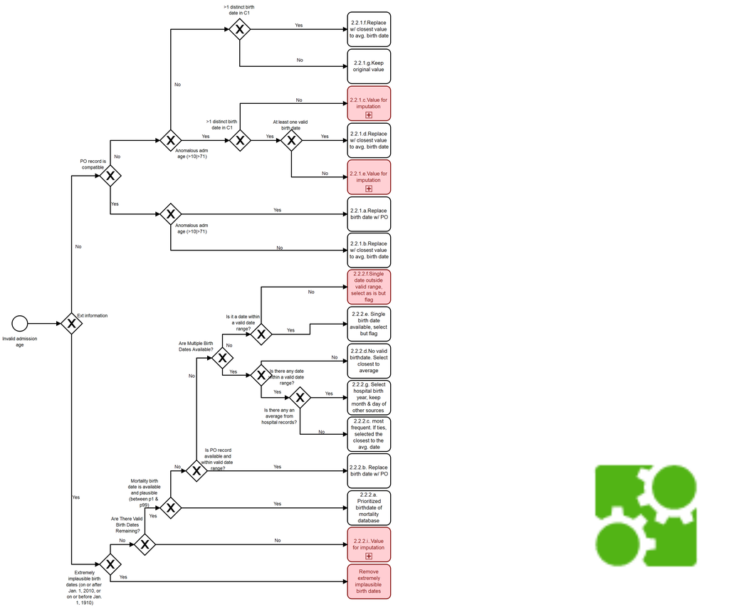

```
[1] "G:/Mi unidad/Alvacast/SISTRAT 2023/"
```

[interactive chart not shown]

Workflow for rule-based selection of valid birth dates

```r
#https://bergant.github.io/bpmn/
wdpath<-
paste0(gsub("/cons","",gsub("cons","",paste0(getwd(),"/cons"))))
envpath<- if(regmatches(wdpath, regexpr("[A-Za-z]+", wdpath))=="G"){"G:/Mi unidad/Alvacast/SISTRAT 2023/"}else{"E:/Mi unidad/Alvacast/SISTRAT 2023/"}
envpath

unlink(paste0(wdpath,"cons/_figs/diagram_invalid_adm_ages_files"), recursive = TRUE)

# Construir el widget
w <- bpmn::bpmn(
  paste0(wdpath, "cons/_input/diagram_invalid_adm_ages.bpmn"),
  width = "100%", height = "800px"
)

# Adjuntar dependencia svg-pan-zoom desde CDN
dep <- htmltools::htmlDependency(
  name    = "svg-pan-zoom",
  version = "3.6.1",
  src     = c(href = "https://unpkg.com/svg-pan-zoom@3.6.1/dist"),
  script  = "svg-pan-zoom.min.js"
)
w <- htmltools::attachDependencies(w, dep)

# Inicializar pan/zoom
w <- htmlwidgets::onRender(w, "
function(el,x){
  function init(){
    var svg = el.querySelector('svg');
    if(!svg){ setTimeout(init, 50); return; }
    var panZoom = window.svgPanZoom(svg, {
      zoomEnabled: true,
      controlIconsEnabled: true,
      fit: true,
      center: true,
      minZoom: 0.3,
      maxZoom: 20
    });
    el.addEventListener('wheel', function(e){
      e.preventDefault();
      panZoom.zoomBy(e.deltaY > 0 ? 0.9 : 1.1);
    }, { passive: false });
  }
  init();
}
")
w

htmlwidgets::saveWidget(bpmn::bpmn(paste0(wdpath, "cons/_input/diagram_invalid_adm_ages.bpmn")), paste0(wdpath,"cons/_figs/diagram_invalid_adm_ages.html"))
webshot::webshot(paste0(wdpath,"cons/_figs/diagram_invalid_adm_ages.html"),paste0(wdpath,"cons/_figs/diagram_invalid_adm_ages.png"), vwidth = 300*1.2, vheight = 300,  zoom=10, expand=100)  # Prueba con diferentes coordenadas top, left, width, and height.
```

We started selecting values for those cases with no other external official information provided (`invalid_adm_ages_no_ext_data_long_w_po_and_c1_info`). We ensured that birth dates were corrected accurately by considering both the proximity to the average birth date and the presence of anomalies based on conditional checks. Records requiring further attention were clearly flagged for potential probabilistic imputation. Cases where only one anomalous birth date exists are flagged, and imputation is recommended. For instances with multiple dates, the one closest to the average was selected. Records containing only anomalous birth dates are flagged, with imputation recommended. Lastly, records with no anomalies either retained the original date or used the date closest to the mean.

```r
#https://chatgpt.com/share/6738f80f-cd6c-8010-a7d1-cc8a5669bfcd

invisible("Define average birth date, and percentiles 1 and 99")
avg_birth_date<-mean(SISTRAT23_c1_2010_2024_df_prev1d$birth_date,na.rm=T)
q1_birth_date <- as.Date(quantile(unclass(SISTRAT23_c1_2010_2024_df_prev1d$birth_date), 0.01, na.rm=T), origin = '1970-01-01')
q99_birth_date <- as.Date(quantile(unclass(SISTRAT23_c1_2010_2024_df_prev1d$birth_date), 0.99, na.rm=T), origin = '1970-01-01')
avg_birth_date; q1_birth_date; q99_birth_date
invisible("Define anomalous admission ages")
# [1] "1980-01-12"
#           1%
# "1951-02-17"
#          99%
# "2000-05-17"

invalid_adm_ages_no_ext_data_long_w_po_and_c1_info$min_adm_age_flag <- with(
  invalid_adm_ages_no_ext_data_long_w_po_and_c1_info,
  ifelse(min_adm_age > 71 | min_adm_age < 9, "anomalous", "")
)

cat("IQRs\n")
lubridate::time_length(interval(as.Date(quantile(unclass(SISTRAT23_c1_2010_2024_df_prev1d$birth_date),.25, na.rm=T) - 1.5*IQR(unclass(SISTRAT23_c1_2010_2024_df_prev1d$birth_date), na.rm=T)),as.Date("2022-01-01")), unit= "years")
lubridate::time_length(interval(as.Date(quantile(unclass(SISTRAT23_c1_2010_2024_df_prev1d$birth_date),.75, na.rm=T) + 1.5*IQR(unclass(SISTRAT23_c1_2010_2024_df_prev1d$birth_date), na.rm=T)),as.Date("2022-01-01")), unit= "years")

# [1] 72.1137
# [1] 10.59959 # AUG 2025: 9.461644

invisible("=======================================================")

invisible("Function to process cases with no ext. info.")
process_group_noextinfo <- function(df_group) {
  # Initialize 'sel_birth_date' & 'FLAG' columns
  df_group$sel_birth_date <- NA
  df_group$FLAG <- NA

  # Extract unique values & first if there is more than one
  avg_birth_date_po <- unique(df_group$avg_birth_date_po)[1]
  min_adm_age_flag <- unique(df_group$min_adm_age_flag)
  ndis <- unique(df_group$ndis_birth_date)

  # Obtain unique birth dates in the group
  birth_dates <- unique(df_group$birth_date)

  # Condition 1: Have a PO birth date & actual is anomalous
  if (!is.na(avg_birth_date_po) & min_adm_age_flag == "anomalous") {
    df_group$sel_birth_date <- avg_birth_date_po
    df_group$FLAG <- '2.2.1.a.Anomalous adm age, have a PO birth date, replace birth date'
  }

  # Condition 2: Have a PO birth date but is not anomalous
  else if (!is.na(avg_birth_date_po) & min_adm_age_flag == "") {
    # Include avg_birth_date_po among candidate values
    candidates <- c(birth_dates, avg_birth_date_po)
    candidates <- candidates[!is.na(candidates)]  # Eliminamos NAs
    # Calculate absolute difference with the average birth date
    diffs <- abs(as.numeric(candidates) - as.numeric(avg_birth_date))
    # Select the closest birth date to the average
    sel_date <- candidates[which.min(diffs)]
    df_group$sel_birth_date <- sel_date
    df_group$FLAG <- '2.2.1.b. Not anomalous adm age, have a PO birth date, replace birth date with the closest birth date to the average birth date'
  }

  # Condition 3: No PO birth date and anomalous
  else if (is.na(avg_birth_date_po) & min_adm_age_flag == "anomalous") {
    # If ndis == 1
    if (ndis == 1) {
      df_group$FLAG <- '2.2.1.c.Only 1 anomalous birth date, imputation is recommended'
      df_group$sel_birth_date <- NA
    }
    # IF ndis > 1 (more than one birth date in C1 database)
    else if (ndis > 1) {
      # Check if any date is between percentiles 1 & 99
      valid_dates <- birth_dates[birth_dates >= q1_birth_date & birth_dates <= q99_birth_date]
      if (length(valid_dates) > 0) {
        # Select the closest date to the average
        diffs <- abs(as.numeric(valid_dates) - as.numeric(avg_birth_date))
        sel_date <- valid_dates[which.min(diffs)]
        df_group$sel_birth_date <- sel_date
        df_group$FLAG <- '2.2.1.d.>1 distinct date, selected birth date w/ values closer to average birth date'
      } else {
        df_group$FLAG <- '2.2.1.e.Only anomalous birth dates, imputation is recommended'
        df_group$sel_birth_date <- NA
      }
    }
  }

  # Condition 4: No PO birth date & not anomalous
  else if (is.na(avg_birth_date_po) & min_adm_age_flag == "") {
    # If ndis > 1
    if (ndis > 1) {
      # Select the closest date to the mean
      diffs <- abs(as.numeric(birth_dates) - as.numeric(avg_birth_date))
      sel_date <- birth_dates[which.min(diffs)]
      df_group$sel_birth_date <- sel_date
      df_group$FLAG <- '2.2.1.f.No anomalous birth dates, used the closest to the mean'
    }
    # IF ndis == 1 (only one birth date)
    else if (ndis == 1) {
      df_group$sel_birth_date <- birth_dates[1]  # Only one birth date
      df_group$FLAG <- '2.2.1.g.Only one birth date, no anomalous values, kept the original birth date'
    }
  }

  return(df_group)
}

#_#_#_#_#_#_#_#_#_#_#_#_#_#_#_#_#_#_#_#_#_#_#_#_#_#_#_#_#_#_#_#_#_#_#_#_#_#_#_#_#_#_#_#_#_#_#_#_#_#_
#_#_#_#_#_#_#_#_#_#_#_#_#_#_#_#_#_#_#_#_#_#_#_#_#_#_#_#_#_#_#_#_#_#_#_#_#_#_#_#_#_#_#_#_#_#_#_#_#_#_
# Apply the function to every hash_key
proc_invalid_adm_ages_no_ext_data_long_w_po_and_c1_info <-
invalid_adm_ages_no_ext_data_long_w_po_and_c1_info|>
  dplyr::group_split(hash_key)|>
  purrr::map_dfr(~ process_group_noextinfo(.x))

#_#_#_#_#_#_#_#_#_#_#_#_#_#_#_#_#_#_#_#_#_#_#_#_#_#_#_#_#_#_#_#_#_#_#_#_#_#_#_#_#_#_#_#_#_#_#_#_#_#_
invisible("h and g do not have values")
proc_invalid_adm_ages_no_ext_data_long_w_po_and_c1_info |>
  dplyr::filter(grepl("2\\.2\\.1\\.a", FLAG)) |>
  (\(df) {
    message("2.2.1.a. Anomalous adm age, have a PO birth date, replace birth date")
    message(paste0("2.2.1.a, Entries: ", nrow(df)))
    message(paste0("2.2.1.a, RUNs: ", nrow(tidytable::distinct(df, hash_key))))
  })()
```

2.2.1.a. Anomalous adm age, have a PO birth date, replace birth date

2.2.1.a, Entries: 61

2.2.1.a, RUNs: 61

```r
proc_invalid_adm_ages_no_ext_data_long_w_po_and_c1_info |>
  dplyr::filter(grepl("2\\.2\\.1\\.b", FLAG)) |>
  (\(df) {
    message("2.2.1.b. Not anomalous adm age, have a PO birth date, replace with closest to average")
    message(paste0("2.2.1.b, Entries: ", nrow(df)))
    message(paste0("2.2.1.b, RUNs: ", nrow(tidytable::distinct(df, hash_key))))
  })()
```

2.2.1.b. Not anomalous adm age, have a PO birth date, replace with closest to average

2.2.1.b, Entries: 11

2.2.1.b, RUNs: 11

```r
proc_invalid_adm_ages_no_ext_data_long_w_po_and_c1_info |>
  dplyr::filter(grepl("2\\.2\\.1\\.c", FLAG)) |>
  (\(df) {
    message("2.2.1.c. Only 1 anomalous birth date, imputation is recommended")
    message(paste0("2.2.1.c, Entries: ", nrow(df)))
    message(paste0("2.2.1.c, RUNs: ", nrow(tidytable::distinct(df, hash_key))))
  })()
```

2.2.1.c. Only 1 anomalous birth date, imputation is recommended

2.2.1.c, Entries: 10

2.2.1.c, RUNs: 10

```r
proc_invalid_adm_ages_no_ext_data_long_w_po_and_c1_info |>
  dplyr::filter(grepl("2\\.2\\.1\\.d", FLAG)) |>
  (\(df) {
    message("2.2.1.d. >1 distinct date, selected birth date closer to average")
    message(paste0("2.2.1.d, Entries: ", nrow(df)))
    message(paste0("2.2.1.d, RUNs: ", nrow(tidytable::distinct(df, hash_key))))
  })()
```

2.2.1.d. >1 distinct date, selected birth date closer to average

2.2.1.d, Entries: 0

2.2.1.d, RUNs: 0

```r
proc_invalid_adm_ages_no_ext_data_long_w_po_and_c1_info |>
  dplyr::filter(grepl("2\\.2\\.1\\.e", FLAG)) |>
  (\(df) {
    message("2.2.1.e. Only anomalous birth dates, imputation is recommended")
    message(paste0("2.2.1.e, Entries: ", nrow(df)))
    message(paste0("2.2.1.e, RUNs: ", nrow(tidytable::distinct(df, hash_key))))
  })()
```

2.2.1.e. Only anomalous birth dates, imputation is recommended

2.2.1.e, Entries: 0

2.2.1.e, RUNs: 0

```r
proc_invalid_adm_ages_no_ext_data_long_w_po_and_c1_info |>
  dplyr::filter(grepl("2\\.2\\.1\\.f", FLAG)) |>
  (\(df) {
    message("2.2.1.f. No anomalous birth dates, used the closest to the mean")
    message(paste0("2.2.1.f, Entries: ", nrow(df)))
    message(paste0("2.2.1.f, RUNs: ", nrow(tidytable::distinct(df, hash_key))))
  })()
```

2.2.1.f. No anomalous birth dates, used the closest to the mean

2.2.1.f, Entries: 0

2.2.1.f, RUNs: 0

```r
proc_invalid_adm_ages_no_ext_data_long_w_po_and_c1_info |>
  dplyr::filter(grepl("2\\.2\\.1\\.g", FLAG)) |>
  (\(df) {
    message("2.2.1.g. Only one birth date, no anomalous values, kept the original")
    message(paste0("2.2.1.g, Entries: ", nrow(df)))
    message(paste0("2.2.1.g, RUNs: ", nrow(tidytable::distinct(df, hash_key))))
  })()
```

2.2.1.g. Only one birth date, no anomalous values, kept the original

2.2.1.g, Entries: 1

2.2.1.g, RUNs: 1

```r
# 2.2.1.a.Anomalous adm age, have a PO birth date, replace birth date
# 2.2.1.b. Not anomalous adm age, have a PO birth date, replace birth date with the closest birth date to the average birth date
# 2.2.1.c.Only 1 anomalous birth date, imputation is recommended
# 2.2.1.d.>1 distinct date, selected birth date w/ values closer to average birth date
# 2.2.1.e.Only anomalous birth dates, imputation is recommended
# 2.2.1.f.No anomalous birth dates, used the closest to the mean
# 2.2.1.g.Only one birth date, no anomalous values, kept the original birth date
# 2.2.1.a, Entries: 12 #61
# 2.2.1.a, RUNs: 12 $61
# 2.2.1.b, Entries: 2  #11
# 2.2.1.b, RUNs: 2 #11
# 2.2.1.c, Entries: 58 #10
# 2.2.1.c, RUNs: 58 #10
# 2.2.1.d, Entries: 64 #0
# 2.2.1.d, RUNs: 31 #0
# 2.2.1.e, Entries: 0 #0
# 2.2.1.e, RUNs: 0 #0
# 2.2.1.f, Entries: 0 #0
# 2.2.1.f, RUNs: 0 #0
# 2.2.1.g, Entries: 10 #1
# 2.2.1.g, RUNs: 10 #1
#8e3591364bcc3eb5630f2db00e6f15bd57c07604e7c60f6086151f81f38b3727, no lo codificó bien, debiese haber sido d.

cat(paste0("Warning, Unknown or uninitialised column: `min_adm_age_flag`: ",174,"\n"))
#or some groups passed into process_group_noextinfo(), the column min_adm_age_flag doesn’t exist (or it exists in the big data frame but is dropped upstream), and you access it with df_group$min_adm_age_flag. In a tibble, using $ on a missing column triggers exactly that warning.
```

```
[1] "1980-10-13"
          1%
"1951-08-10"
         99%
"2002-01-23"
IQRs
[1] 72.12055
[1] 9.457534
Warning, Unknown or uninitialised column: `min_adm_age_flag`: 174
```

```r
#https://chatgpt.com/c/6737c7a6-4318-8010-98f3-512061b56100

q1_birth_date <- as.Date(quantile(unclass(SISTRAT23_c1_2010_2024_df_prev1d$birth_date), 0.01, na.rm=T), origin = '1970-01-01')
q99_birth_date <- as.Date(quantile(unclass(SISTRAT23_c1_2010_2024_df_prev1d$birth_date), 0.99, na.rm=T), origin = '1970-01-01')

invisible("Define anomalous admission ages")
invalid_adm_ages_long_w_po_and_c1_info$min_adm_age_flag <- with(
  invalid_adm_ages_long_w_po_and_c1_info,
  ifelse(min_adm_age > 71 | min_adm_age < 9, "anomalous", "")
)

invisible("=======================================================")
invisible("")

# Function to process each group
process_inv_birthdates_w_info <- function(df_group) {
  # Initialize 'sel_birth_date', 'FLAG', and 'obs'
  df_group <- df_group |>
    mutate(sel_birth_date = as.Date(NA),
           FLAG = NA,
           obs = NA) |>
  # AGS: eliminate incorrect dates
    mutate(
  birth_date = case_when(
    birth_date >= as.Date("2010-01-01") ~ as.Date(NA),
    birth_date <= as.Date("1910-01-01") ~ as.Date(NA),
    TRUE ~ birth_date
  )
)
  # Extract unique values needed
  m_birthdate <- unique(df_group$birth_date[df_group$source_birth == "m_birthdate"])
  #AUG 2025, added the alternative date just in case
  avg_birth_date_po <- unique(c(df_group$avg_birth_date_po))
  #sum_eq_adm <- unique(df_group$sum_eq_adm)
  min_adm_age_flag <- unique(df_group$min_adm_age_flag)
  ndis_birth_date <- unique(df_group$ndis_birth_date)
  birth_dates <- unique(df_group$birth_date)

  # Remove NA values from birth_dates
  birth_dates <- birth_dates[!is.na(birth_dates)]
  # Rule 1: Prioritize 'm_birthdate' if available (obs_label = "2.2.2.a")
  if (length(m_birthdate) > 0) {
    df_group <- df_group %>%
      mutate(sel_birth_date = m_birthdate,
             obs = "2.2.2.a. Prioritized birthdate of mortality database")
    return(df_group)
  }
  # Rule 2: Use 'avg_birth_date_po' if within valid range (obs_label = "2.2.2.b")
  if (is.na(df_group$sel_birth_date[1]) & !is.na(avg_birth_date_po)) {
    # Check if 'avg_birth_date_po' is within valid dates
    if (avg_birth_date_po >= q1_birth_date & avg_birth_date_po <= q99_birth_date) {
      df_group <- df_group %>%
        mutate(sel_birth_date = avg_birth_date_po,
               obs = "2.2.2.b. Used PO date if within percentiles 1 and 99")
      return(df_group)
    }
  }
  # Rule 3: Analyze multiple birth dates (obs_label = "2.2.2.c")
  if (length(birth_dates) > 1) {
    # Filter birth_dates within valid range
    valid_birth_dates <- birth_dates[birth_dates >= q1_birth_date & birth_dates <= q99_birth_date]

    if (length(valid_birth_dates) > 0) {
      # Check if any of the valid_birth_dates come from 'hosp_avg' source
      hosp_avg_dates <- df_group$birth_date[df_group$source_birth == "hosp_avg"]
      valid_hosp_avg_dates <- intersect(valid_birth_dates, hosp_avg_dates)
        # Use day and month from other sources
      other_b_dates <- setdiff(valid_birth_dates, hosp_avg_dates)
      # Proceed to select the most frequent date
      # Select the most frequent date among valid_birth_dates
      other_b_dates_mfv <- as.numeric(names(sort(-table(other_b_dates)))[1])
      if (length(valid_hosp_avg_dates)>0 & length(other_b_dates)>0){
        # Rule 7: Use 'hosp_avg' date for year information (obs_label = "2.2.2.g")
        avg_hosp_date <- unique(valid_hosp_avg_dates)
        # print(paste0("avg hosp date:",as.Date(avg_hosp_date[1])))
        avg_hosp_year <- as.integer(format(as.Date(avg_hosp_date[1]), "%Y"))
        # print(paste0("avg hosp year:",avg_hosp_year))
        # print(paste0("other dates,mfv:",as.Date.numeric(other_b_dates_mfv)))
        day_month <- format(as.Date.numeric(other_b_dates_mfv), "%m-%d")
        new_birth_date_str <- paste(avg_hosp_year, day_month, sep = "-")
        new_birth_date <- as.Date(new_birth_date_str, format = "%Y-%m-%d")
        # # Check if new_birth_date is within valid range
        # if (!is.na(new_birth_date) && new_birth_date >= q1_birth_date & new_birth_date <= q99_birth_date) {
          df_group <- df_group %>%
            mutate(sel_birth_date = new_birth_date,
                   obs = "2.2.2.g. Select hospital birth year, keep month & day of other sources")
          return(df_group)
        # }
      }
      # Proceed to select the most frequent date
      # Select the most frequent date among valid_birth_dates
      birth_date_counts <- table(valid_birth_dates)
      max_count <- max(birth_date_counts)
      most_freq_dates <- as.Date(names(birth_date_counts[birth_date_counts == max_count]))

      # If there's a tie, select the date closest to average birth date
      if (length(most_freq_dates) > 1) {
        diffs <- abs(as.numeric(most_freq_dates) - as.numeric(avg_birth_date))
        sel_date <- most_freq_dates[which.min(diffs)]
      } else {
        sel_date <- most_freq_dates
      }

      df_group <- df_group %>%
        mutate(sel_birth_date = sel_date,
               obs = "2.2.2.c.Multiple birth dates. Chose the most frequent. If ties, selected the closest to the average date")
      return(df_group)
    } else {
      # No valid birth dates within the percentile range
      # Proceed to select date closest to average birth date from all birth_dates
      diffs <- abs(as.numeric(birth_dates) - as.numeric(avg_birth_date))
      sel_date <- birth_dates[which.min(diffs)]
      df_group <- df_group %>%
        mutate(sel_birth_date = sel_date,
               FLAG = 'Selected date closest to average birth date',
               obs = "2.2.2.d.No valid birthdate. Select closest to average")  # Rule 4 applied here
      return(df_group)
    }
  }
  # Rule 5: If only one birth date is available (obs_label = "2.2.2.e")
  if (length(birth_dates) == 1) {
    # Check if it's within valid range
    if (birth_dates >= q1_birth_date & birth_dates <= q99_birth_date) {
      df_group <- df_group %>%
        mutate(sel_birth_date = birth_dates,
               obs = "2.2.2.e. Single birth date available, selected")
      return(df_group)
    } else {
      # Birth date is outside valid range, select it but flag it
      sel_date <- birth_dates
      df_group <- df_group %>%
        mutate(sel_birth_date = sel_date,
               FLAG = 'Single date outside valid range, selected as is',
               obs = "2.2.2.f.Single date outside valid range, selected as is")  # Rule 6 applied here
      return(df_group)
    }
  }
  # Rule 8: Select date closest to average birth date (obs_label = "2.2.2.h")
  if (length(birth_dates) > 0) {
    diffs <- abs(as.numeric(birth_dates) - as.numeric(avg_birth_date))
    sel_date <- birth_dates[which.min(diffs)]
    df_group <- df_group %>%
      mutate(sel_birth_date = sel_date,
             FLAG = 'Selected date closest to average birth date',
             obs = "2.2.2.h.Selected date closest to average birth date")
    return(df_group)
  }
  # Rule 9: Flag records with unresolvable inconsistencies (obs_label = "2.2.2.i")
  df_group <- df_group %>%
    mutate(FLAG = 'Unresolvable inconsistencies',
           obs = "2.2.2.i.Unresolvable inconsistencies or extremely implausible birth dates")

  return(df_group)
}

#_#_#_#_#_#_#_#_#_#_#_#_#_#_#_#_#_#_#_#_#_#_#_#_#_#_#_#_#_#_#_#_#_#_#_#_#_#_#_#_#_#_#_#_#_#_#_#_#_#_
#_#_#_#_#_#_#_#_#_#_#_#_#_#_#_#_#_#_#_#_#_#_#_#_#_#_#_#_#_#_#_#_#_#_#_#_#_#_#_#_#_#_#_#_#_#_#_#_#_#_
process_safe <- purrr::safely(process_inv_birthdates_w_info)

# Apply the function to each group and combine the results
proc_invalid_adm_ages_long_w_po_and_c1_info <- invalid_adm_ages_long_w_po_and_c1_info|>
  dplyr::group_split(hash_key)|>
  #purrr::map_dfr(~ process_safe(.x)$result)
  purrr::map_dfr(process_inv_birthdates_w_info)

#AUG 2025
#SISTRAT23_c1_2010_2024_df_prev1d |> filter(hash_key=="f23b9b3b7cbaf2510fd998d6324e08e46c312cd127fffe78fbaa24c6fc5aff5b") |> glimpse()
#NAs result from invalid dates, so they might not be replaceable

cat(paste0("HASHs w/ C1 missing birth date: ", proc_invalid_adm_ages_long_w_po_and_c1_info|> filter(is.na(birth_date))|> nrow(),"\n")) # 145 AUG 2025
cat(paste0("Warning, Unknown or uninitialised column: `min_adm_age_flag`: ",174,"\n"))

#_#_#_#_#_#_#_#_#_#_#_#_#_#_#_#_#_#_#_#_#_#_#_#_#_#_#_#_#_#_#_#_#_#_#_#_#_#_#_#_#_#_#_#_#_#_#_#_#_#_
invisible("h and g do not have values")
cases <- c(
  "2.2.2.a" = "Prioritized birthdate of mortality database",
  "2.2.2.b" = "Used PO date if within percentiles 1 and 99",
  "2.2.2.c" = "Multiple birth dates; chose most frequent; ties -> closest to average",
  "2.2.2.d" = "No valid birthdate; selected closest to average",
  "2.2.2.e" = "Single birth date available; selected",
  "2.2.2.f" = "Single date outside valid range; selected as is",
  "2.2.2.g" = "Get birth year from hospital avg; keep month/day from other sources",
  "2.2.2.h" = "Selected date closest to average birth date",
  "2.2.2.i" = "Unresolvable inconsistencies or extremely implausible birth dates"
)

purrr::iwalk(cases, function(desc, code){
  pat <- gsub("\\.", "\\\\.", code)
  df <- proc_invalid_adm_ages_long_w_po_and_c1_info |>
    dplyr::filter(grepl(pat, obs))
  message(code, ". ", desc)
  message(code, ", Entries: ", nrow(df))
  message(code, ", RUNs: ", dplyr::n_distinct(df$hash_key))
})
```

2.2.2.a. Prioritized birthdate of mortality database